[figure not shown]

# 这

# T H E

# 创意工厂

# IDEA FACTORY

# 这

# T H E

# 创意 工厂

# IDEA FACTORY

# 在麻省理工学院学习思考

# LEARNING TO THINK AT MIT

[figure not shown]

胡椒白

PEPPER WHITE

[figure not shown]

谨以此书献给我的母亲和我的父亲。

This book is dedicated to my mother and to the memory of my father.

# 致谢

# Acknowledgments

在本书首次出版的过程中，许多人帮助和鼓励了我。其中包括约翰·马蒂尔 (John Mattill)、利兹·穆瑟 (Liz Muther)、琳达·西蒙 (Linda Simon)、阿克利鲁·格布鲁沃尔德 (Aklilu Gebrewold)、卡尔·勃兰特 (Carl Brandt)、比尔·纽林 (Bill Newlin)、比尔·伊贾姆斯 (Bill Ijams)，以及普特南出版社的匿名编辑，他在一封拒绝信中告诉我，如果我想出版作品，就必须找一位文学经纪人。这本书。

Many people helped and encouraged me along the way to the first publication of this book. Among them were John Mattill, Liz Muther, Linda Simon, Aklilu Gebrewold, Carl Brandt, Bill Newlin, Bill Ijams, and the anonymous editor at Putnam who, in a rejection letter, told me to find a literary agent if I ever wanted to publish this book.

还要感谢麻省理工学院的教授和朋友们审阅了原版的部分内容；特别感谢 Elias P. Gyftopoulos 教授允许使用他的课程笔记和教科书“热力学：基础与应用”（Macmillan，1991）中的材料，并感谢他的更正。

Thanks also to the MIT professors and friends who reviewed sections of the original version; special thanks to Professor Elias P. Gyftopoulos for permission to use material from his course notes and textbook "Thermodynamics: Foundations and Applications" (Macmillan, 1991), and for his corrections.

非常感谢我的文学经纪人马拉加·巴尔迪。感谢已故的亚历克西娅·多尔辛斯基（Alexia Dorszynski），我的第一位编辑，她告诉我不要审查自己，也没有审查我。

Many thanks to Malaga Baldi, my literary agent. And thanks to the late Alexia Dorszynski, my first editor, who told me not to censor myself and who did not censor me.

感谢麻省理工学院出版社的主编拉里·科恩 (Larry Cohen)，他是我在 1984 年冬天第一个向我提交原始手稿的人。他当时的鼓励帮助我坚持了下来，我很感激现在有机会将这本书重新印刷。

Thanks to Larry Cohen, Editor-in-Chief at The MIT Press, who in the winter of 1984 was the first person to whom I submitted a primitive manuscript. His encouragement at that time helped me persist, and I appreciate the present opportunity to return the book to print.

最后，衷心感谢我的妻子伊丽莎白·罗斯·怀特（Elizabeth Ross White），她的审稿意见极大地改进了本版的新材料。

Finally, warm thanks to my wife, Elizabeth Ross White, whose review comments greatly improved the new material in this edition.

# 内容

# C O N T E N T S

麻省理工学院新闻版序言xiii

Preface to the MIT Press Edition xiii

序言1

Prologue 1

1. 登录5

1. Logging On 5

2. Class 17

3.休息30

3. Break 30

4.期中考试45

4. Midterm 45

5. 资金60

5. Funding 60

6. 决赛69

6. Finals 69

7. 公会78

7. The Guild 78

8.监工93

8. The Taskmasters 93

9. 春天108

9. Spring 108

10.控制119

10. In Control 119

11.西格玛德尔塔134

11. Sigma Delta 134

12.二七十145

12. Two Seventy 145

13.自杀是无痛的吗？163

13. Is Suicide Painless? 163

14.永动机174

14. Perpetual Motion 174

15.Hackito Ergo Sum 191

15. Hackito Ergo Sum 191

16.闪电爸爸203

16. Papa Flash 203

17.六人欢乐215

17. The Joy of Six 215

18.结果230

18. Results 230

19. 不，不是250

19. No It Isn't 250

20.质量控制260

20. Quality Control 260

21.继续教育277

21. Continuing Education 277

Chapter Notes 287

索引309

Index 309

难道我们不能弥合导致心灵内乱的鸿沟吗？双方极端分子都说，不！诗人和信仰者申明，只有通过人的精神，通过直觉的理解，他才能触及真实的现实。那些头脑更顽固的人会抛弃这种态度，认为这是无望的神秘主义、非理性和错误的。大多数男人无法决定任何一条道路，并试图过双重生活。与科学对话的海德与艺术、政治或宗教的杰基尔是不同的人。许多人认为这种分裂的效忠是不可避免的。……但这种二元性很难为任何令人满意的生活哲学提供坚实的基础。最好的情况是令人士气低落，最坏的情况是危险......

Can we not bridge the chasm which thus makes for civil strife within the mind? The extremists on both sides say, no! The poet and the man of faith affirm that only through man's spirit, through intuitive understanding, can he touch true reality. Those who have harder heads will toss this attitude aside as hopeless mysticism, irrational and false. Most men cannot decide on either course, and attempt to live a double life. The Hyde who holds discourse with science is a different man from the Jekyll of art or politics or religion. This divided allegiance is accepted as inevitable by many. ... But such duality can hardly offer a sound basis for any satisfying life philosophy. At best it is demoralizing, at worst, perilous....

-来自爱德华·W·辛诺特 (Edward W. Sinnott)，《科学与完整的人》，百年纪念演讲，耶鲁大学谢菲尔德科学学院，1947 年 10 月

-From Edward W. Sinnott, "Science and the Whole Man," centennial address, Sheffield Scientific School, Yale University, October 1947

# 麻省理工学院 新闻版序言

# Preface to the MIT Press Edition

“这本书还不够严厉。”——一位麻省理工学院的博士 他也是哈佛大学医学博士 (1999)

"The book wasn't harsh enough."-an MIT Ph.D. who is also a Harvard M.D. (1999)

“我读了这本书，这就是我想来麻省理工学院的原因。”——麻省理工学院课程的一名本科生，该课程将这本书作为必读内容（1996 年）

"I read it and that's why I wanted to come to MIT."-an undergraduate in an MIT course that included this book as required reading (1996)

“这本书在会议上不断出现。”——麻省理工学院的一位教授（1993）

"That book keeps coming up at meetings."-an MIT professor (1993)

“如果你想知道为什么我没有给麻省理工学院捐过钱，请阅读佩珀·怀特的书。”——麻省理工学院的一位富有的潜在捐助者，曾在那里读研究生（1992 年）

"If you want to see why I haven't given any money to MIT, read Pepper White's book."-a wealthy potential donor to MIT who went there for graduate school (1992)

“这是我读过的最悲伤的书。”——麻省理工学院合作社的一名销售员（1991 年）

"It's the saddest book I've ever read."-a sales clerk at the MIT Cooperative Society (1991)

我于 1984 年从麻省理工学院 (MIT) 获得硕士学位。本书第一版于 1991 年出版。麻省理工学院出版社于 2001 年出版。

I received my master's degree from the Massachusetts Institute of Technology (MIT) in 1984. The first edition of this book was published in 1991. The MIT Press edition appears in 2001.

萨尔曼·拉什迪说，书籍选择作者。我的父亲是一位科普作家，毕业于哈佛大学工程学专业，二战后为万尼瓦尔·布什工作。我的母亲是一位才华横溢的钢琴家，她教会了我音乐的精神层面。在约翰·霍普金斯大学，我接受了文科工程本科教育，包括艺术史、电影、外语以及个人发展的时间和机会。

Salman Rushdie said that books choose their authors. My father was a science writer, a Harvard-educated engineering major who after World War II worked for Vannevar Bush. My mother is a gifted pianist who has educated me about the spiritual dimension of music. At Johns Hopkins I had a liberal arts engineering undergraduate education, including art history, cinema, foreign languages, and time and opportunity to develop as a person.

一个笔误导致我通过“技术与政策”项目的后门被麻省理工学院录取。慷慨的举动使我获得了一份带薪研究助理职位，并成为我的论文导师，一位名副其实的天才。一次意外的缺席让我在本科生宿舍住了两年。Warren Rohsenow 教授要求我除了研究生课程外，还必须学习核心的本科机械工程课程。一只看不见的手带领我走过研究所的深处和高峰。

A clerical error led to my being accepted to MIT, through the back door of the "Technology and Policy" program. A generous act led me to a paid research assistantship and a veritable genius as my thesis advisor. An unplanned absence placed me for two years in an undergraduate dormitory. And Professor Warren Rohsenow required me to take the core undergraduate mechanical engineering curriculum in addition to my graduate courses. An invisible hand led me through the depths and heights of the Institute.

1988 年我父亲去世后不久，我在他的个人文件中发现了前一页中爱德华·W·辛诺特 (Edward W. Sinnott) 的引文，以及该地址的其他摘录。我把它带回家了。一年后，当我试图了解这本书的内容时，我掸掉泛黄的洋葱皮纸复写本上的灰尘，感到浑身起鸡皮疙瘩。这是我父亲送给我的礼物。理性与表现主义。辩证唯物主义——前苏联的国家哲学——和宗教。正题和反题。稗子和麦子。

Shortly after my father passed away in 1988, I found among his personal papers the Edward W. Sinnott quotation from a prior page, as well as other excerpts of the address. I took it home with me. When attempting a year later to discover what this book was to be about I dusted off the yellowing onion-skin-papered carbon copy and felt goose bumps. It was a gift from my father. The rational and the expressionistic. Dialectical materialism-the state philosophy of the former Soviet Union-and religion. Thesis and antithesis. The tares and the wheat.

在第一版出版十年后，再看这本书，我认为它回答了三个问题，其中第一个问题是，去麻省理工学院到底是什么样的？

Looking at the book ten years after its first edition, I see it as answering three questions, the first of which is, What is it really like to go to MIT?

第二，学会思考是什么意思？我遇到的第一位教授告诉我，我在那里学到了什么并不重要，但麻省理工学院会教我“如何思考”。日积月累形成工程师的小步骤是什么？工程师如何学习解决问题？在此过程中他或她如何维持人际关系和友谊？

Second, What does it mean to learn to think? The first professor I met told me that it didn't really matter what I learned there, but that MIT would teach me "how to think." What are the small steps that cumulatively form an engineer? How does an engineer learn to solve problems? How does he or she maintain relationships and friendships during the process?

最后，机械思维的局限性是什么？它会导致孤立、孤独、倦怠和不充实的生活吗？它能为宗教、励志、精神留下空间吗？

Finally, What are the limits of mechanistic thinking? Does it lead to isolation, loneliness, burnout, and an unfulfilling life? Can it leave room for the religious, the inspirational, the spiritual?

第三个问题在过去的半个世纪里得到了广泛的讨论。辛诺特演讲几年后，CP斯诺在剑桥大学发表了题为“两种文化”的演讲。20世纪50年代，当麻省理工学院开始努力架起两种文化的桥梁时，据报道阿德莱·史蒂文森曾表示，麻省理工学院试图将科学家人性化，而哈佛大学则试图将人文主义者西蒙化。（对于年轻的读者，我赶紧解释一下“Simonize”是一项清洁和抛光汽车的服务。）就在 2000 年 10 月 21 日，《波士顿环球报》头版刊登了一篇题为“将技术人员转变为人文主义者”的文章，副标题为“学校塑造了整个工程师。”

This third question has been much discussed in the last halfcentury. Several years after the Sinnott address, C. P. Snow delivered a lecture entitled "The Two Cultures" at the University of Cambridge. In the 1950s, when MIT was embarking on an early effort to bridge the two cultures, Adlai Stevenson is reported to have said that MIT was trying to humanize the scientists, while Harvard was trying to Simonize the humanists. (For younger readers I hasten to explain that "Simonize" was a service that cleaned and polished cars.) As recently as October 21, 2000, the Boston Globe had a front page article entitled "Turning techs into humanists," with the subhead "Schools shaping the whole engineer."

1981 年至 1984 年间，我在麻省理工学院工作。1984 年春天，我每周安排与《技术评论》前编辑约翰·马蒂尔 (John Mattill) 会面，撰写了本书的初稿，当时大部分经历仍记忆犹新。1989 年夏天，它与达顿签订了合同，并于 1991 年秋天首次出版。

I was at MIT between 1981 and 1984. I wrote a first draft of the book by scheduling weekly meetings with John Mattill, former editor of Technology Review, during the spring of 1984, while much of the experience was still fresh in my memory. In the summer of 1989 it went under contract with Dutton, and it was first published in the fall of 1991.

这些事件发生在近 20 年前，但每当我在报纸上读到一篇有关麻省理工学院的文章时，我都会对自己说“那在我的书中”。我遇到并写下了酗酒、新生宿舍空间不足、女性待遇不佳、自杀等问题。该研究所已尝试纠正这些问题。它的一些努力可能已经取得了成功。

The events occurred nearly 20 years ago, but whenever I read an article in the newspaper about MIT, I say to myself "that's in my book." I encountered and wrote about binge drinking, the lack of sufficient dorm space for freshmen, the poor treatment of women, suicide. The Institute has tried to correct these problems. And it may have been successful in some of its efforts.

1996 年春天，当我对麻省理工学院的一群本科生进行演讲时，他们中的许多人表示，他们认为这段经历并不像我在书中描述的那么艰难。这可能意味着该研究所因这本书而发生了一些变化。

When I gave a talk to a class of MIT undergrads in the spring of 1996, many of them said that they didn't think the experience was as hard as I had described in the book. Which may mean that the Institute has changed somewhat because of the book.

但正如本书的一位人物所说，“麻省理工学院是我必须杀死的一条龙。” 麻省理工学院数百英亩的校园里聚集着世界上一万名最聪明、最勤奋的人，他们由 1000 名更聪明的教授驱动。使研究所成为一个更友善、更温和的地方的敏感而柔软的东西必然总是让位于发明、发现和成为高技能的真正业务。

But as one of this book's characters says, "MIT is a dragon I have to slay." Ten thousand of the smartest, hardest-working people in the world are placed together within the several hundred acres of the MIT campus, and they are driven by 1,000 even smarter professors. The touchy-feely soft stuff of making the Institute a kinder gentler place will of necessity always take a back seat to the real business of inventing, discovering, and becoming highly skilled.

我在麻省理工学院失去了一位自杀的朋友。当我的第一个想法是死亡的流体力学时，我嘲笑对此类灾难的过度技术态度。然而，麻省理工学院的创新杂志写道，“对这些数字（最近的自杀数据）进行公正的统计分析”，你会发现这只是一种随机波动，就像棒球击球手的低迷或连胜一样。告诉父母、兄弟、姐妹、男朋友、女朋友、丈夫、妻子、室友、室友。我在飞机上遇到的人类学家休·古斯特森（Hugh Gusterson）在俄克拉荷马城爆炸案发生当天就在劳伦斯·利弗莫尔国家实验室。他说，武器科学家们听到这个消息后，立即拿出计算器，忙着估算炸弹的爆炸能量。

I lost a friend to suicide at MIT. I mock the over-techie attitude toward such calamities, when my first thought is the fluid mechanics of the decease. Yet MIT's magazine of innovation writes, "take a fair, statistical look at these numbers [recent suicide data]" and you find that it's just a random fluctuation, like a baseball batter's slump or streak. Tell that to the parents, the brothers, the sisters, the boyfriends, the girlfriends, the husbands, the wives, the roommates, the hallmates. Hugh Gusterson, an anthropologist whom I met on an airplane and who was at Lawrence Livermore National Laboratory on the day of the Oklahoma City bombing, said that the weapons scientists, on hearing the news, immediately pulled out their calculators and busied themselves with estimating the explosive energy of the bomb.

这本书还有另一个主题：在失败中生存。该学院一万名学生中的许多人经常失败。本科生不及格，或者没有达到研究生院录取的成绩。研究生没有完成他或她的学位。一位新近获得博士学位的人。没有获得博士后或助理教授职位。助理教授不晋升。麻省理工学院和其他类似的地方必须维持他们的标准，但他们在这样做时如何才能更加人性化呢？

There is another theme of the book: surviving failure. Many of the Institute's ten thousand students fail on a regular basis. An undergraduate flunks out, or doesn't have the grades to be admitted to graduate school. A graduate student doesn't complete his or her degree. A newly minted Ph.D. doesn't get the postdoc or assistant professorship. The assistant professor is not promoted. MIT and other places like it have to maintain their standards, but how can they be more humane while doing that?

几年前，我遇到一个刚刚被数学研究生项目开除的孩子。他被压垮了；他根本没有学位。他和麻省理工学院的其他人可能会花很多时间浪费时间认为自己不够好，而塔夫茨大学可能会任命他们为院长。这些人的悲伤咨询在哪里？正如《完整的男人》中查理·克罗克被抛弃的妻子玛莎所说，“你变得隐形了。”

Several years ago I met a kid who had just been kicked out of the mathematics graduate program. He was crushed; he had no degree at all. He and others at MIT may spend a lot of their lives wasting time thinking they're just not good enough, when Tufts would probably make them deans. Where's the grief counseling for these people? As Martha, Charlie Croker's cast-off wife in A Man in Full says, "you become invisible."

如果你作为读者在麻省理工学院或类似的地方遇到危机，请考虑选择休假、转学到另一所学校、在杂货店工作一段时间等等。事情会变得更好。在约翰·霍普金斯大学第 20 次聚会期间，我与一位一年级的同学交谈，他在二年级、三年级和四年级时转学到了一所名气稍差的学校。我从来不知道那次转会的情况如何，但他现在正在享受美好的职业生涯。

If you the reader are in a crisis at MIT or a similar place, consider the option of taking time off, transferring to another school, working at a grocery store for a while, whatever. Things will get better. During my 20th reunion at Johns Hopkins, I spoke with a classmate from freshman year who transferred to a slightly less prestigious school for his sophomore, junior, and senior years. I've never found out what the circumstances of that transfer were, but he is now enjoying a wonderful career.

在冰暴期间未能登顶珠穆朗玛峰并不丢脸。

There is no shame in not summitting Mount Everest during an ice storm.

关于这本书本身的一些注释。它主要是非小说类作品，因为其中发生的大部分内容都是基于我作为麻省理工学院研究生的经历的最佳回忆。然而，我没有连接声音，也没有拍摄本文描述的所有位置的照片。因此，例如，在 Mikic 教授的椅子上成堆描述的期刊文章实际上可能是在 Rohsenow 教授的椅子上或其他人的椅子上。

A few notes about the book itself. It is primarily nonfiction, since most of what happens in it is based on my best recollections of experiences I had as a graduate student at MIT. However, I was not wired for sound and I did not take photographs of all the locations described herein. Thus for example the journal articles described in piles on Professor Mikic's chairs may have been, in fact, on Professor Rohsenow's chairs or on someone else's chairs.

麻省理工学院主要教授的名字被保留下来，既是为了对他们在我参加的讲座中所做的工作给予应有的认可，也是为了展示真实研究所中的真实人物。这些人物的对话或讲座材料通常包含在引号中。然而，这本书是在八年后写的，我现在的文字是基于我的记忆和/或当时做的笔记。如果我的记忆有问题，我深表歉意。那些使用真名的人都包含在本书的索引中。

Names of key MIT professors have been retained, both to give due credit to the work they presented in the lectures I attended, and to present real people in the real Institute. Dialogue or lecture material for these characters is often included in quotation marks. However, the book was written eight years after the fact, and the words I present are based on my memory and/or notes I took at the time. If my memory is at fault, I apologize. Those people whose real names are used are included in the book's index.

所有其他字符都是复合字符；名字和身体特征已被更改，并且这些角色的一些场景纯属虚构。然而，即使是虚构的场景也是基于真实的经历。

All other characters are composites; the names and physical characteristics have been changed, and a few of the scenes with these characters are purely fictitious. However, even the fictitious scenes are based on real experiences.

第 21 章是本版的新增内容。所有其他文本均与原始版本中的内容完全相同，但有一些更正。正文包括要解决的技术问题的一般意义以及我的解决方法；章节注释包括对技术材料的更多讨论。

Chapter 21 is new to this edition. All other text is exactly as it appeared in the original edition, with a few corrections. The main text includes the general sense of the technical problems to be solved and my approaches to them; the Chapter Notes include more discussion of the technical material.

当我看到一张 20 世纪 50 年代麻省理工学院的印刷品时，我想到了这本书的书名。景色是向北看的，经过 20 号楼和游泳池。背景是几栋红砖厂房。该印刷品的标题是“麻省理工学院和工厂”，由麻省理工学院的技术人员 Fred Roseberry 制作。“就是这样，”我想。麻省理工学院是一个工厂，一个创意工厂，一个创意工厂。

The book's title came to me when I saw a print of what MIT looked like in the 1950s. The view was looking north, past Building 20 and the swimming pool. In the background were several red brick factory buildings. The title of the print was "MIT and Factories," and it was produced by Fred Roseberry, an MIT technician. "That's it," I thought. MIT is a factory, a factory for ideas, an idea factory.

麻省理工学院的另类学生报纸《The Thistle》对本书的评论指出，“创意工厂”一词是在二战后创造的。这就是战后研究型大学应该成为的样子：一所附近有附属工业的大学。就像斯坦福大学和硅谷一样。或者麻省理工学院和肯德尔广场/128 号公路。

The review of this book in The Thistle, MIT's alternative student newspaper, noted that the term "idea factory" had been coined after World War II. It was what the postwar research university should be: a university with affiliated industry nearby. As in Stanford and Silicon Valley. Or MIT and Kendall Square/Route 128.

我很高兴我去了麻省理工学院。我在那里学到的严谨对我很有帮助。我花了一些时间与伟人为伴。麻省理工学院确实让我变得更聪明——这意味着任何人都可以通过学习思考而变得更聪明。

I'm glad I went to MIT. The rigor I learned there has served me well. I spent some time in the company of greatness. And MIT really did make me smarter-which means that anyone can become smarter, by learning to think.

对于每个去麻省理工学院的人来说，这是一个不同的地方。但不变量是存在的，我希望我在接下来的内容中发现了更多的不变量。

MIT is a different place for everyone who goes there. But there exist invariants, and I hope I've hit on more than a few in what follows.

# 序幕

# Prologue

比利时

Belgium

1981 年 5 月 9 日，星期六

Saturday, May 9, 1981

我口袋里的信已经湿透，皱巴巴的。我刚在想。

The letter was getting wet and wrinkled in my pocket. I was thinking.

离开斯蒂芬妮；去麻省理工学院。与斯蒂芬妮结婚；留在比利时。把海洋放在我和斯蒂芬妮之间；去麻省理工学院。稍后与斯蒂芬妮结婚；去麻省理工学院。

Leave Stephanie; go to MIT. Marry Stephanie; stay in Belgium. Put ocean between me and Stephanie; go to MIT. Marry Stephanie later; go to MIT.

“亲爱的怀特先生，”信中写道。“我们还没有收到您的消息，想知道我们是否应该在明年秋季的技术和政策计划小组中为您保留一个位置。请在您方便的时候尽早告知我们您的决定。”

"Dear Mr. White," the letter said. "We have not yet heard from you and would like to know if we should reserve a place for you in next fall's group for the Technology and Policy Program. Please let us know your decision at your earliest convenience."

这是他们的第一封信，但毫无意义。当你被录取时，你通常会收到一份包含住房和保险表格的大包裹。和资金。

This was their first letter and it didn't make sense. When you're accepted, you usually get a fat package with forms for housing and insurance. And funding.

今晚流行问题；周一致电麻省理工学院。

Pop question tonight; call MIT Monday.

1794 年，农民们受够了，在法国大革命期间，他们烧毁了修道院，除了烟囱和现在在树林中休眠的柱子。剥开后，烟囱会聚在一起，长满青苔的灰色石头向上慢慢变窄。

The peasants had had enough in 1794 and, during the French Revolution, they burned the abbey, all except the chimney and the columns now dormant amidst the trees. Peeled open, the chimney converged, the moss-covered gray stone narrowing gently upward.

它看起来就像一个竖立的风洞，就像冯卡门流体动力学研究所的风洞一样，这是布鲁塞尔以南的北约中心，过去八个月我一直在那里学习。我想知道是哪个和尚想出了通过收敛来改善烟囱通风的想法。

It looked like a wind-tunnel stood on its end, like the wind tunnels at the von Karman Institute for Fluid Dynamics, the NATO center just south of Brussels where I'd been studying for the previous eight months. I wondered which monk had come up with the idea that the chimney's draft would be improved by the convergence.

该修道院名为 Villers-la-Ville（位于热纳普以南 5 公里处 [滑铁卢以南 12 公里（布鲁塞尔以南 14 公里）]），其历史可追溯至十二世纪。导游经过烟囱，指着废弃食堂墙上的长方形石头通道。“那你认为这是做什么用的？”他用法语问道。

The abbey, named Villers-la-Ville (five kilometers south of Genappe [twelve kilometers south of Waterloo (fourteen kilometers south of Brussels)]), dated from the twelfth century. The guide passed the chimney and pointed to the rectangular stone passage in the wall of the ruined refectory. "And what," he asked in French, "do you think this was for?"

我回答说：“在烟雾进入烟囱之前用它来加热房间。”

I answered, "To heat the room with the smoke before it went to the chimney."

“啊，哦，呃，”他回答道，“先生一定是个工程师。”

"Ah, oui, eh," he replied, "Monsieur must be un ingenieur."

那天晚上，在布鲁塞尔路易斯广场附近的罗宾汉餐厅里，斯蒂芬妮坐在我对面。

Stephanie sat across from me that night in the Robin Hood Restaurant near Brussels's Place Louise.

“哦，”当我告诉她麻省理工学院录取了我时，她说，“我为你感到高兴。” 但她孩子般的棕色眼睛里的表情很悲伤，就像约翰·列侬去世时让我爱上她的悲伤一样。

"Oh," she said when I told her MIT had accepted me, "I'm very happy for you." But the look in her childlike brown eyes was sad, sad the same way that had made me fall in love with her when John Lennon died.

我无法伤她的心。

I couldn't break her heart.

“你是想让我结婚吗？” 我用法语问她。

"Is it that you would like me to marry?" I asked her in French.

她说：“那是‘你愿意嫁给我吗？’ “我帮助她学习英语；她帮助我学习法语。

She said, "That's 'Would you like to marry yourself with me?' " I helped her with her English; she helped me with my French.

“好吧。你愿意嫁给我吗？”

"OK. Would you like to marry yourself with me?"

“哎哟。”

"Oui."

噢，我的上帝，这是什么？

Oh mon Dieu, qu'est ce que j'ai fait?

5 月 11 日星期一

Monday, May 11

“请保持通话，”国际接线员说道。

"Hold the line please," the international operator said.

“你好，TPP，”这位女士欢快的声音从 4,000 英里外传来。

"Hello, TPP," said the woman's cheery voice from 4,000 miles away.

“呃，是的，”我说。“我是佩珀·怀特打来电话，询问你寄给我的那封信。”

"Uh, yeah," I said. "This is Pepper White calling about the letter you sent me."

“哦，天哪，”她说。“我不知道该怎么告诉你，但我们在这里犯了一个很大的错误。你的文件被错误地放入了延期录取文件柜中，而它本应该放在延期申请文件中。所以你是并没有真正承认。”

"Oh, gee," she said. "I don't know how to tell you this, but we made a big mistake here. Your file was put in the deferred acceptances filing cabinet by mistake, and it was supposed to be put in the deferred applications file. So you're not really admitted."

“也就是说我被拒绝了？”

"Does that mean I'm rejected?"

“不，这意味着你的文件不完整。你还需要两封推荐信。”

"No, it means your file isn't complete. You need two more letters of recommendation."

“我会看看我能做什么。”

"I'll see what I can do."

布鲁塞尔机场

Brussels Airport

1981 年 8 月 29 日

August 29, 1981

“我也爱你……一定要写……我会在圣诞节见到你……我会想念你的……”

"I love you, too.... Be sure to write.... I'll see you at Christmas. ... I'll miss you...."

同一天，科德角上方

Above Cape Cod, Same Day

飞行员开始下降太晚了。飞机急剧向下坠落。

The pilot started the descent too late. Steeply downward the plane dropped.

我想闯进驾驶舱，叫醒飞行员，然后说：“把操纵杆拉回来，你这个白痴；把操纵杆拉回来！”

I wanted to break into the cockpit, wake up the pilot, and say, "Pull back on the stick, you idiot; pull back on the stick!"

# 章节

# C H A P T E R

# 1

# 1

# 登录中

# Logging On

1981 年 8 月 31 日星期一

Monday, August 31, 1981

我从肯德尔广场地铁站爬上楼梯，绕过拐角进入艾姆斯街，开始感觉到我的胃里打着结。也许我最终应该留在比利时。街道的右侧是一座古老的灰色工厂，左侧是一座功能单调的红砖建筑。工厂的窗户半开着，压缩空气发出嘶嘶声，机器在金属上打孔的声音很大。

I climbed the stairs from the Kendall Square subway stop, rounded the corner onto Ames Street, and began to feel the knot being tied in my stomach. Maybe I should have stayed in Belgium after all. The street was bounded by an old gray factory on the right and a drably functional red brick building on the left. The factory windows were half-open, and compressed air hissed and machines loudly punched holes in metal.

我记得达罗莎夫人给我高中课上放映的麻省理工学院的物理电影中的休谟先生和艾德先生。她拒绝给我写一封去麻省理工学院上大学的推荐信，理由是那不是人类。等等，她说，去一所不错的文理学院读大学。努力工作，取得好成绩，如果你还想的话，就去麻省理工学院读研究生。

I remembered Mr. Hume and Mr. Ide in the physics movies from MIT that Mrs. DaRosa had shown my high school class. She had refused to write me a recommendation to MIT for college on the grounds that it wasn't human. Wait, she said, and go to a nice liberal arts school for college. Work hard, get good grades, and if you still want to, go to MIT for graduate school.

我去了约翰霍普金斯大学。在那里，我主修环境工程，同时学习艺术史、法国、意大利、美国电影。我参加了大旅行。前六个月是在米兰及其周边地区度过的，然后是在冯卡门研究所度过的一年。我感到休息了，仿佛我生命中广阔的篇章已经完成。现在是时候集中精力工作了。

I went to Johns Hopkins. There, as I majored in environmental engineering, I studied art history, French, Italian, American cinema. I went on the Grand Tour. First six months in Milan and the environs, then my year at the von Karman Institute. I felt rested, as if the broadening chapter of my life had been completed. Now it was time to focus and to work.

我在工厂后面右转，穿过它和那座不太单调的米色混凝土和玻璃建筑之间。更远的地方是包豪斯风格的游泳池和二战时期的临时建筑。我感到幽闭恐惧症，但又受到保护。比利时修道院的窗户也朝内。修道院为受过专门训练的精英们提供了安静反思的时间和空间。我将成为当今的精英之一：知识分子的一员。

I turned right after the factory and went between it and the not-quite-as-drab beige concrete and glass building that came to a point. Farther along were the Bauhaus-style box of a swimming pool and temporary World War II buildings. I felt claustrophobic and yet protected. The windows at the Belgian monastery had faced inward also. The monastery had provided time and space for quiet reflection by a devotedly trained elite. I would become one of that present elite: a member of the intelligentsia.

我第一次听说麻省理工学院是在北卡罗来纳州达勒姆杜克大学的阴影下长大的。出差回家后，父亲给我带来了《伟大的麻省理工学院纸飞机书》，我最喜欢的是那本看起来像一架小直升机，当我放开它时，它会旋转到地面。当我十一岁时，我的母亲（钢琴家）、父亲、三个姐姐和我搬到了华盛顿特区，他在美国国家科学院找到了一份科普作家的工作。

I first heard of MIT growing up in the shadow of Duke University in Durham, North Carolina. Coming home from a business trip, my father brought me The Great MIT Paper Airplane Bookmy favorite was the one that looked like a little helicopter and twirled down to the ground when I let it go. When I was eleven, my mother (a pianist), my father, my three older sisters, and I moved to Washington, D.C. He'd taken a job as a science writer with the National Academy of Sciences.

那是第一个地球日（1971 年，我十三岁）激发了我对环境的兴趣。这种兴趣一直处于休眠状态，直到我试图弄清楚在哪里申请大学时，我发现约翰·霍普金斯大学提供了环境工程学位。我从那个系开始，跳到物理学，再跳回来，并对节能产生了兴趣，以此作为帮助环境的一种方式。麻省理工学院的技术与政策计划（TPP）为解决此类问题提供了通才的方法；他们接受了我，我就在这里。

It was the first Earth Day (in 1971, I was thirteen) that sparked my interest in the environment. That interest lay dormant until I was trying to figure out where to apply for college and I saw that Johns Hopkins offered an Environmental Engineering degree. I started in that department, jumped over to physics, jumped back, and became interested in energy conservation as a way to help the environment. MIT's Technology and Policy Program (TPP) offered a generalist's approach to that type of issue; they accepted me and here I was.

在毗邻回廊的混凝土和沥青之间的一小块草地上，后备军官训练队进行了早晨的开合跳训练。

On a small patch of grass between concrete and asphalt in the adjoining cloister an ROTC squad did their morning jumping jacks.

停下来！”领导命令道。

And halt!" the leader ordered.

“我们有动力吗？” 他喊道。

"Are we MOtivated?" he shouted.

“是的先生！” 他们呼吸很大。

"Yes, sir!" they breathed loudly.

“我们真的有动力吗？” 他问。

"Are we Extreeeeeernly motivated?" he asked.

“是的先生！” 他们又呼吸了。

"Yes, sir!" they breathed again.

“降了20。”

"Down for 20."

我钦佩他们的强度。我想知道我是否能够匹配它。

I admired their intensity. I wondered whether I'd ever be able to match it.

“这是来自麻省理工学院的怀特博士，”我想象我的客户介绍我。“他很贵，但他很好……而且速度很快。”

"This is Doctor White from MIT," I imagined my clients introducing me. "He's expensive, but he's good ... and he's fast."

我问指挥官怎么去 TPP 办公室，1-138。

I asked the commander how to get to the TPP office, 1-138.

“在上面的那栋楼左转，那就是 13 号楼；然后返回无限走廊，右转进入 6 号楼。从 7 号楼大厅左转第二个就是 1 号楼；1-138 应该在去查尔斯酒店的中间位置。安逸！” 他说得很快，就好像他的舌头跟不上他的大脑一样。我想象在四分之一英里内有成千上万像他一样的人。

"Turn left at that building up there-that's Building 13; then go back up to the infinite corridor and turn right into Building 6. Your second left from Building 7 lobby is Building 1; 1-138 should be about halfway to the Charles. At ease!" He spoke quickly, as if his tongue could not quite keep up with his brain. I imagined thousands like him within a quarter-mile.

“无限走廊是什么？” 我问。

"What's the infinite corridor?" I asked.

“它连接着所有的主要建筑，两端都有玻璃门，长约319步。11月12日和1月31日，阳光从一端直接照射到另一端。”

"It links all the main buildings, has glass doors on either end, and is about 319 paces long. On November 12 and January 31 the sun shines directly from one end of it to the other."

我发现了无限长的走廊，尽管还没有放学，行人的巡航速度也只是慢跑而已。所有的目光都注视着前方。有些人向朋友或熟人点点头，但没有人停下来聊天。

I found the infinite corridor and even though school was not yet in session the pedestrian cruising speed was just short of a jog. All eyes were fixed forward. Some nodded to friends or acquaintances but none stopped to chat.

我肚子里的结被拉了一下。当我还是个孩子，等待公共汽车送我去日营的第一天时，同样的空洞的恐惧也曾困扰着我。

There was a tug on the knot in my stomach. It was the same empty terror that had gripped me as a child waiting for the bus to take me to the first day of day camp.

我有几分钟的时间可以消磨，所以我从一边走到另一边，欣赏过去麻省理工学院伟人的表演。万尼瓦尔·布什（Vannevar Bush），计算机之父。诺伯特·维纳 (Norbert Wiener)，十一岁高中毕业生，另一位计算机之父和飞机自动驾驶仪等控制设备的现代理论之父。卡尔·泰勒·康普顿（Karl Taylor Compton）是本世纪初著名的物理学家，也是麻省理工学院的校长。所有已故伟大大师的老黑白眼中都闪烁着智慧。

I had a few minutes to kill, so I wandered from side to side, admiring the displays of past MIT greats. Vannevar Bush, a father of computers. Norbert Wiener, high school graduate at eleven, another father of computers and of modem theory of controlling devices like airplane automatic pilots. Karl Taylor Compton, noted physicist from earlier in the century, who was also president of MIT. Intelligence sparkled through the eyes of all the old blackand-whites of the late great masters.

这些展示必须旨在激励当代人努力工作，效仿他们的祖先。但这些墙似乎告诉我的第一件事是“无论你多么努力工作，你永远不会像这些巨人一样。他们不仅除了工作什么也不做；他们很有天赋。”

The displays must be meant to inspire the present generation to work hard, to emulate their ancestors. But the first thing these walls seemed to tell me was "No matter how hard you work, you'll never be like these giants. Not only did they do nothing but work; they were gifted."

外面非常潮湿，基利安庭院里的树木郁郁葱葱。海绵在沉重的空气中蒸发。8点30分，我独自一人在技术和政策办公室附近等待。

Outside it was heavily humid, the trees in Killian Court lushly green. Sponges transpiring into the heavy air. I waited near the Technology and Policy Office, alone at 8:30.

里面又冷又黑。我透过走廊的窗户，越过查尔斯河，看到后湾的天际线。

It was cool and dark inside. I looked through the corridor window across the Charles to the skyline of Back Bay.

几分钟后，布朗大学的一个叫吉姆·斯图尔特的人来了。他是来挑选桌子的。办公桌相当于麻省理工学院的图书馆书架，是您可以安全存放书籍的家外之家。和我一样，吉姆也在那里排队申请资金。如果你没有资金，至少你应该有一张桌子。我的第一个朋友。

After a few minutes, a guy from Brown named Jim Stuart arrived. He was there to get the pick of the desks. An office desk is the MIT equivalent of a library carrel, a home away from home where you can securely keep your books. Like me, Jim was also there to get in line for funding. If you don't have funding at least you should have a desk. My first friend.

“你在霍普金斯大学学的是什么专业？” 他问。

"What was your major at Hopkins?" he asked.

“环境工程，”我说。“你知道，废水处理、垃圾填埋场、污染控制。你呢？你学什么专业的？”

"Environmental engineering," I said. "You know, wastewater treatment, landfills, pollution control. How about you? What'd you major in?"

“环境科学。类似的问题，但可能有更多的化学成分。”

"Environmental sciences. Sort of the same kind of issues, but maybe with a little more chemistry."

他能言善辩，眼神里有常春藤盟校的洞察力。他选择了 TPP，而不是另一个官僚训练场哈佛大学肯尼迪学院。当我们交谈时，我开始怀疑我们是否都被“机场人”理查德·德·诺夫维尔教授的利他主义所欺骗，他用于优化机场飞机交通流量的计算机程序使他的名声足够大，以至于他可以启动一项培训人们双语的计划：说技术语言和说英语。

He was articulate and had an Ivy League knowing look in his eyes. He'd picked TPP over Harvard's Kennedy School, another training ground for bureaucrats. As we talked, I began to wonder whether we had both been duped by the altruism of Professor Richard de Neufville, the "airport guy," whose computer programs for optimizing the flow of airplane traffic at airports had made his name big enough that he could start a program to train people to be bilingual: to speak the language of technology and to speak English.

我想知道我们是否被愚弄到了一个仅在纸面上看起来不错的程序。但是，根据宣传册，毕业生们在智囊团和高级咨询公司担任了令人印象深刻的职位，他们是“与众不同的工程师”。

I wondered whether we'd been fooled into a program that looked good only on paper. But, according to the brochure, the graduates went on to impressive positions at think tanks and highpowered consulting firms, and they were "engineers with a difference."

凯伦·史密斯从大洋彼岸传来欢快的声音，打开了办公室的锁。新英格兰的生活压低了她的南方口音，但并没有削弱她的魅力。

Karen Smith, the cheery voice from across the ocean, unlocked the office. Life in New England had flattened and compressed her southern accent but not her charm.

“所以我想你们都需要学生办公室的钥匙，”她说。“在 20 号楼就结束了；穿过 13 号楼，右转，然后到 26 号楼下面。这是一张剩余桌子的图表。”

"So I guess y'all need keys to the student office," she said. "It's over in Building 20; you go through Building 13, take a right, and go under Building 26. Here's a chart of the desks that are left."

在图表上的 20 个桌子中，只有大约 5 个无人认领，有 15 个人参与了该计划。吉姆和我早到已经做得很好了。

Of the twenty desks on the chart, only about 5 were unclaimed, and there were fifteen people entering the program. Jim and I had done well to be early.

“德·诺夫维尔教授今天在吗？” 吉姆问道。“我想和他谈谈资金问题。”

"Is Professor de Neufville in today?" Jim asked. "I wanted to talk to him about funding."

“是的，我也愿意，”我说。

"Yeah, I'd like to, too," I said.

她回答说：“他今年休假。但这里有一个项目清单。你也可以和斯隆管理学院或基础工程部门的人交谈。”

She answered, "He's on sabbatical for the year. But here's a list of projects. You can also talk to people at the Sloan School of Management or in your base engineering department."

每个技术和政策专业的学生都必须隶属于一个工程系。我的专业是机械工程。我想加强我的流体力学和环境背景。此外，我想凭借麻省理工学院的学位，从强有力的角度来讨论环境和能源问题。

Each technology and policy student had to be affiliated with an engineering department. My affiliation was with mechanical engineering; I wanted to strengthen my fluid mechanics and environmental background. Also, I wanted to argue environmental and energy issues from a position of strength, with a degree from MIT.

“哦，我差点忘了，”凯伦说。“开学前你要参加三场考试。写作考试在周四；不修本科课程的研究生经济学课程资格考试在下周二；游泳考试你可以随时参加。没有人不知道如何游泳也能获得麻省理工学院的学位。这是你的课程目录。”

"Oh, I almost forgot," Karen said. "You'll have three tests before the term begins. The writing test is on Thursday; the test to qualify for the graduate economics course without taking an undergraduate course is next Tuesday; and you can take the swimming test whenever you want. No one can get a degree from MIT without knowing how to swim. And here're your course catalogs."

吉姆和我走回 20 号楼，那是游泳池对面的二战临时建筑。三层楼，灰色，军用。TPP学生办公室在三楼。

Jim and I walked back to Building 20, the World War II temporary building opposite the swimming pool. Three stories, gray, military. The TPP student office was on the third floor.

它有橙色的地毯、米色的墙壁和棕色的沙发。管道裸露；灯是荧光灯。角落里有一个电炉和一台冰箱。这就是家。

It had orange carpet, beige walls, and a brown couch. Pipes were exposed; lights were fluorescent. There were a hot plate and a refrigerator in the corner. This was home.

当我们走进去时，那个印度长相的家伙正在打电话，结束了谈话并做了自我介绍。

The Indian-looking guy talking on the phone when we walked in finished his conversation and introduced himself.

“我叫阿姆里特，你叫什么名字？”

"My name's Amrit; what's yours?"

吉姆和我分别告诉了他，当吉姆在寻找空闲办公桌时，我继续与阿姆里特交谈。

Jim and I each told him and while Jim was scoping out the free desks, I continued to talk to Amrit.

“你来这里学什么？” 阿姆利特问道。

"What are you here to study?" Amrit asked.

“节约能源。我想研究能源系统，以帮助对抗温室效应。”

"Energy conservation. I want to work on energy systems to help combat the greenhouse effect."

“哦，是的，”他说。“我也在研究能源。我刚刚为我的祖国巴基斯坦完成了一个能源模型。我喜欢能源。能源很容易。”

"Oh yes," he said. "I'm working on energy, too. I've just finished an energy model for my home country of Pakistan. I like energy. Energy is easy."

是的，我想。什么是模型？我不能问他，因为我不想让自己听起来很愚蠢。他的说话方式表明他很聪明，但令我不安的是他认为能量很容易。我来这里不是为了学习废话；我来学习严谨，学习如何通过良好的工程和经济分析来节省能源。阿姆里特很友好，但我忍不住想，如果他想做简单的事情，他会在日内瓦或纽约的联合国找到一份轻松的工作，不为他的国家做任何事，并依靠他麻省理工学院的证书。

Right, I thought. What's a model? I couldn't ask him because I didn't want to sound dumb. His way of speaking indicated that he was bright, but it disturbed me that he thought that energy was easy. I didn't come here to learn fluff; I came to learn rigor, to learn how to save energy through good engineering and economic analysis. Amrit was friendly, but I couldn't help thinking that if he wanted to work on easy things he would land a cushy job at the UN in Geneva or New York, doing nothing for his country and riding on the coattails of his MIT credential.

吉姆找到了一个靠窗的座位，我则选了离电话最近的一个。很快就到了微笑并拨打电话寻求资金的时候了。

Jim found a window seat, and I picked the one nearest the phone. It would soon be time to smile and dial for funding.

但首先浏览一下课程目录。它和波士顿电话簿一样厚。我翻阅了一下，找到了令我感兴趣的有关 TPP 的部分。“技术和政策计划培养‘与众不同的工程师’。” 通过对工程、经济学、系统分析和监管政策的广泛学习，毕业生将能够在技术和政策环境中发挥作用。” 两年前这听起来很棒，但令我困扰的是它的项目没有任何资金。真正的工程部门可以向财富 500 强公司或各个政府机构寻求资金。但由于没有综合事务部，TPP 几乎没有什么门可以敲。如果没有人资助研究生研究，那么当我完成研究后谁会资助我的薪水？此外，冯卡门研究所让我开始了一个硬核方向；TPP可能太软了。我向阿姆里特寻求建议。

But first a look through the course catalog. It was as thick as the Boston phone book. I thumbed through it and found the section that had appealed to me about TPP. "The Technology and Policy Program produces 'engineers with a difference.' Through study of a broad mix of engineering, economics, systems analysis, and regulatory policy, graduates will be able to function in the technological and policy environments." It had sounded great two years back, but it bothered me that there wasn't any funding for its projects. Real engineering departments could solicit funding from Fortune 500 companies or from various government agencies. But there was no Department of Generalities, so TPP had few doors to knock on. If there wasn't anyone to fund graduate research, who would fund my paycheck when I finished? Besides, the von Karman Institute had started me in a hard-core direction; TPP might be too soft. I asked Amrit for advice.

"So is it true that TPP produces engineers with a difference?" I asked him.

“是的，”他说。“区别在于他们找不到工作。” 我的疑虑越来越强烈。我继续翻阅目录。

"Yes," he said. "The difference is that they can't get jobs." My doubts were intensifying. I continued to look through the catalog.

与 7-11 一样，麻省理工学院也有选择的自由。院系规定了你必须选修的课程数量，但你选修的课程由你、你的导师和院系研究生导师共同决定。

As at Seven-Eleven, there is freedom of choice at MIT. The departments specify the number of courses you have to take, but which you take is between you, your adviser, and the department graduate adviser.

麻省理工学院的每个系都有一个编号，每门课程也是如此。它可以帮助您找到目录中的方式。机械工程是“课程 2”。子学科由下一个数字表示。流体力学是20系列，热力学是40系列，传热学是50系列。我注意到了潜在的课程。

Every MIT department has a number, as does every course. It helps you find your way through the catalog. Mechanical Engineering is "Course 2." The subdisciplines are signified by the next digit. Fluid mechanics is the 20 series, thermodynamics the 40 series, and heat transfer the 50 series. I noted potential courses.

2.25 高级流体力学（A. Shapiro、K. Gemayel）。“研究流体动力学的主要概念和方法。静力学。连续流体的连续性、动量和能量关系。涡度动力学。循环。流体流动的动力学相似性。边界层理论，包括分离和剪切流现象的其他示例。简介湍流。阻力。升力。” 未来几个月的潜在隐喻。

2.25 Advanced Fluid Mechanics (A. Shapiro, K. Gemayel). "Surveys principal concepts and methods of fluid dynamics. Statics. Continuity, momentum, and energy relations for continuous fluids. Vorticity dynamics. Circulation. Dynamical similarity in fluid flows. Boundary layer theory, including separation and other examples of shear flow phenomena. Introduction to turbulence. Drag. Lift." Potential metaphors for the coming months.

2.451 一般热力学 I（先决条件：教师许可）（EP Gyftopoulos）。“热力学的一般基础适用于小型和大型系统，以及平衡和非平衡状态。状态、属性、功、能量、熵、热力学势以及功以外的相互作用（非功、热量、质量传递）的定义。属性的应用材料、整体流动、能量转换、化学平衡、燃烧和工业制造。” 我想，听起来这应该有助于我的节能技能。也许吉夫托普洛斯也有资金。我在它旁边加了一颗星星。

2.451 General Thermodynamics I (Prerequisite: Permission of Instructor) (E. P. Gyftopoulos). "General foundations of thermodynamics valid for small and large systems, and equilibrium and nonequilibrium states. Definitions of state, property, work, energy, entropy, thermodynamic potential, and interactions other than work (nonwork, heat, mass transfer). Applications to properties of materials, bulk flow, energy conversion, chemical equilibrium, combustion, and industrial manufacturing." Sounds like this one should help my energy conservation skills, I thought. Maybe Gyftopoulos has funding, too. I put a star by it.

2.55 高级传热（W. Rohsenow）。“发展受迫流和浮力驱动流中热量、动量和质量传递之间的相似性。涵盖传热的基本模式：扩散、内部和外部强制和自然对流、沸腾、冷凝和辐射传热。流动不稳定性和热量传递增强技术。将传热结果扩展到类似的对流传质过程。” 这可能有助于设计热交换器以回收化学过程中的废热，或设计太阳能集热器。我也给它加了一颗星。

2.55 Advanced Heat Transfer (W. Rohsenow). "Develops similarity between heat, momentum, and mass transfer in forced and buoyancy-driven flows. Covers fundamental modes of heat trans fer: diffusion, internal and external forced and natural convection, boiling, condensation, and radiative heat transfer. Flow instabilities and heat transfer augmentation techniques. Extends heat transfer results to analogous convective mass transfer processes." This could help in designing a heat exchanger to recycle waste heat from a chemical process, or in designing a solar collector. I put a star by it, too.

自从我划独木舟的时候起，我就对液体产生了兴趣，当时湖中央的波浪、风和雨看起来既混乱又有序。我想看看，感受一下秩序。我的第一次传热体验是小时候吃一个煮鸡蛋。煮了二十分钟后，我把水倒在上面。它冷却了一秒钟，然后再次加热。为什么？

Fluids had interested me since my canoe tripping days, when the waves and wind and rain in the middle of the lake seemed at once chaotic and orderly. I wanted to see, to feel the order. My first heat transfer experience was as a child with a hard-boiled egg. After it had boiled for twenty minutes, I poured water over it. It cooled down for a second, then heated up again. Why?

“我要去拿我的运动卡并参加游泳测试，”吉姆说。“你们两个都想来吗？”

"I'm gonna go get my athletic card and take the swimming test," Jim said. "Either of you guys want to come?"

“哦，是的，”阿姆利特说。“9点30分我要和我的朋友迪利普打一场壁球比赛。我很乐意和你一起走过去。”

"Oh, yes," Amrit said. "I've got a squash game with my friend Dilip at 9:30. I'd be happy to walk over there with you."

“我想我会在这里闲逛，”我说。“我想开始联系凯伦给我们的项目清单上的人。”

"I think I'll hang out here," I said. "I want to start contacting the people on the project list Karen gave us."

微笑并拨号。第一学期的学费为 3,700 美元。如果我要花六个学期（计算夏天）才能离开这里，而学费会上涨，比如说通货膨胀率加3个百分点，如果我找不到糖爹来支付我的学费，我会欠多少钱？哦，别忘了每年还有 5,000 美元左右的生活费。它不像医学院、商学院或法学院那样，当我离开这里时，我会赚到 6 万+，并且可以在一两年内还清所有债务。我以 15% 的利率向父母和三个朋友借了 1,000 美元，这已经是我愿意承担的债务了。

Smile and dial. Tuition for the first term is $3,700. If it takes me six terms counting summers to get out of here, and tuition goes up at, say the inflation rate plus 3 points, how much will I owe if I don't find some sugar daddy to pay my way through? Oh, and don't forget living expenses at another $5,000 or so a year. And it's not like med school or B school or law school where I'll be making 60K + when I get out of here and can pay off any debts in a year or two. The $1,000 I borrowed at 15 percent from my parents and each of three friends is as much debt as I ever want to bear.

灿烂的笑容。感觉那张嘴角延伸到脸上。深呼吸。拿起电话。

Big smile. Feel the corners of that mouth extend across the face. Deep breath. Pick up the phone.

“您好，米基奇教授在吗？”

"Hello, is Professor Mikic there?"

“那是米克式的，”电话那头的斯拉夫声音说道。“我能为你做什么？”

"That's Mick-ish," the Slavic voice on the other end said. "What can I do for you?"

“呃，我的名字是，呃，Pepper White，我在，呃，技术和政策计划中，我看到你，呃，有一个相变材料的研究项目。我想知道我是否，呃， ，可以过来和你谈谈这件事。” 我的膝盖在颤抖。

"Uh, my name is, uh, Pepper White, and I'm in the, uh, Technology and Policy Program, and I saw that you, uh, have a research project in phase change materials. I was wondering whether I, uh, could come and talk to you about it." My knees were shaking.

“你不想和我浪费时间，”他说。“我没有钱。”

"You don't want to waste your time with me," he said. "I don't have any money."

“也许我可以和你谈谈我的课程。我想我需要一些指导。”

"Maybe I could talk to you about my classes. I think I need some guidance."

“如你所愿。十一点怎么样？”

"As you wish. How's eleven o'clock?"

“听起来不错。谢谢你，先生。”

"That sounds fine. Thank you, sir."

呼叫第二号。“罗伯特·平代克教授，经济系（斯隆学院）。论文项目：全球石油定价的计算机建模。供需曲线的确定、计量经济数据的汇编和敏感性分析。半日制研究助理。”

Call number two. "Professor Robert Pyndike, Economics Department (Sloan School). Thesis project: Computer modeling of global oil pricing. Determination of supply and demand curves, compilation of econometric data, and sensitivity analysis. Half-time research assistantship."

听起来不错。也许我会这样做，然后以 10 万美元的价格为 OPEC 酋长工作。欧佩克在维也纳。我喜欢维也纳。

It sounded good. Maybe I'll do that and go work for an OPEC sheik for $100K. OPEC's in Vienna. I like Vienna.

“你好，平代克教授，我想预约和你谈谈你的石油定价研究。”

"Hello, Professor Pyndike, I'd like to make an appointment to talk to you about your oil pricing research."

“和我的秘书谈谈，预约一下。我要等到下周二才出去。”

"Talk to my secretary and make an appointment. I'll be out until next Tuesday."

“好，谢谢。”

"OK. Thanks."

“Leon Glicksman 教授。泡沫冰箱隔热材料中氟利昂脱气的实验和理论研究。开发计算机模型来预测实验结果，构建测试设备并完善模型。”

"Professor Leon Glicksman. Experimental and theoretical study of outgassing of freon in foam refrigerator insulation. Development of computer models to predict experimental results, construction of test apparatus, and refinement of models."

他的答录机说他下周二回来。听到提示音后我没有留言。

His answering machine said he'd be back next Tuesday. I didn't leave a message after the tone.

米基奇的办公室在 3 号楼。穿过大厅，我停下来看着展示柜，上面贴着照片，还有用燕麦片盒、橡皮筋和绳子制成的东西。一定是某种竞赛。

Mikic's office was in Building 3. Across the hall I stopped to look at the display case with photos posted and things made out of oatmeal boxes, rubber bands, and string. Must have been some kind of contest.

他的办公室充满教授气息。他办公桌旁边的桌子上堆满了期刊文章。他坐的对面有一块黑板。他身后有一堵满书柜的墙。他的窗户俯瞰着基利安庭院潮湿的树木。他年轻的助手和我年纪相仿，穿着运动短裤和 T 恤，正在黑板附近的电脑终端上打字。

His office was professorly. Piles of journal articles on the table next to his desk. A blackboard opposite where he sat. A wall of full bookcases behind him. His window overlooked the humid trees of Killian Court. His young assistant, about my age in gym shorts and a T-shirt, was typing at a computer terminal near the blackboard.

米基奇给了我一张麻省理工学院的黑色船长椅，就是校友们在自己书房里放的那种，上面没有一堆期刊文章。堆得很整齐。我有一种感觉，我可以向他询问有关热传递的任何问题，他可以走到正确的一堆并从中间拉出正确的文章。

Mikic offered me one of the black MIT captain's chairs, the kind that alumni have in their dens, the one that didn't have a stack of journal articles on it. The piles were neat. I had the feeling that I could ask him about anything in heat transfer and he could go to the right pile and pull just the right article out of the middle of it.

他五十岁左右，身材修长，大部分头发都留着，穿着一件白色短袖纽扣衬衫，没有打领带。最上面的纽扣没有扣上。他有着友好、聪明的微笑。

He was about fifty, trim, with most of his hair, wearing a white short-sleeve button-down shirt, no tie. The top button was unbuttoned. He had a friendly, intelligent smile.

“那么，我能为您做点什么吗，先生……”

"So, what can I do for you, Mr...."

“怀特。我在比利时做了一些相变材料的工作，所以我认为这些经验可能对你的项目有用。”

"White. I did some work on phase change materials in Belgium, so I thought that experience might be useful for your project."

“嗯，很抱歉，但我已经把那个项目交给了坐在那边的那个人。” 终端机上的那个人看上去很聪明，打字速度很快。我也想在导师的办公室里显得聪明、打字快。

"Well, I'm sorry, but I already have given that project to that fellow sitting over there." The guy at the terminal was looking smart, typing fast. I wanted to look smart and type fast in my mentor's office, too.

米基奇问道：“你离开这里之后想做什么？”

Mikic asked, "What do you want to do when you get out of here?"

“我想成为一名能源专家。”

"I want to be an energy expert."

“嗯，那很好。现在这是一个很好的话题。不过要小心。当你结束时，石油价格可能会回落到每桶 15 美元，每个人都会忘记节能。你在这里学什么并不重要。我们教你思考。我们让你成为一名专业人士。然后你就可以做任何你想做的事。”

"Well, that's very good. That's a good topic now. Be careful, though. When you finish oil might be back down to $15 a barrel and everyone will forget about energy conservation. It doesn't really matter what you study here. We teach you to think. We make you into a professional. Then you can do whatever you want."

“你能帮我选择这个学期的课程吗？我选了一些我觉得很有趣的课程，比如流体、热学和传热学。我本学期考虑选修五到六门课程，包括一些 TPP 课程，因为我不知道还没有资金。那我就领先了。”

"Could you help me pick out my classes for the term? I've starred some that look interesting to me, like fluids, thermo, and heat transfer. I was thinking about taking five or six this term including some TPP courses since I don't have funding yet. Then I'll be ahead of the game."

“从五个开始，然后丢两个，”他轻快地说。“并确保你在真正的工程课程中获得A。我们大多数人都不太相信软政策方面的A。我们雇用那些能够在硬课程中取得A的人。”

"Start with five, then drop two," he said briskly. "And make sure you get A's in the real engineering classes. Most of us don't give much credit to A's in that soft policy stuff. We hire people who can make it in the hard courses."

米基奇继续说道：“你知道，你在没有钱的情况下来到这里，这是一件勇敢的事情。二十五年前我也做过同样的事情。我飞到这里，有一个学期的钱和一张回南斯拉夫的机票。如果我在第一学期没能成功，否则我会“回到蒂托的家”。“第一个学期我比大多数人都努力，所有课程都得了 A。现在我是一名终身教授。谁知道呢？也许同样的事情也会发生在你身上。”

Mikic continued, "You know it's a courageous thing you're doing, coming here without any money. I did the same thing twenty-five years ago. I flew here and had money for one term and a plane ticket home to Yugoslavia. If I didn't make it in the first semester it would have been 'back home to Tito.' I worked harder than most in that first term, and I got A's in all my classes. Now I'm a tenured professor. Who knows? Maybe the same will happen to you."

“我希望如此，”我起身离开时说道。

"I hope so," I said as I rose to leave.

“祝你好运。如果你需要任何帮助，请过来。”

"Good luck now. If you ever need any help, please drop by."

如果说 Mikic 是学术界，那么 Gyftopoulos 就是工业界。我需要他的许可才能学习《通用热力学 I》。他的桌子和椅子是柚木的；他的桌子和椅子都是柚木的。中间放着一张纸，左边放着一小叠信件。当他打电话时，我浏览了从接待区拿到的热电公司的年度报告。净收入为 1,700 万美元，销售额为 2.7 亿美元。在董事们合影的页面上，吉夫托普洛斯有一张护照尺寸的照片，看起来既聪明又富有。在麻省理工学院的智力马拉松比赛中，他获得了金牌。

If Mikic was academe, Gyftopoulos was industry. I needed his permission to take General Thermodynamics I. His desk and chairs were teak; a single pad of paper was on the center and a small stack of correspondence to his left. While he was on the phone I glanced at the annual report from Thermo Electron that I had picked up from the reception area. Net revenues of $17 million on $270 million in sales. On the page where the directors were pictured, Gyftopoulos had a passport-size photo, looking wise and wealthy. In the mental marathon that is MIT, he was a gold medalist.

吉夫托普洛斯已经六十多岁了，体重有点超重，但他控制得很好。他有一头花白灰色的头发，发际线逐渐后移，已经快要秃顶了。他的衬衫没有口袋，但左胸前有一张整齐地印有字母组合的 EPG。他抽着从便笺簿旁边的银色烟盒中取出的香烟。

Gyftopoulos was pushing sixty, a little overweight but he carried it well. He had salt-and-pepper gray hair and a receding hairline that had stopped well short of baldness. His shirt had no pockets, but on the left chest was a neatly monogrammed E.P.G. He smoked a cigarette he had taken from the silver cigarette case next to the pad.

“我想参加您的普通热力学课程，先生，”我说。

"I'd like to take your general thermodynamics class, sir," I said.

“没关系。” 他的口音听起来像是他在雅典跟一个英国人学的英语。“你有什么热力学背景？”

"That's fine." His accent sounded like he'd learned English from a Brit in Athens. "What kind of background do you have in thermodynamics?"

“嗯，我在霍普金斯大学学习了施瓦茨教授的课程，而且我还学习了几门涉及流体力学和传热传质的课程。”

"Well, I took a course at Hopkins with Professor Schwarz, and I've also taken several fluid mechanics and heat and mass transfer classes that touch on it."

“你在那些课上得了A吗？” 他直接问道。

"Did you get A's in those classes?" he asked directly.

“是的，我学过。我真的很想上你的课。我对热力学的能量守恒方面特别感兴趣。”

"Yes, I did. I'd really like to take your class. I'm especially interested in the energy conservation aspects of thermodynamics."

“你有节能方面的背景吗？”

"Do you have any background in energy conservation?"

“我在意大利时对一家工厂进行了节能研究。我发现，如果他们花钱雇人去修复压缩空气系统中的泄漏，他们每年可以节省 25,000 美元。”

"I did an energy conservation study of a factory while I was in Italy. I found that if they would pay a guy to go around and fix the leaks in the compressed air system they could save $25,000 per year."

“这很有趣，”他回答道，“很高兴你注意到他们必须付钱给这个人才能节省开支。资本、劳动力和能源总是需要权衡的。欢迎你注册课程。我期待在第一堂课上见到你。”

"That's very interesting," he answered, "and it's good that you noted that they would have to pay the guy to achieve the savings. There is always a trade-off of capital, labor, and energy. You're welcome to register for the course. I shall look forward to seeing you at the first lecture."

得到他的认可感觉很好。

It felt good to have his approval.

“谢谢您，先生。有什么书可以让我读一下，以便在材料方面取得领先吗？”

"Thank you, sir. Is there any book I can read to get a head start on the material?"

“不，你最好等到第一节课。那时我们会分发课程笔记。吉安·保罗·贝雷塔和我正在编写一本文本，我们相信它不会犯热力学文本中常见的错误。如果你阅读任何其他材料也许会让你感到困惑。”

"No, it's best that you wait until the first class. We will be handing out course notes then. Gian Paolo Beretta and I are working on a text that we believe will not make the mistakes that are commonly found in thermodynamics texts. If you read any other material perhaps it might confuse you."

星期五的TPP迎新会在1号楼二楼的休息室Miller Room举行。我终于在一个地方见到了所有其他学生。他们都很聪明，但大多数人似乎缺乏我对麻省理工学院的人所期望的专注和方向。不过，有些人已经存活了一年或更长时间，我渴望获得他们的信心。

Friday the TPP orientation meeting was in the Miller Room, the lounge on the second floor of Building 1. I finally met all the other students in one place. They were all bright enough, but most seemed to lack the focus and direction I expected of people at MIT. Some had survived a year or more, though, and I hungered for their confidence.

另一位新秀是迈克尔·皮卡迪（Michael Picardi），他去年五月刚刚从威廉姆斯学院获得物理学位。他的高级论文是“黑洞中的相对论效应”。

One of the other rookies was Michael Picardi, who'd just earned his physics degree from Williams College the previous May. His senior thesis was on "Relativistic Effects in Black Holes."

"Why aren't you going to physics graduate school?" I asked him.

“因为我不是韩国天才，我想要有自己的生活，”他说。“我为此苦恼了一段时间，但有时你只能跟着自己的直觉走。我要做机械工程和节能。这似乎比物理学更近期。聚变对于人类来说是不可行的。”最多四十年，我现在想做一些有用的事情。”

"Because I'm not a Korean genius and I want to have a life," he said. "I agonized over it a while, but sometimes you just have to go with your gut. I'm going to do mechanical engineering and energy conservation. It seems a little nearer-term than physics. Fusion isn't going to be feasible for forty years at best, and I want to do something useful now."

“哎呀，你听起来就像我一样，”我说。“只有我在霍普金斯大学三年级时放弃了物理学。我仍然记得这个问题。‘找到一个无限长的均匀电荷圆柱体的几何中心处的静电势。’ 然后我选择了流体力学作为一种妥协。至少你可以看到流体。你怎么能看到电场呢？”

"Gee, you sound just like me," I said. "Only I bailed out of physics in my junior year at Hopkins. I still remember the problem. 'Find the electrostatic potential at the geometric center of an infinitely long cylinder of uniform charge.' Then I took up fluid mechanics as sort of a compromise. At least you can see the fluids. How can you see an electric field?"

“我知道你的意思，”他说。“也许我们可以一起上一些课。”

"I know what you mean," he said. "Maybe we'll take some classes together."

平迪克的办公室

Pyndike's office

9 月 8 日星期二

Tuesday, September 8

“你参与了 TPP 计划，不是吗？你一定对更多与技术有关的话题更感兴趣。我真的在寻找具有更直接的经济和政策倾向的人。”

"You're in that TPP program, aren't you? You must be more interested in a topic dealing more with technology. I'm really looking for someone with a more straight economics and policy slant."

那天下午，在格利克斯曼的办公室。“你参与了 TPP 计划，对吗？你一定对更多涉及政策和此类内容的话题更感兴趣。我真的在寻找有直接机械方向的人。”

That afternoon in Glicksman's office. "You're in that TPP program, right? You must be more interested in a topic dealing more with policy and that kind of stuff. I'm really looking for someone with a straight mechanical direction."

周三，我会见了我的 TPP 顾问戴维·马克斯 (David Marks)。作为一名土木工程教授，他以研究如何管理拥有多座水坝的河流流域的水流为自己的专长。杰里·科洪（Jerry Cohon）是我在霍普金斯大学的新生导师，他是马克斯的第一位博士生。学生。

Wednesday, I met with my TPP adviser, David Marks. A civil engineering professor, he figured out how to manage water flows in river basins with several dams as his specialty. Jerry Cohon, my freshman faculty adviser at Hopkins, had been Marks's first Ph.D. student.

“我想从 TPP 中得到的是良好的工程背景和一些经济学知识，这样我就能弄清楚节能计划的成本效益，”我说。

"What I want out of TPP is a sound engineering background and some economics so I can figure out cost-effectiveness of energy conservation programs," I said.

那你就应该退出TPP。直接进入课程 2 获得机械工程学位。你似乎知道自己想要从这个地方得到什么。我们努力让那些知道自己想要什么的人才在这里实现；我们尽量不妨碍他们。但如果你完全不确定，你将会经历一段艰难的时期。顺便说一句，当你拨打男厕所的号码时，你就会知道我们找到你了。”

You should get out of TPP then. Go straight to Course 2get your degree in mechanical engineering. You seem to know what you want out of this place. We try to let talented people who know what they want achieve it here; we try to stay out of their way. But if you're at all uncertain, you'll be in for a rough time. By the way, you'll know we've got you when you call the men's room by its number."

我从 TPP 过渡到真正的机械工程的最后一环是与机械工程学生的研究生导师 Warren Rohsenow 的会面。我仍然不知道我是如何被接纳的全部情况，而且我有点害怕尝试离开 TPP 会发现他们在让我加入时可能犯下的错误。

The last hoop of my transition from TPP to real mechanical engineering was the meeting with Warren Rohsenow, graduate adviser for mechanical engineering students. I still didn't know the full circumstances of how I was admitted, and I was a little scared that trying to leave TPP would uncover the error they may have made in letting me in.

罗森诺靠在椅子上，清理着烟斗，翻阅了我的档案，实事求是地说：“你已经在这个部门了。”

Rohsenow, leaning back in his chair and cleaning his pipe, looked through my file and said matter-of-factly, "You're already in this department."

唷。

Phew.

现在是坏消息。罗森诺继续说道：“问题是，既然你在大学里没有选修机械工程，那么你就必须选修该系的所有本科核心课程：二哦一静力学、二哦二系统动力学和控制、二九十四动力学，二三十一材料强度，二七十设计。就这么定了；要么接受，要么放弃。”

Now the bad news. Rohsenow continued: "The hooker is, since you didn't take mechanical engineering in college, you'll have to take all the department's undergraduate core courses: twooh-one Statics, two-oh-two System Dynamics and Controls, twoninety-four Dynamics, two-thirty-one Strength of Materials, and two seventy Design. That's the deal; take it or leave it."

我的契约奴役期限刚刚增加了一倍。“我仍然想从我擅长的领域的研究生课程开始，”我说。“我认为这会帮助我找到资金。”

My term of indentured servitude had just doubled. "I'd still like to start with the graduate courses in my strong areas," I said. "I think it'll help me find funding."

“出色地。” 噗噗。“如果你问我的话，这听起来有点不太对劲，但这是你的决定。你的硕士学位需要六门研究生课程，所以最好把其中三门去掉。”

"Well." Puff puff. "It sounds kind of bass ackwards if you ask me but it's your decision. You need six graduate courses for your master's so it'll be good to get three of them out of the way."

“谢谢你的签名，”我说。“看来你要教传热学，所以我想我们会在课堂上见到你的。”

"Thank you for your signature," I said. "It looks like you'll be teaching heat transfer, so I guess I'll see you in class."

“好的，上课见。”

"Right. See you in class."

# 章节

# C H A P T E R

# 2

# 2

# 班级

# Class

1981 年 9 月 10 日，星期四

Thursday, September 10, 1981

上午 9:23 3-214 室，位于二楼大厅尽头，位于大楼拐角处，可欣赏河景。空气中弥漫着一丝秋天的气息。30 x 40 英尺教室的水平地板上有 100 张硬木电影院椅子，每张椅子都有一个从椅子扶手向上摆动的小桌面。我在第二排中间左边选了一个。足够近，可以看到黑板，足够远，如果他们在这里就是这样做的话，就不会被首先点名。

9:23 A.M. Room 3-214, on the second floor at the end of the hall, on the corner of the building with a view of the river. A hint of fall was in the air. The 100 hard wooden movie theatre chairs on the level floor of the 30-by-40-foot classroom each had a little desk surface that swung up from the arm of the chair. I picked one on the second row just left of center. Close enough to see the blackboard, far enough not to get called on first if that's what they do here.

阿舍尔·夏皮罗教授将两本二十五《高级流体力学》的笔记放在三块黑板前略高的木制平台上的桌子上。他看起来已接近退休年龄，秃顶两侧留着长长的灰色头发。他穿着浅棕色灯芯绒衣服、绿色高领毛衣，戴着一副银框半框小眼镜，只有在低头看笔记时才戴上这副眼镜。

Professor Ascher Shapiro arranged his notes for two twentyfive, Advanced Fluid Mechanics, on the table on the slightly elevated wooden platform in front of the three blackboards. He looked close to retirement age, with longish gray hair around the sides of the bald spot. He wore light brown corduroys, a green turtleneck, and small silver-rimmed half-spectacles that he looked through only when looking down at his notes.

快到 9 点 30 分的时候，我周围的一百多张桌子都坐满了。我的同学都是二十多岁。许多美国人，但至少三分之一是外国人。希腊人、韩国人、伊朗人、印度人、法国人、中国人都用自己的母语交谈。大约有五名女性。

The hundred or so desks filled around me as 9:30 approached. My fellow students were in their mid- to late twenties. Many Americans, but at least a third were foreigners. Greeks, Koreans, Iranians, Indians, French, Chinese conversed in their native tongues. There were about five women.

9点28分，夏皮罗开始画图表，9点30分，他平静地说：“我想现在就开始。” 他有轻微的纽约口音。三十秒后，所有的谈话都停止了。

At 9:28 Shapiro began drawing diagrams, and at 9:30 he quietly said, "I'd like to begin now." He had a slight New York accent. Thirty seconds later all the conversations had stopped.

“在我们开始之前，我想先介绍一下课程的一些细节。学期期间将有两次测验和期末考试。在课程结束时，我们将分发一系列问题供您解答。学期内做的作业。这些不会用于交出或计入您的成绩。但是，我们强烈建议您这样做。做题对于您掌握材料至关重要。通过做题，我不认为这并不意味着模仿手册中的解决方案 - 我的意思是你需要自己开拓解决方案的道路；开辟自己的道路，找到死胡同，原路返回，然后继续前进。每次都会有两次辅导课程周五。你可以来这些地方向 Gemayel 教授寻求帮助，寻找解决方案。此外，我们鼓励你在讲座中做好笔记。在学期结束时，你可以选择提交你的讲座笔记本。如果可以的话做得好，并且您处于一个等级和另一个等级之间的边界，您将获得更高的等级。”

"Before we get started, I'd like to go over some housekeeping details for the class. There will be two quizzes during the term and a final exam. At the end of class we will be handing out a set of problems for you to work on during the term. These will not be for handing in or count toward your grade. However, we strongly recommend that you do them. It is essential for your mastery of the material that you do problems. And by doing problems, I don't mean mimicking a worked-out solution from a handbook-I mean that you need to pioneer your way through the solution yourself; blaze your own trail, find the dead ends, backtrack, and move on. There will be two tutorial sessions every Friday. You can come to these to ask Professor Gemayel for help finding solutions. Also, we want to encourage you to take good notes from the lectures. At the end of the term you will have the option of submitting your lecture notebook. If it is well done and you are on the borderline between one grade and another, you will receive the higher grade."

我想我们现在已经是大男孩和女孩了，不会被迫做作业了。不过，我会写得很快，并在每节课后抄写我的笔记。布朗尼积分可能会派上用场。

I guess we're big boys and girls now and don't get forced into doing homework. I'll write fast, though, and copy over my notes after every class. The brownie points might come in handy.

“现在开始演讲，”夏皮罗继续说道。“流体力学是力学的一个分支。力学可以定义为对运动、力和物体以及由力引起的物体运动之间关系的研究。流体力学的主题非常广泛，包括水力学、等离子体（例如氢聚变反应堆中的等离子体）、气体动力学、物理海洋学、磁流体动力学和流体控制系统。这门特殊课程是高级课程，以比您可能拥有的更高程度的洞察力和复杂性接近基础知识以前经历过。”

"Now for the lecture," Shapiro continued. "Fluid mechanics is a branch of mechanics. Mechanics may be defined as the study of motions, forces, and bodies, and the relationships between the motions of bodies that are brought about by forces. The subject of fluid mechanics is very broad, including hydraulics, plasmas such as those in a hydrogen fusion reactor, gas dynamics, physical oceanography, magnetohydrodynamics, and fluid control systems. This particular course is advanced, approaching the fundamentals with what is hoped to be a greater degree of insight and sophistication than you may have experienced before."

他说话就像一个有权威的人。自 20 世纪 50 年代初以来，他一定已经进行了二十七次相同的演讲，完善了演讲风格，将其切割成完美的智慧宝石。我尽可能快地写着，潦草地写着，短暂地希望我知道如何速记。我不想错过任何一个方面。

He spoke as one having authority. The twenty-seven times he must have presented the identical lecture since the early 1950s had polished the presentation style, cut it down to a flawless gem of wisdom. I wrote, scribbled as fast as I could, briefly wishing that I knew how to take shorthand; I didn't want to miss a facet.

夏皮罗解释了密度。他首先抽取小块液体。它们是黑板上的小圆圈，每个圆圈的中心到边缘都有一条小线。“我们有一个连续体模型；也就是说，我们将分子运动的影响建模为平均值，而不是观察每个分子。连续体完全是虚构的，它试图对真实进行建模。连续体与真实之间的联系是连续介质属性应该代表真实材料的适当平均值。通过密度，我们将密度值分配给一个点。我们为连续介质场中每个点的密度赋予一个值，作为空间和时间的函数。这是巨大的智力飞跃由制成 ...”

Shapiro explained density. He started by drawing little chunks of fluid. They were little circles on the blackboard, with a little line from the center to the edge of each circle. "We have a continuum model; that is, we model the effects of the molecular motion as an average instead of looking at each molecule. The continuum is a total fiction which attempts to model the real. The connection between the continuum and the real is that the continuum properties should represent appropriate averages of the real material. With density, we assign density values to a point. We give density a value at each point in our continuum field as a function of space and time. This is the giant intellectual leap made by ..."

我没听清这个名字。我会举手询问。不，我会在笔记中留下空白，稍后再询问。如果我知道他所说的模型是什么意思，那就太好了。

I didn't catch the name. I'll raise my hand and ask. No, I'll leave a blank in my notes and ask later. It would be nice if I knew what he meant by a model.

他的讲座让我回到了物理时代。我对物理学有点无知，而适用于流体的同样的抽象概念又回来困扰着我。但我喜欢液体。如果您了解它们，您就可以了解为什么龙卷风会发生这种情况，为什么风在白天从海洋吹到晚上又吹向海洋。我将能够在咖啡中看到更多的云彩。

His lecture brought me back to my physics days. I had sort of wimped out on physics, and here the same kind of abstract concepts that applied to fluids were coming back to haunt me. But I enjoy fluids. If you understand them, you can have an idea why a tornado does what it does, why the wind blows from the ocean in the day and to the ocean at night. I'll be able to see more than clouds in my coffee.

他优雅地继续介绍流体静力学——当流体静止时会发生什么。这就是土木工程师在建造水坝时所担心的问题。水越深，压力就越高。压力越高，大坝上的力就越大。力越大，混凝土越厚。否则水压会导致大坝决堤。学生们没有提问，只有全神贯注、飞快的写作。11:00 前铃声响起时，我已经写满了十八张纸。感觉像是信息超载，但至少我必须在周二之前消化下一次讲座之前的材料。

He elegantly continued, covering fluid statics-what happens when the fluid is standing still. This is what civil engineers worry about when they build dams. The deeper the water, the higher the pressure. The higher the pressure, the bigger the force on the dam. The bigger the force, the thicker the concrete. Otherwise the water pressure would cause the dam to burst. There were no questions from the students, only rapt attention and fast writing. When the bell rang just before 11:00, I had filled eighteen sheets of paper with notes. It felt like an information overload, but at least I had until Tuesday to digest the material before the next lecture.

夏皮罗最后说道：“我想重申做题的重要性。通过自己做题，你会发现学习和被教之间存在着巨大的差异。杰马耶尔教授将分发习题包。” 当杰马耶勒分发半英寸厚的包裹时，我们一百个人走到前面，像坑里的期权交易员一样挤在一起。

Shapiro finished by saying, "I want to reiterate the importance of doing problems. Through working problems on your own, you will find that there is an enormous difference between learning and being taught. Professor Gemayel will be handing out the problem packets." The one hundred of us went to the front, crowding around like options traders in a pit as Gemayel handed out the half-inch-thick packets.

当我等待轮到我时，我看到门口附近有一个看起来很熟悉的人。“对不起，”我说。“你去过约翰·霍普金斯大学吗？”

While I waited my turn I saw near the door a guy who looked familiar. "Excuse me," I said. "Did you go to Johns Hopkins?"

“是的，但是我在大三和大四的时候转学到了麻省理工学院。我叫马特·阿姆斯特朗。”

"Yeah, but I transfered to MIT for my junior and senior years. My name's Matt Armstrong."

我记得他在大一物理课上提出的尖锐问题。马特曾是一名“Simpy”（SMPY，数学早熟青年研究）；七年级时，他参加了 SAT 数学考试，并获得了 700 分，是巴尔的摩七年级学生中最高的。这个分数使他有资格从大学到高中学习数学。我有一种感觉，在这堂课上，马特可能在钟形曲线的另一边。尽管他有数学天赋，但他是一个好人。1975年秋天，他的头发是齐肩的，但现在已经短了。

I remembered the acute questions he had asked in physics class freshman year. Matt had been a "Simpy" (for SMPY, Study of Mathematically Precocious Youth); in seventh grade he took the SAT math test and scored 700 on it, the highest of any seventh grader in Baltimore. That score qualified him to study math at the college level through high school. I had the feeling Matt might be on the other side of the bell curve from me in this class. Math talent notwithstanding, he was a nice guy. In the fall of 1975 he had had shoulder-length hair, but it was short now.

“毕业后你都在做什么？” 当我们沿着大厅走向无限长的走廊时，我问道。

"What have you been doing since you graduated?" I asked as we walked down the hall toward the infinite corridor.

“过去两年我在128号公路上的一家高科技公司工作，开发一种高效热水器。我应该很快就能获得专利。事实上，今天下午我必须去那里签署一些专利。”文件。”

"I worked the past two years out at a high-tech company on Route 128, developing a high-efficiency water heater. I should be getting a patent on it soon. In fact, I have to go out there this afternoon to sign some papers."

专利。这家伙有专利。

Patent. This guy has a patent.

他问：“现在有课吗？”

He asked, "Do you have a class now?"

“是的。二四五一。”

"Yeah. Two four five one."

“嘿，那太好了。我也坐二四五一。也许我们可以找几个座位在一起。”

"Hey, that's great. I'm taking two four five one, too. Maybe we can find a couple of seats together."

无限长的走廊上，空气更加电动，行走的速度比上课前略快了一些。仍然没有目光接触。我感觉这些人没有浪费时间。

On the infinite corridor the air was more electric, the walking pace slightly faster than it had been before classes started. Still no eye contact. I had the feeling these people didn't waste time.

吉夫托普洛斯的演讲厅里也有同样的电影椅桌，只是当你回到房间时，座位的排数会上升。马特和我在第四排找到了两个。

Gyftopoulos's lecture hall had the same movie chair desks, only the rows went up as you went back in the room. Matt and I found two in the fourth row.

很多学生和流体学院的学生是一样的。也许这个班还有几个美国人。同样，大多数是男性，有四五个女性。无论男女，长得特别好看的人都不多，但眼神中普遍都流露出战战兢兢的神情。很多人看起来就像每隔一天才刮胡子一样。

A lot of the students were the same ones as in Fluids. Maybe there were a few more Americans in this class. Again, mostly men, with four or five women. There weren't many particularly goodlooking people of either gender, but there was a universal look of embattled concentration in the eyes. A lot of the guys looked like they only shaved every other day.

吉夫托普洛斯在班级前面和一个和我年纪相仿的人聊天，他留着浅棕色的小胡子，下巴上只有一小撮胡须。年轻人所需要的只是一个单片眼镜和合适的衣服，他就可以出现在“间谍”卡通片中。11:00 几分钟后，Gyftopoulos 召集全班同学遵守秩序。当他看到我坐在第四排时，他微笑着向我点点头。

Gyftopoulos chatted at the front of the class with a guy about my age who had a light brown mustache and a small beard on his chin alone. All the younger guy needed was a monocle and the right clothes and he could have been in a "Spy" cartoon. A couple of minutes after 11:00 Gyftopoulos called the class to order. He smiled and nodded my way when he saw me in the fourth row.

“首先我想了解一些内务细节，”他说。“每周都会布置家庭作业，并在下周的讲座上完成。学期期间还会有一到两次两小时的测验，以及期末考试。你的成绩将基于 30% 的家庭作业和 30% 的测验，期末考试成绩为 40%。”

"First I want to go over a few housekeeping details," he said. "Homework will be assigned every week, due at the lecture the following week. Also there will be one or two two-hour quizzes during the term, plus a final examination. Your grade will be based 30 percent on homework, 30 percent on quizzes, and 40 percent on the final examination."

他和夏皮罗对两个小时的测验的称呼很好。也许是制定了政策，让他们从期中考试或考试中缓和下来；也许是这样。测验是你在高中时花十分钟做的事情。至少我对习题集的评分和计数感到安慰。我想如果我能坚持下去，我应该能够在课堂上表现得体面。

It was nice how both he and Shapiro called the two-hour tests quizzes. Perhaps it was institute policy to mellow-speak them down from midterm examination or test; a quiz is what you take for ten minutes in high school. At least I was comforted by the grading and counting of the problem sets. I figured if I could just hang in with those, I should be able to do respectably in the class.

Gyftopoulos 继续说道：“Gian Paolo Beretta 将帮助我授课；他也将随时为您解答任何问题。当然，我们随时欢迎您来到我的办公室提问。”

Gyftopoulos continued, "Gian Paolo Beretta will be helping me teach the class; he will also be available to assist you with any questions you may have. And of course you are always welcome to come to my office to ask questions."

我想，贝莱塔一定很聪明。如果他在教书，他一定已经拥有博士学位，这对于一个 24 岁的人来说已经不错了。

Beretta must be brilliant, I thought. If he's teaching he must already have his Ph.D., which isn't bad for a twenty-four-yearold.

“由于没有可用的文本来教授我们将在这里展示的内容，因此您需要购买一套我和 Gian Paolo 整理的课堂笔记。在我们计算要复制的组数时，请留在座位上。”

"Since there are no texts available that teach what we shall be presenting here, you will be required to purchase a set of class notes that Gian Paolo and I have put together. Please remain seated while we count the number of sets to reproduce."

吉安·保罗 (Gian Paolo) 开始数数，我也开始数。马特上下左右看了看，当吉安·保罗 (Gian Paolo) 坐到第二排时，马特大声说道：“七十六。”

Gian Paolo started counting, as did I. Matt looked up and down, to the left and the right, and by the time Gian Paolo was on the second row Matt said out loud, "Seventy-six."

“很好。谢谢你，”吉夫托普洛斯说道，并没有质疑马特如此坚定地说出的数字。

"Good. Thank you," Gyftopoulos said, not questioning the number that Matt had stated with such conviction.

我轻声问马特：“你怎么数得这么快？”

I asked Matt quietly, "How'd you count so fast?"

“每排有 14 张椅子。一共有 6 排，即 84 个座位，还有 8 个空座位。即 76 个座位。”

"Each row has 14 chairs. There are 6 rows-that's 84-and there're 8 empty seats. That's 76."

好吧，我想我们知道谁会在这门课上获得 A。

Well, I guess we know who's going to get an A in this class.

Gyftopoulos 再次说道：“我希望你们在讲座期间也可以随意提出任何问题。我不会将召集学生作为常规练习，但我可能会不时请某人帮助进行推导。”

Again Gyftopoulos: "I want you to feel free to ask any questions during the lecture also. I will not be calling on students as a regular practice, but I may from time to time ask someone to help with a derivation."

不像苏格拉底方法那么糟糕，但我应该跟上这里的阅读和问题集。通常工程类都是单向数据传输；你试图跟上讲座的逻辑流程，但只有教授在被提问时必须快速思考。但吉夫托普洛斯会挑战我们，也许还会挑战我。

Not quite as bad as the Socratic method, but I should keep up with the reading and problem sets here. Usually engineering classes are one-way data transfer; you try to keep up with the lecture's logic flow, but only the professor has to think fast when questioned. But Gyftopoulos would challenge us, and maybe challenge me.

“现在开始演讲，”吉夫托普洛斯继续说道。“课程名称又是‘一般热力学’。一般指的是课程方法的几个方面。首先，阐述是一种对所有系统都有效的方法，无论其大小如何。其次，结果对我们系统的所有状态和条件都有效。第三，该方法表明热力学不是一个封闭的领域，而是包括许多可供讨论和新分析的开放领域。标题中的热力学是指对物质的性质以及物质性质发生变化的研究; 因此物质不同部分的相互作用。热力学比力学更普遍，因为它可以描述热体和冷体，这是力学科学无法描述的领域。此外，力学无法处理这个概念的熵。”

"Now for the lecture," Gyftopoulos went on. "The course title again is 'General Thermodynamics.' General refers to several as pects of the approach to the course. First of all, the exposition is of an approach that is valid for all systems, regardless of their size. Second, the results will be valid for all states and conditions of our systems. Third, the approach suggests that thermodynamics is not a closed field, but rather includes many areas that are open for discussion and new analysis. Thermodynamics in the title refers to a study of the properties of matter and the changes in properties of matter which occur; thus the interactions of different parts of matter. The science of thermodynamics is more general than mechanics in that it can describe hot and cold bodies, an area that the science of mechanics is incapable of describing. In addition, mechanics cannot deal with the concept of entropy."

正确的。什么是国家？什么是系统？什么是熵？我继续写，写得很快。

Right. What's a state? What's a system? What is entropy? I kept writing, scribbling fast.

“现在介绍一些基本概念，”吉夫托普洛斯继续说道。“与任何科学方法一样，我们应该专注于宇宙的一小部分，即一个系统。一个系统至少需要两件事：(a) 系统中物质的数量——它的质量——以及(b) 约束或外部因素。参数——即，你必须定义系统边界。现在我们如何分析系统？有两种可能性。第一种是在某一时刻，第二种是时间的函数。

"Now for some basic concepts," Gyftopoulos continued. "As in any scientific approach, we shall concentrate on a small part of the universe, a system. A system needs at least two things: (a) the amount of matter in the system-its mass-and (b) constraints or external parameters-i.e., you must define the system boundary. Now how do we analyze systems? There are two possibilities. First at one instant in time, and second as a function of time.

“在某一时刻，系统的状态或状况是分析系统的一个强大概念。如果你了解系统及其状态，你就可以在某一时刻计算出你想知道的一切。状态是一个允许我们计算属性的一组数字或参数。”

"At one instant in time, the state or condition of the system is a powerful concept in analyzing the system. If you know the system and its state, you can calculate everything you want to know for the one instant of time. State is a set of numbers or parameters that allow us to calculate properties."

正确的。什么是财产？

Right. What's a property?

“其次，时间函数分析依赖于运动方程来描述从一种状态到另一种状态的转变。”

"Second, the function-of-time analysis relies on the equation of motion to describe the transition from one state to another."

吉夫托普洛斯又用类似的抽象术语讲了一个小时。马特聚精会神地听着，写下了一套完美的笔记，而我则随手乱写，遵循着推理的点点滴滴，但想知道这一切与我成为能源沙皇的愿望有何契合。稍后我会把笔记抄下来。

Gyftopoulos talked in similar abstract terms for another hour. Matt listened attentively and wrote a perfectly neat set of notes while I scribbled away, following bits and pieces of the line of reasoning but wondering where this all fit into my aspiration to be an energy czar. I would copy over the notes later.

“感谢您的关注。请领取下周的习题集和我写的一篇文章的副本。”

"Thank you for your attention. Please pick up a copy of next week's problem set and the copy of an article I've written."

这篇文章的标题是“热力学原理”。它是从大英百科全书重印的。

The article was entitled "Thermodynamics, Principles of." It was reprinted from Encyclopaedia Britannica.

当我们离开教室时，我问马特，“说吧，马特，你知道哪里有桌子吗？我在开课前退出了技术和政策项目，他们想要回我的桌子。”

I asked Matt as we left the classroom, "Say there, Matt, do you know of any desks anywhere? I quit the Technology and Policy Program just before classes started and they want my desk back."

"So you punted TPP? Sounds like a good move. There's a desk in my office that's available. Why don't you talk to Charlotte Evans, the department secretary, and see if you can get a key? I'd hate to see you wandering around the institute with a shopping cart full of books. By the way, do you play soccer? We're putting a team together for intramurals. It's called the Calorics. We've got a practice tonight at 6:30."

“是的，这听起来很棒。我在欧洲玩过一点。听起来也是结识一些人的好方法。也许可以得到一些资金。你有 RA 吗？”

"Yeah, that sounds great. I played a little bit in Europe. Sounds like a good way to meet some people, too. Maybe get some funding. Do you have an R.A.?"

“我正在为 Glicksman 从事泡沫冰箱隔热材料碳氟化合物的除气工作。他大约一周前刚刚雇用了我。你呢？”

"I'm working on outgassing of fluorocarbons for foam refrigerator insulation for Glicksman. He just hired me about a week ago. How about you?"

“我很高兴至少那个研究助理职位给了一个好人。他拒绝了我。我还在寻找。如果你听到什么消息，也许你可以告诉我。你午餐做什么？ ” 我问。

"I'm glad that at least that research assistantship went to a nice guy. He turned me down for it. I'm still looking. If you hear of anything, maybe you can let me know. What are you doing for lunch?" I asked.

“我要去哈佛广场见我的妻子克劳迪娅。也许我们三个可以找个时间聚一聚。”

"I'm going up to Harvard Square to meet my wife, Claudia. Maybe the three of us can get together some time."

哎呀，这家伙已经拥有了一切。RA，大脑，妻子克劳迪娅。他甚至可能拥有一套地板平坦的公寓。这提醒我应该给斯蒂芬妮打电话。但第一顿午餐是在沃克。

Gee, this guy's got it all. R.A., brains, wife Claudia. He probably even has an apartment with a level floor. Which reminds me I should give Stephanie a call. But first lunch at Walker.

一个人吃饭并不好玩，但如果有课堂笔记可以翻阅，那就还可以了。看起来大约有一半的桌子都被一群人占据了，所以独自一人并没有太打扰我。此外，那天晚上还会有足球比赛和陪伴。

It's not fun to eat by yourself, but it's tolerable if you have the notes from your classes to look over. It seemed like about half the tables were occupied by parties of one, so it didn't bother me so much to be alone. Besides, there would be soccer and company that evening.

接下来的半个小时我在男厕所里生病了。如果你有课堂笔记可供查看，那是可以忍受的。它是什么？我想知道。我已经压力很大了吗？我真的应该在办公桌前抄写这些笔记。这里有什么故事？我得走了。

I spent the next half hour sick in the men's room. It's tolerable if you have the notes from your classes to look over. What is it? I wondered. Am I stressed out already? I should really be at my desk copying over these notes. What's the story here? I've got to get going.

抄写夏皮罗课堂上的笔记花了三个小时。这很辛苦，但他的文字很新鲜，我写下了我能记得的每一篇。就好像我遇见了摩西，他口授了十诫。这也是我知道我能做的事情。他提出的问题则是另一回事了。在完成抄写工作之前我不敢打开包裹。一次完成一项任务，先完成最简单的任务。

It took three hours to copy over the notes from Shapiro's class. It was painstaking, but his words were fresh and I wrote every one I could remember. It was as if I'd met Moses and he'd dictated the Ten Commandments. It was also something I knew I could do. The problems that he'd handed out were another story. I dared not crack the packet until I'd finished the transcribing job. Complete one task at a time, the easiest ones first.

火车正要离开车站。速度本来很慢，但很快就会加快。现在我可以在它旁边行走或小跑，但迟早我必须上车，否则我就会失去它。

The train was leaving the station. It was going slowly but would soon pick up speed. Now I could walk or trot beside it, but sooner or later I would have to get on board or I would lose it.

足球是一种受欢迎的缓解方式。我偶然遇到并招募了迈克尔·皮卡迪（Michael Picardi）。他想担任守门员。我的左脚射门不错，所以我自愿踢左翼。

Soccer was a welcome relief. I'd bumped into and recruited Michael Picardi; he wanted to play goalie. I had a decent shot with my left foot, so I volunteered to play left wing.

该足球队来自传热实验室，因此得名“热量”，源自古老的传热热量理论。来自墨西哥的卡洛斯·洛佩兹（论文主题：核电站管道中的蒸汽流动）将担任左中卫。Dave Orlowski（论文主题：半导体晶体生长中热传导的计算机模拟）担任教练和中锋；他即将完成博士学位。哈米德·雷扎 (Hamid Reza) 为吉夫托普洛斯 (Gyftopoulos) 从事量子热力学研究，并担任右后卫。罗宾·托马斯是另一种理论上的计算机类型。泰德·贝恩 (Ted Bain) 来自英国，正在为杰马耶勒研究流动液体中的沸腾问题。诺姆·杰森 (Norm Jason) 拥有流化床煤燃烧领域的 RA 学位，并正在为他在密歇根州的高级项目设计的安全梯申请专利。我觉得我立刻就加入了兄弟会。他们很友好，也很聪明，他们接受了我。

The soccer team was from the Heat Transfer Lab, hence the name Caloric, after the archaic caloric theory of heat transmission. Carlos Lopez (thesis topic: steam flow in piping in nuclear power plants) from Mexico would play left halfback. Dave Orlowski (thesis topic: computer simulation of heat conduction in semiconductor crystal growth) was the coach and center forward; he was about to finish his Ph.D. Hamid Reza worked on quantum thermodynamics for Gyftopoulos and played right fullback. Robin Thomas was another theoretical computer type. Ted Bain was from England and was working for Gemayel on boiling in a moving fluid. Norm Jason had an R.A. in fluidized bed coal combustion and was patenting the safety ladder he'd designed for his senior project at Michigan. I felt like I'd joined an instant fraternity. They were friendly and smart, and they accepted me.

从午后阳光下的操场上看，学院看起来很漂亮。两个圆顶并排排列，远处是高耸的绿色建筑——知识密包。

The institute looks lovely from the playing fields in the afternoon sun. The two domes line up beside each other with the highrise Green Building behind them both in the distance-a dense pack of knowledge.

感觉就像秋天一样。感觉就像高中一样。当我踢足球时，感觉一切都会好起来的。

It felt like fall. It felt like high school. It felt like things were going to be all right when I played soccer.

我打电话给斯蒂芬妮。

I called Stephanie.

“再见，”她说。

»Allo,« she said.

“致敬，切丽，我是我，佩珀。”

"Salut, cherie, it's moi, Pepper."

哦，Peppeur，你好吗？«

Oh, Peppeur, how are yoouu? «

“好吧，谢谢，但是事情变得很忙碌。听着，斯蒂芬妮，我一直想……”

"Fine, thanks, but things are becoming hectic. Say listen, Stephanie, I've been meaning to ..."

»我刚刚给你寄了一个爱心包裹。我们去的意大利面包店买了一些Godiva巧克力和一些饼干。«

»I juste sent you a care package. Some Godiva chocolates and some biscuits from the Italian bakery we go to. «

“噢，哇。谢谢。我说，我……呃。”

"Oh, wow. Thanks. Say, I ... uh."

“我爱你，胡椒。”

»Je t'aime, Peppeur.«

“我也爱你。”

"I love you, too."

回到 20 号楼。我的 TPP 办公桌至少还能再用几天，还有办公室的钥匙，因此可以使用沙发过夜。吉夫托普洛斯的讲义只花了两个小时就抄完了，其中包括我去大厅楼下的自动售货机买奶酪和花生酱饼干以及一杯加了额外奶油和糖的茶。这就留下了一些时间来研究大英百科全书中有关热力学的文章。

Back to Building 20. I had my TPP desk for at least a few more days, plus the key to the office and therefore access to the couch for staying over nights. Gyftopoulos's lecture notes took only two hours to copy, including my break to get cheese and peanut butter crackers and a cup of tea with extra cream and extra sugar from the vending machine down the hall. That left some time to crack into the Encyclopaedia Britannica article on thermodynamics.

它始于伽利略和他发明的第一个温度计。哎呀，那些文艺复兴时期的家伙什么都做了。然后在理性时代，布莱克发明了热量理论，我的足球队就是以此命名的，最后卡诺先生出现并发明了詹姆斯·瓦特发明的蒸汽机理论。然后克劳修斯完善了熵的概念，尽管他从未真正定义过它。它读起来很有趣，但对解决问题没有帮助。

It started with Galileo and the first thermometer that he invented. Gee, those Renaissance guys did everything. Then in the Age of Reason, Black invented the caloric theory after which my soccer team was named, and finally Monsieur Carnot came along and invented the theory for the steam engine that James Watt invented. Then Clausius perfected the concept of entropy, although he never really defined it. It made interesting reading but it wouldn't help on the problem set.

啊，是的，问题集。现在正是开始的最佳时机。打字工整。问题 1 看起来小菜一碟。“一个房间里有 10 桶油和足够的空气，以便油完全燃烧。燃烧后，这种油最多可以将 600 万英热单位/桶的热量转移到环境中的系统中。a. 如果燃烧发生时没有任何能量转移对于环境来说，房间内物品的总质量有什么变化？”

Ah yes, the problem set. No time like the present to get started. It was neatly typed. Problem 1 looked like a piece of cake. "A room contains 10 barrels of oil and adequate air for the complete combustion of the oil. Upon burning, this oil can transfer a maximum of 6 million btu/barrel to systems in the environment. a. If the combustion occurs without any energy transfer to the environment, what is the change in total mass of the contents of the room?"

小菜一碟。我想，房间是封闭的，就像一个封闭的系统，所以质量不会有任何变化。我的意思是它从哪里来？还是去？

Piece of cake. The room is closed, I guess, like a closed system, so there won't be any change in mass. I mean where's it going to come from? Or go to?

问题a的下一部分。“如果将最大能量转移到环境中，油气混合物和燃烧产物之间的质量变化是多少？”

Next part of question a. "What is the change in mass between the oil-air mixture and the products of combustion if the maximum energy is transferred to the environment?"

答：同样的事情。这有什么区别呢？质量仍然守恒。

Answer: Same thing. What difference does it make? Mass is still conserved.

“b. 如果铀 235 裂变每次裂变可产生 2 亿电子伏特的可转移能量，那么多少克 U-235 的能量相当于 10 桶石油？”

"b. If a uranium 235 fission can yield a transferrable energy of 200 million electron-volts per fission, how many grams of U-235 are the energy equivalent of 10 barrels of oil?"

说什么？他在演讲中没有提及任何有关U-235的内容。他把这个问题拉出来有什么关系呢？然后我想起来他也是核工程教授，班级也是核工程课。我记得这是麻省理工学院。这个问题的目的一定是向我们展示如何用微量的铀代替大量的石油。这基本上是将能量值从电子伏（物理学家测量能量的单位）转换为英国热量单位（Btus）（工程师测量能量的单位）的练习。

Say what? He didn't say anything about U-235 in the lecture. What business does he have pulling that out on the problem set? Then I remembered that he was also a nuclear engineering professor, and the class was also a nuclear engineering class. And I remembered that this was MIT. The point of this problem must be to show us what a piddly amount of uranium takes the place of a huge amount of oil. This is basically an exercise in converting the energy values from electron-volts, what physicists measure energy in, to British thermal units (Btus), what engineers measure energy in.

我计算了换算系数，得出的结果是不到一克，或者接近几粒盐的重量。核电。安全、清洁、可靠。

I cranked through the conversion factors and it came out to just less than a gram, or close to the weight of several grains of salt. Nuclear power. Safe, clean, reliable.

[figure not shown]

问题 2 看起来有点困难，而且已经是 10:30 了，所以我骑上自行车回家，回到奥尔斯顿一栋下垂的三层楼一楼的四居室公寓。你可以在走廊上滑着滑板从前到后而不用推，但每月 80 美元的价格很合适。我的床是吉姆·斯图尔特和我用绳子绑在他的旧黑斑羚上并从萨默维尔的二手家具店运来的床垫。那盏华丽的小台灯是麻省理工学院家具交易所里最便宜的一盏。我希望我的生活水平已经触底。

Problem 2 looked a little harder and it was already 10:30 so I hopped on my bike for home, a four-bedroom apartment on the first floor of a sagging triple-decker in Allston. You could skateboard down the hallway from the front to the back without pushing, but at $80 a month the price was right. My bed was a mattress that Jim Stuart and I had roped onto his old Impala and had driven from the used furniture store in Somerville. The flowery little table lamp was the cheapest one at the MIT furniture exchange. I hoped my standard of living was bottoming out.

我在附近的 7-11 便利店停下来吃了一份蜂蜜面包和一品脱巧克力牛奶的夜宵。热量很高，但这是我通过当天的劳动赢得的。7-11 门内侧的玻璃上映出了我的倒影。由于我的手在它身上工作，它的头发直立起来，看起来很疲惫。我想知道我是否会秃头。

I stopped in at the neighborhood Seven-Eleven for a latenight snack of a honey bun and a pint of chocolate milk. Highly caloric, but I'd earned it with my labors of the day. My reflection stared back from the glass on the inside of the Seven-Eleven door; its hair was standing straight up from running my hand through it doing my work, and it looked tired. I wondered whether I'd go bald.

在厨房的桌子上，我室友的猫在我的脚踝上发出咕噜声。

At the kitchen table my roommate's cat purred against my ankle.

“离我远点，猫。我现在不想被打扰。”我轻声说道，以免吵醒任何人。“我只想在这里阅读我的环球报上的搞笑漫画，享受我的蜂蜜面包和巧克力牛奶。” 我把猫推开，但它又回来了。

"Get away from me, cat. I don't want to be bothered now," I said softly so as not to wake anyone. "I just want to read the funnies in my Globe here and enjoy my honey bun and chocolate milk." I nudged the cat away but it came back.

“咕噜咕噜”，它依偎在我的小腿前面说道。

"Purrrpurrr," it said, nestling on the front of my shin.

“我警告你。你想搭便车，你就搭便车。”

"I'm warning you. You want to take a ride, you're going to take a ride."

“咕噜咕噜。”

"Purrrrpurrrr."

“有你在，我怎么能关注到本我巫师呢？”

"How can I pay attention to the Wizard of Id with you there?"

我轻轻地将猫举高了几英尺——也许更多，落地后它又用爪子在灰色的油毡地板上滑了几英寸。它又回来了，所以我想我没有伤害它。

I lofted the cat gently, a couple of feet-well, maybe moreso it slid on its claws on the gray linoleum floor another couple of inches after landing. It came back again, so I guess I didn't hurt it.

“咕噜咕噜。”

"Purrpurrrr."

9 月 11 日星期五

Friday, September 11

罗森诺的班上只有二十名学生。其中一些人三十多岁，是来自林恩通用电气公司的特殊学生，在职攻读硕士学位。一对夫妇在海军服役，正在攻读硕士学位。目的是给他们一些精神力量来应对国防工业顾问，这些顾问拥有麻省理工学院等机构的高级学位。其余的人都和我一样二十多岁。

There were only twenty students in Rohsenow's class. Some were in their thirties, special students coming in from General Electric in Lynn to get their master's degrees part-time. A couple were in the navy, in the master's program that they follow; the intent is to give them some mental firepower to deal with the defense industry consultants, who have high-powered degrees from places like MIT. The rest were in their mid-twenties like me.

两点五十五分。先进的传热。我在图书馆对罗森诺进行了背景调查，发现他创立并拥有 Dynatech，一家位于剑桥的研发公司。Dynatech 拥有约 950 名员工，年销售额为 5100 万美元。罗森诺现在六十多岁了，并获得了博士学位。战后不久在耶鲁大学。他的专长是沸水科学。如果您知道导致沸腾的原因，您就可以计算出核电站中水流过的管道的尺寸。你对沸腾了解得越多，你就能把管子做得越小，并且晚上仍然可以睡觉。如果管子更小，发电厂的成本就会更低，因此也是可行的。

Two fifty-five. Advanced Heat Transfer. I'd done a background check on Rohsenow in the library and found that he had founded and owned Dynatech, an R&D firm in Cambridge. Dynatech employed about 950 employees and had annual sales of $51 million. Rohsenow was in his sixties now and had received his Ph.D. at Yale just after the war. His specialty was the science of boiling water. If you know what causes boiling, you can figure out how big to make the tubes the water goes through in your nuclear power plant. The more you know about the boiling, the smaller you can make the tubes and still sleep at night. If the tubes are smaller, the power plant is less expensive, and therefore viable.

罗森诺身穿浅蓝色花呢夹克、深蓝色双层针织休闲裤、白色衬衫和蓝色领带。他秃顶，头发边缘有一点棕色的头发，戴着一副看起来不够坚固的眼镜。在开始上课之前，他将他们向前倾斜，眯着眼睛看房间后面的时钟。

Rohsenow wore a light blue tweed jacket, darker blue doubleknit slacks, white shirt, and blue tie. He was bald with a little brown hair around the edges and wore glasses that seemed not quite strong enough; before he started the class, he tilted them forward and squinted to see the clock at the back of the room.

“好吧，我想是时候开始了，”他说着，把烟斗放在桌子上的笔记旁边。“首先，我想回顾一下一些内务管理细节。我们整理了一系列问题供您完成。我们不对它们进行评分，因为我们宁愿有时间让您提问。” （或者是为了你利润丰厚的咨询工作，我想。）“每个问题的解决方案都会张贴在教室外的黑板上，这样你就可以去那里检查自己的工作。杰米·穆罕默德（Jamie Mohammed）将担任这里的助教；一旦一周他将进行辅导，你可以向他询问有关作业的问题。”

"Well, I guess it's time to get started," he said, setting his pipe on the table by his notes. "First I'd like to go over some housekeeping details. We've put together a package of problems for you to do. We don't grade them because we'd rather have that time available for you to ask questions." (Or for your lucrative consulting jobs, I thought.) "The solutions for each problem will be posted on the board outside the classroom, so you can go there and check your own work. Jamie Mohammed here will be the teaching assistant; once a week he'll conduct a tutorial where you can ask him questions about the assignments."

“哦，还有关于成绩，”他继续说道。“杰米和我在学期结束时聚在一起，我们讨论你是否有良好的性格。如果你有，我们会给你 A。”

"Oh, and about grades," he continued. "Jamie and I get together at the end of the term and we discuss whether or not you have a nice personality. If you do we give you an A."

一阵紧张的笑声传来。他说话缓慢、从容，声音柔和、低沉，在妙语处停顿。

There was nervous laughter. He spoke slowly, deliberately, with a soft, deep voice and pauses at the punch lines.

“实际上，我们进行了两次测验，每次一小时，最后一次测验，三小时。如果你在小时测验中表现更好，我们会更重视它们。如果你在期末测验中表现更好，我们会说，‘万岁”，他终于明白了，”我们更重视它。如果你在这两方面都做得不好，那么，总有商学院。”

"Actually, we give two quizzes, each an hour long, and a final quiz, three hours long. If you do better on the hour quizzes, we weight them more heavily. If you do better on the final, we say, 'Hooray, he finally got it,' and we weight it more heavily. If you don't do well on either, well, there's always business school."

笑声更加紧张。

More nervous laughter.

“现在谈谈今天的课程材料。” 他拿起烟斗并试图点燃它。

"Now about the course material for the day." He picked up his pipe and tried to light it.

“解决任何问题都有几种方法。你可以用快速的方法来解决，并得到准确度在 20% 以内的答案，或者你可以通过计算机来解决，花两周的时间进行设置，并得到准确的答案2%以内。”

"There's a couple of ways to do any problem. You can do it the fast way, and get an answer that's accurate within 20 percent, or you can do it by computer, take two weeks setting it up, and get an answer that's accurate within 2 percent."

“现在你们，”强调自己，停顿，“想当老板。我会告诉你们快速的方法。你们会在五分钟内做到这一点，然后当你的助理来的时候把它从袖子里拿出来问你一个问题。你会看着他提出的图表并对他说，“应该朝这边走，而不是那边”，他会认为你很聪明......让我想起一个故事。里科弗给我讲了这个故事。你知道，海曼·里科弗海军上将，核海军之父。他让一个年轻人为他工作。这孩子眼睛明亮，尾巴浓密，直接从安纳波利斯出来。里科弗让他设计这个热交换器，用船上烟囱排出的废气加热水。自从我教给他以来，海曼就有了我要向你展示他的技巧。他知道热交换器应该是，比如说，和这个房间一样大。”

"Now you guys," accent on the you, pause, "want to be the boss. I'll show you the fast way. You'll do that in five minutes, and then pull it out of your sleeve when your assistant comes to ask you a question. You'll look at the graph he came up with and say to him, 'It should go this way, not that way,' and he'll think you're smart.... Reminds me of a story. Rickover told it to me. You know, Admiral Hyman Rickover, father of the nuclear navy. He had this young guy working for him. The kid was all brighteyed and bushy-tailed, straight out of Annapolis. Rickover gets him to design this heat exchanger to heat water with exhaust from the ship's smokestack. Since I'd taught it to him, Hyman had the trick I'm about to show you up his sleeve. He knew the heat exchanger should be about, say, as big as this room."

罗森诺吸了几口烟斗，然后挥动手臂表示房间的大小。

Rohsenow puffed on his pipe a couple of times and waved his arm around to indicate the size of the room.

“所以这孩子带着他的电脑走了，一周后回来告诉里科弗热交换器应该和整艘船一样大。哈哈哈，”他咯咯地笑着。

"So the kid goes off with his computer and comes back a week later and tells Rickover the heat exchanger should be about as big as the whole ship. Ha ha ha," he chortled.

这孩子现在自己也是海军上将了。但别担心；我也教他这个技巧。”

The kid's an admiral himself now. But don't worry; I taught him the trick, too."

那天晚上，我独自一人在 TPP 办公室里，努力完成了一些热作业。我想，这与我在商学院或法学院读到和听到的不同。我们都在上自己的课程，大部分都是自己上的。我们必须通过搜索自己的知识、通过推理、通过查书来学习。

That night I plowed through some more thermo homework, alone in the TPP office. This isn't like what I'd read and heard about business or law school, I thought. We're all taking our individual courses, mostly on our own. We have to learn by searching our own knowledge, by reasoning, by looking things up in books.

11点30分，我向窗外望去，看到发电厂烟囱冒出的羽流。烟囱缓缓向上汇聚。羽流稍微弯曲，在东剑桥犯罪率高的天空中划出一道滚滚的白橙色弧线。我想了解关于这条弧线的一切，以及如何减少它。

At 11:30 I looked out the window at the plume from the power plant's smokestack. The stack converged gently upward. The plume bent over slightly and made a billowing white-orange arc across the high-crime-lit sky of East Cambridge. I wanted to know everything about that arc, how to make less of it.

我把橄榄褐色睡袋铺到办公室沙发上，抓起椅垫当枕头，然后调到时钟收音机上 WBUR 上的拉丁音乐。一列由内燃机车牵引的油罐车缓缓驶过，距离近得足以让大楼摇晃；主街平交路口的钟叮叮叮地响了。火车停在发电厂。

I unrolled the olive drab sleeping bag onto the office couch, grabbed a chair cushion for a pillow, and tuned to the Latin music on WBUR on the clock radio. A train of oil tank cars pulled by a diesel locomotive rolled by slowly, close enough to shake the building; the Main Street grade crossing bell ding ding dinged. The train stopped at the power plant.

我想知道斯蒂芬妮怎么样。

I wondered how Stephanie was.

# 章节

# C H A P T E R

# 3

# 3

# 休息

# Break

星期二 10/6/81

Tuesday 10/6/81

亲爱的妈妈+爸爸：

Dear Ma + Pa,

抱歉这么久没写。我现在写得很快。课程继续快速进行。从周五开始每周第一次测试。周五，我和我的传热教授聊了两个小时，通过向他提出了很多关于讲座材料的具体问题，得到了一些好主意……包括一些他不知道如何回答的问题。我还提请他注意他书中已有二十年的拼写错误。

Sorry for not writing for so long. I'm writing now very fast. Classes continue to move at fast pace. First test a week from Friday. I talked to my heat transfer prof for two hours on friday got some good Ideas by asking him lots of specific questions on lecture mat'l ... including a few he didn't know how to answer. I also brought to his attention a typo that had been in his book for twenty years.

我以 180 美元的价格卖掉了我的场地自行车，所以现在我绝对可以毫无问题地度过这个学期。我们又踢了足球，以 1-0 获胜。很有意思; 我觉得我的体形正在恢复正常。

I sold my track bike for $180 so now I definitely can make it through this term sans probleme. We played soccer again, winning 1-0. Lots of fun; I feel like I'm getting into reasonable shape.

现在的惯例是 6:30 起床，沿着查尔斯河骑行到麻省理工学院，现在日出很美，看到工作人员在查斯河上划船。在那一刻。波士顿市中心的美景，阳光透过建筑物，远处的光线呈橙色。然后在餐厅阅读丰盛的早餐。然后学习或写信（这大约是第一次）。然后上课然后学习。我在餐厅吃完午饭后，晚上 10:00 左右离开。晚餐=大楼内的自动售货机。学习非常多，努力掌握概念。

Routine is now get up at 6:30, ride in along Charles River to MIT, great sunrises now, see crews rowing up the Chas. at that hour. Nice view of downtown Boston, with sun coming through buildings, light very orange in distance. Then read then big breakfast at dining hall. Then study or write letters (this is about the first time). Then classes then study. I leave at about 10:00 P.m. after lunch in dining hall. Dinner = vending machines in Building. Learning very much, striving to master concepts.

一位教授拥有节能咨询公司，因此也许即将有工作机会。

One prof has consulting firm in energy conservation so maybe job possibility in offing.

得走了。

Gotta go.

爱，辣椒

Love, Pepper

TPP 办公室。8:00 AM

TPP Office. 8:00 A. M.

9 月 12 日星期六

Saturday, September 12

热，问题 3

Thermo, Problem 3

“日常生活中的一项重要任务是从地下井中抽水。除其他方法外，这可以通过人力或机器来完成。我们希望比较这两种从地下井抽水 10,000 加仑的方法的能源成本。深度为 300 英尺。假设一个人吃的是鸡蛋。

"An important task in everyday life is the pumping of water from underground wells. Among other methods, this can be carried out either by human effort or by a machine. We wish to compare the energy costs of these two methods of pumping 10,000 gallons from a depth of 300 feet. Assume that a person is fed with eggs.

“一个鸡蛋提供 80 公斤卡路里 (kcal)（对于外行人来说是卡路里）的能量，每打成本约为 1.20 美元。人体通过使用踏板驱动的踏板将热量食物转化为肌肉力量的效率约为 25%类似于固定自行车的装置。

"An egg provides 80 kilogram-calories (kcal) (a.k.a. calories to the layperson) of energy and costs about $1.20 per dozen. The human body transforms caloric food into muscle power with an efficiency of about 25 percent, by using a pedal-powered apparatus similar to a stationary bicycle.

“汽油发动机将燃料转化为动力的效率约为 25%。汽油可提供约 20,000 Btu/磅质量，价格约为每加仑 3.00 美元（在美国以外的大多数地方）。

"A gasoline engine transforms fuel into motive power with an efficiency of about 25 percent. Gasoline can make available about 20,000 Btu/pound-mass and is priced at about $3.00 per gallon (in most places except the United States).

“a. 求这两种抽水方法各自的能源成本。”

"a. Find the energy cost of each of these two methods of pumping the water."

回答。这还是高中刚毕业的时候。如果他们保持这样，我就不会有任何问题。只需计算将 10,000 加仑的水提升 300 英尺所需的能量即可。然后计算出所需的鸡蛋数量，同时考虑到每个鸡蛋的能量含量和鸡蛋转化效率。（405 个鸡蛋。）汽油也是如此。（1.10 加仑。）我宁愿吃四百个鸡蛋也不愿喝一加仑汽油。

Answer. This is still right out of high school. If they stay like this I'll have no problems. Just calculate the amount of energy required to raise the 10,000 gallons of water the 300 feet. Then figure out the number of eggs required, taking into account the energy content of each egg and the efficiency of egg conversion. (405 eggs.) Ditto for the gasoline. (1.10 gallons.) I'd rather eat four hundred eggs than drink a gallon of gasoline.

“b. 通过考虑其他食品并在近似计算中包括资本和劳动力成本，您会推荐两种抽水方式中的哪一种？用一段左右的时间表达您的考虑和建议。”

"b. By considering other foodstuffs and including in your approximate calculations both capital and labor costs, which of the two ways of pumping water would you recommend? Express your considerations and recommendations in a paragraph or so."

我想，这又很容易。计算出四分之一马力的人大约需要 50 小时；每小时 4 美元，相当于一个人 200 美元。再加上 40 美元左右的鸡蛋，你就有 240 美元。我认为自行车装置和发动机的成本大约相同。那么对于人类来说，它的成本大约是泵的 73 倍。

This again is easy, I thought. Figure about 50 hours for the quarter-horsepower person; at $4 an hour that's about $200 for the person. Add to that the $40 or so for the eggs, and you have $240. I'll figure the bicycle apparatus and the engine would cost about the same. Then it comes to about 73 times as expensive for the human as for the pump.

第 4 题中途，迈克尔·皮卡迪 (Michael Picardi) 走进办公室。“你想去看‘天空艺术’展览吗？” 他问。

Halfway through Problem 4 Michael Picardi came into the office. "Do you want to go see the 'Sky Art' exhibit?" he asked.

“当然。‘天空艺术’展览是什么？” 我回答了。

"Sure. What's the 'Sky Art' exhibit?" I answered.

“他们正在学生中心的四合院里展示各种空中雕塑。来自新英格兰各地的各种艺术家正在展示他们的作品。如果我们现在去，我们可以赶上‘天空水母’的发射。”

"They're displaying various airborne sculptures in the quadrangle by the student center. Various artists from around New England are exhibiting their work. If we go now, we can catch the launch of the 'Sky Jellyfish.' "

“听起来很有趣。我们走吧，”我说。

"Sounds interesting. Let's go," I said.

艺术家准备发射天空水母。他让迈克尔、我和另外五个人抓住天触手的末端，同时用氦气给碗状的身体充气。这东西扩大到了莱维敦后院游泳池的大小。它全部由银色和红色聚酯薄膜制成，这是包裹卫星的坚韧塑料。

The artist prepared the sky-jellyfish for launch. He enlisted Michael, me, and five others to hold onto the ends of the skytentacles, while he inflated the bowl-shaped body with helium. The thing expanded to about the size of a backyard swimming pool in Levittown. It was all made of silver and red Mylar, the tough plastic they wrap satellites with.

“你能相信他们称之为艺术吗？” 我对迈克尔说。

"Can you believe they call this art?" I said to Michael.

“注意，”迈克尔说。“快到发射时间了。”

"Pay attention," Michael said. "It's almost time for launch."

艺术家说：“现在我要完成这个充气工作，然后我们将从五开始倒计时。当倒计时为零时，每个人都松开手中的东西。”

The artist said, "Now I'm going to finish inflating this and then we'll have the countdown from five. When we get to zero, everyone let go of what they're holding."

“五、四、三、二、一”我们齐声喊道。

"Five, four, three, two, one," we all chanted in unison.

“升空，”穿着 NASA T 恤的家伙说道。

"Lift-off," said the guy wearing the NASA T-shirt.

在 T+15 秒时，我对迈克尔说：“我会死心塌地的。它看起来确实像水母。只要看看触手和身体漂浮和摆动的方式即可。那家伙一定已经计算了所有这些东西，厚度聚酯薄膜的厚度、体内氦气和空气的混合物、触手的长度和宽度。”

At T plus 15 seconds I said to Michael, "I'll be doggoned. It does look like a jellyfish. Just look at the way the tentacles and the body are floating and oscillating. The guy must have calculated all that stuff, the thickness of the Mylar, the mixture of helium and air in the body, the length and width of the tentacles."

“是的，要么就是这样，要么他很幸运。我们只希望麦拉不会击落一架‘空中巨型喷气式飞机’，”迈克尔说。“请问，你饿了吗？想和我一起吃沙拉三明治吗？”

"Yeah, either that or he's lucky. Let's just hope all that Mylar doesn't bring down a 'sky-jumbo-jet,' " Michael said. "Say, are you hungry? Would you like to join me for a falafel?"

“当然。自从两个月前来到伊斯坦布尔以来，我就没有吃过沙拉三明治了。”

"Sure. I haven't had a falafel since I was in Istanbul two months ago."

“你去了伊斯坦布尔？你参观过圣索非亚大教堂吗？这座奉献智慧的教堂？”

"You went to Istanbul? Did you see Hagia Sofia, the church dedicated to wisdom?"

“是的。很漂亮。”

"Yes. It was beautiful."

迈克尔继续说道，“我永远不会忘记我的艺术史教授展示的幻灯片。‘注意他们如何隐藏圆顶的支撑手段，’他说。‘注意在天花板高耸的垂直度下闪烁的光线舞蹈。’ 光笔真的会发光吗？”

Michael continued, "I'll never forget the slides my Art History professor showed. 'Note how they hid the means of support of the dome,' he said. 'Note the shimmering pencils of light dancing beneath the ceiling's soaring verticality.' Did the pencils of light really shimmer?"

“是的，它们闪闪发光。你知道它的神奇之处吗？你认为建造它需要多长时间？”

"Yes, they shimmered all right. And you know the amazing thing about it? How long do you think it took to build it?"

“五十年，一百年？”

"Fifty years, a hundred years?"

“尝试了一年半。他们用了五世纪的神奇材料：砖块。当他们完成时，它是世界上最大的教堂。”

"Try a year and a half. They did it with the wonder material of the fifth century: brick. It was the largest church in the world when they finished it."

足球比赛于周日上午 8 点 30 分在 C 场举行，位于网球泡沫区之外。他们将校内比赛安排在周日早上。这样周日下午和晚上就可以自由工作了。

The soccer game was at 8:30 Sunday morning on field C, beyond the tennis bubble. They schedule the intramural games for Sunday morning. That leaves Sunday afternoon and evening free for work.

麻省理工学院的校内活动很盛行——它们是为数不多的集体活动之一。团队代表不同的群体、支持结构。有些衬衫上印有兄弟会的希腊字母，有些衬衫上印有实验室或研究生院的名称，有些衬衫上印有国家名称——希腊、土耳其、智利、韩国，以及任何站在我们一边并拥有工业基地的国家。

Intramurals are big at MIT-they're one of the few instances of group activity. Teams represent the various groups, the support structures. Some shirts had the Greek letters of fraternities embossed onto them, others the names of labs or graduate departments, and some the names of countries-Greece, Turkey, Chile, Korea, any country that's on our side and has an industrial base.

我们团队中那些在麻省理工学院工作了几年的人都穿着褪色的红色衬衫，胸前写着褪色的黄色卡路里。进入博士学位的最后几年，第四、第五、第六、第七年。研究表明，他们通常不会像二十多岁的职业运动员那样优雅地变老。有几个人已经开始或已经脱发。超过一半的人戴着眼镜；大腹便便很常见。我想知道麻省理工学院是否也会对我做同样的事情。

The guys on our team who'd been at MIT for several years had faded red shirts with faded yellow Caloric written on the chest. Into the latter years, fourth, fifth, sixth, seventh, of their Ph.D. research, they hadn't as a rule aged as gracefully as professional athletes in their late twenties. Several had started or finished losing their hair. Over half wore glasses; potbellies were common. I wondered whether MIT would do the same to me.

当 Aquanauts 队与 Dixie Chickens 队结束比赛时，我们 15 个人站在 C 场的场边。四个校内联赛：A、B、C 和 D 联赛，以您在班级中取得的成绩命名。甲A联赛最好，主要是外国人；B联赛由外国人加上一些骑师兄弟会组成；C 主要是实验室团队和兄弟会，外国人浓度较低。D联赛是宿舍用的。

The fifteen of us stood on the sidelines of field C while the Aquanauts finished their game with the Dixie Chickens. The four intramural divisions, A-, B-, C-, and D-league, are named after the grades you get in your classes. A-league is the best, composed mostly of foreigners; B-league is foreigners plus some of the jockier frats; C is mostly lab teams and frats with lower concentrations of foreigners. D-league is for dorms.

我们的对手是TEP，一个来自河对岸的兄弟会。比赛一开始，我们就奋力拼搏，顺利通过。TEP作为本科生，并没有忘记如何跑步。我感觉自己处于这两个群体的中间——不像兄弟会男孩那么有活力，但肯定比许多卡路里人更有活力。

Our opponent was TEP, a frat from across the river. Once we started, we fought hard and passed well. TEP, as undergraduates, had not forgotten how to run. I felt in the middle of the two groups-not as vigorous as the frat boys but certainly more so than many of the Calorics.

天气晴朗，风很大，下半场风向朝我们的方向吹。当我距离球门 30 码时，左中卫罗宾给了我一个传球，我用左脚将球切入。球向上，向上，飞走了，风带着它飞向球门，远角——但球击中了横梁顶部，越过了端线，TEP踢出了球门球。嗯好吧，那就下次再说吧。

It was clear and windy and in the second half the wind was going our way. Robin, the left halfback, gave me a tap of a pass while I was 30 yards out from the goal and I chipped the ball with my left foot. Up, up, and away it went, the wind carrying it toward the goal, the far corner-but it hit the top of the crossbar, went past the end line, and TEP kicked a goal kick. Oh well, maybe next time.

最终我们仍然以卡洛斯上半场进球1-0领先。我们都双手围成一圈，一起喊：“啊啊啊啊TEP！” 向我们被击败的对手致敬。

In the end we were still ahead by 1-0 from the goal Carlos had scored in the first half. We all put our hands in a circle and shouted together, "Rah, rah, rah, TEP!" to salute our vanquished opponents.

我们几个人拿起自行车，走向洛布德尔自助餐厅吃早餐。我把我的车锁在标牌附近，上面写着：残疾人坡道：禁止自行车停车；栏杆上还有另外三辆自行车，所以我认为没关系。即使是周日早上，我也不想浪费时间寻找另一个地方来停放自行车。

Several of us picked up our bicycles and walked toward the Lobdell cafeteria for breakfast. I locked mine near the sign that read, HANDICAPPED RAMP: NO BICYCLE PARKING; there were three other bikes on the railing, so I figured it was all right. Even though it was Sunday morning I didn't want to waste time looking for another place to leave the bike.

我对卡洛斯说：“射得很好。你以前好像踢过足球。”

I said to Carlos, "That was a good shot. You seem to have played soccer before."

“是的，嗯，我在墨西哥的大学里打过一点球，”他说。他和我一样粗壮，有一头黑发，长度和 1965 年约翰·列侬的头发差不多。

"Yes, well, I played a little at university in Mexico," he said. He was husky like me and had dark hair about the length John Lennon's was in 1965.

我问他在麻省理工学院呆了多久，是否找到了资金，是否认识有钱的教授。

I asked him how long he'd been at MIT, whether he'd found funding, whether he knew any professors who had money.

“我去年春天来到这里，”他说，“获得了墨西哥政府的奖学金。只要我表现足够好，可以留在这里，我就有学生签证。我的论文主题是研究水滴对蒸汽管道的侵蚀。”在管道弯头中。你知道吗？去年春天是我一生中最艰难的时期。我很难相信我属于这里；我想也许我被录取只是侥幸。而我一直在想我班上的每个人都必须比我聪明。如果每个人都比我聪明，那就意味着无论我在考试中表现如何，我都会低于平均水平。如果我低于平均水平，我就会得到 C我会回到墨西哥城。你知道我在说什么吗？”

"I came here last spring," he said, "on a scholarship from the Mexican government. As long as I do well enough to stay here I have a student visa. My thesis subject is a study of erosion in steam piping by water droplets in pipe elbows. You know something? Last spring was the toughest time I've had in my life. I had a hard time believing I belonged here; I thought maybe my being admitted was a fluke. And the whole time I am thinking that everybody in my classes must be smarter than I am. If everyone is smarter than I am, that means no matter how well I do on the test, I'll be below average. If I'm below average, I'll get C's and I'll be back in Mexico City. Do you know what I'm saying?"

“是的，我想我知道你在说什么，”我回答道。“我们聊点别的吧。”

"Yes, I think I know what you're saying," I answered. "Let's talk about something else."

我们和桌子另一端的人一起自我祝贺，回顾了比赛的具体情况。我们一致认为在进攻和防守上都需要更多地追球。

We joined the self-congratulation of the guys at the other end of the table, the play-by-play of the game in review. We agreed on the need to go after the ball more both on offense and on defense.

我的目光穿过马萨诸塞大道，看到了两个巨大的圆顶、即将进入绿色季节结束的树木，以及 7 号楼的爱奥尼亚柱。7 号楼挡住了绿色大楼的视线，所以我只能看到屋顶上的天气球。屋顶和顶部有闪光灯的梯子。7 号楼的檐口上刻有“麻省理工学院。威廉·巴顿·罗杰斯，创始人”的铭文。u 看起来像 v，因为 u 不是罗马人发明的。

My eyes wandered across Massachusetts Avenue to the two great domes, the trees nearing the end of their green season, and the Ionic columns of Building 7. Building 7 blocked the view of the Green Building, so I could just see the weather sphere on the roof, and the ladder with a strobe light on top. The cornice on Building 7 bore the inscription "Massachussetts Institute of Technology. William Barton Rogers, Founder." The u's looked like v's because the Romans didn't invent u's.

我不知道我是否可以和我的队友一起做研究，或者在我们一起上的课程中获得A，但至少在足球方面，我属于正确的联盟。

I didn't know whether I could do research with my team mates, or score A's in classes we might take together, but at least in soccer, I was in the right league.

星期一早上。办公桌的传奇。夏洛特·埃文斯 (Charlotte Evans) 是机械工程部秘书。她三十多岁，金发碧眼，迷人，优雅地老去，就像劳伦·白考尔一样。她的口音来自昆西或者斯托纳姆。

Monday morning. The saga of the desk. Charlotte Evans was the Mechanical Engineering secretary. She was in her late thirtiesblonde, attractive, and aging gracefully, like Lauren Bacall. Her accent was from Quincy or maybe Stoneham.

她的办公室是罗森诺办公室的前厅。她对这个系及其规则的了解与罗森诺或任何其他教授一样甚至更好。我必须向夏洛特·埃文斯提出钥匙的请求。她有一个橡皮图章，上面有罗森诺的签名，并有权使用它来解决较小的问题。由她来决定什么是较小的问题，所以她几乎拥有与罗森诺本人一样大的权力。

Her office was the antechamber to Rohsenow's. She knew the department and its rules as well as or better than Rohsenow or any of the other professors. It was Charlotte Evans to whom I would have to make my request for a key. She had a rubber stamp with Rohsenow's signature on it and the authority to use it for the lesser issues. It was up to her to decide what was a lesser issue, so she had almost as much power as Rohsenow himself.

“我是马特·阿姆斯特朗的朋友，”我站在审判席前说道，“我还没有 RA，但马特说他的办公室里有一张额外的桌子。我刚刚离开技术部门，政策规定，所以我在前台部门处于无人区。”

"I'm a friend of Matt Armstrong," I said, standing before the seat of judgment, "and I don't have an R.A. yet, but Matt said there's an extra desk in his office. I've just left Technology and Policy, so I'm kind of in no-man's-land in the desk department."

“首先你需要这个，”她轻快地说，拿出一套装订好的复印件。“这是所有正在进行的研究项目的清单。你应该仔细查看该清单，找出在最接近你感兴趣的领域谁拥有最多的资金。这些人总是与他们的行业联系人达成交易，并且他们在国防部或能源部的伙伴。有时他们立即需要帮助，如果你继续追捕他们，最终你会在正确的时间出现在正确的地点，并获得资金。另外，请密切关注部门时事通讯；有时他们会在那里发布职位空缺。” 她的自信和力量令人欣慰，几乎像母亲一样。

"First you need this," she said briskly, pulling out a stapled set of xeroxes. "This is a list of all the ongoing research projects. You should look through the list and find out who's got the most money in the area closest to what you're interested in. These guys are always closing on deals with their industry contacts and their buddies at the Department of Defense or Energy. Sometimes they need help right away, and if you keep hounding them, eventually you'll be in the right place at the right time and you'll get funding. Also, keep an eye on the department newsletter; sometimes they post their openings there." Her confidence and strength were comforting, almost motherly.

“现在我还得告诉你一件事，”她继续说道。“这里的教授可能是混蛋。但请记住，仅仅因为他们比你经历过更多的磨难，并不意味着他们就成为更好的人。” 她从小绿色金属文件盒中取出两张橙色索引卡，并在每张上写下我的名字；她在底部盖上了罗森诺的签名。

"Now there's something else I should tell you," she continued. "The professors here can be jerks. But remember that just because they've made it through more hoops than you have, that doesn't make them better people." She took two orange index cards out of the little green metal file box and typed my name on each; she stamped Rohsenow's signature on the bottom.

“把房间号和门锁上的号码填好，带到E-51号楼四楼的钥匙办公室。如果那里或实验室里的人给你找麻烦，请让他们来找我。” ”。

"Fill these out with the room number and the numbers on the lock and take them to the key office on the fourth floor of Building E- 51. If anyone there or in the lab gives you any trouble, tell them to come talk to me."

有一个有权势的人在我身边真是太好了。

It was good to have a powerful person on my side.

周一下午我去听了艾伦·格林关于能源工程的第一场讲座。从目录中的描述来看，这门课程完全符合我想要从麻省理工学院学到的东西。

Monday afternoon I went to Allen Greene's first lecture on Energy Engineering. From its description in the catalog, this course was right on the money for what I wanted out of MIT.

他以一个例子开始了他的演讲。“假设该国想要大规模生产汽油醇，一种由玉米衍生的酒精和汽油的混合物。如果这样做，需要什么？拖拉机需要燃料来种植和收获玉米。你需要投资拖拉机。你需要投资精炼厂来生产酒精。这些生产因素中的每一个都会产生内部和外部的经济影响。例如，其他谷物的价格可能会随着生产的增加而上涨。本来可以种植它们的田地变得无法使用。这是一种微观经济现象，我们可以对其进行建模。

He started his lecture with an example. "Suppose that the country wants to go into gasohol, a mixture of corn-derived alcohol and gasoline, in a big way. If it did, what would be needed? You'd need fuel for the tractor to plant and harvest the corn. You'd need an investment in tractors. And you'd need an investment in refineries for the alcohol production. Each of these production factors has an internal and an external economic impact. For example, the price of other grains may go up as the fields that would have otherwise been planted with them are made unavailable. That's a microeconomic phenomenon, and we can model it.

“同样，我们可以利用各种组件的效率和这些组件的成本对各个子系统内的流程进行建模。设备的大量投资可能会推高某些材料的价格。我们也可以对此进行建模。然后我们可以采取所有我们构建的模型，把它们联系起来，测试它们对各种参数的敏感性。然后我们作为决策者可以进行价值评估，以确定我们的研发资金应该流向哪里——我们可以确定哪些是关键的限速问题”。

"Similarly, we can model the processes within the various subsystems, using efficiencies of the various components and costs of those components. Heavy investments in equipment may drive up prices in certain materials. We can model that as well. Then we can take all the models that we've constructed, link them, and test them for sensitivities to various parameters. Then we as decision makers can make value assessments to determine where our research and development funding should go-we can determine what are the key rate-limiting problems."

正确的。了解什么是模型确实很有帮助。

Right. It would really help to know what a model is.

不过，能听到这样实用的讲座还是很好的。格林身上有一种中西部的务实态度，这种现实世界的倾向一定是由于他在联合碳化物公司担任研发副总裁期间造成的。

It was good, though, to hear such a practically oriented lecture. Greene had a sort of middlewestern down-to-earthiness about him, a real-world slant that must have been partly due to his stint as vice president for research and development at Union Carbide.

讲座结束后，我走上讲台向他请教有关课程的建议。我说：“我对你教的东西很感兴趣，但是这个学期我还有另外三门课，课已经满了。你觉得我报名参加你的课、旁听讲座并参加你的课程怎么样？”一个不完整的。然后我可以花一整个月的时间来做一个课堂作业项目。”

After the lecture, I went up to the podium to ask him for advice about the class. I said, "I'm really interested in what you're teaching, but I've got three other classes this term that are a full load. What would you think of my signing up for your class, auditing the lectures, and taking an incomplete. Then I could devote all of January to doing a project for the class work."

“这听起来不太诚实，”他回答道。

"That doesn't really sound honest," he answered.

“欢迎你旁听课程，虽然如果你不做作业可能会浪费时间。你为什么不一月份回到我的办公室，我们可以讨论你做一个独立学习的事情春季学期在我的指导下进行项目。”

"You're welcome to audit the class, although it might be a waste of time if you're not doing the homework. Why don't you come back to my office in January, and we can talk about your doing an independent study project under my direction in the spring term."

“听起来不错，”我说。“我现在就放弃你的课，几个月后回来和你说话。”

"That sounds good," I said. "I'll drop your class now and come back to talk to you in a few months."

10 月 6 日星期二

Tuesday, October 6

我需要 Thermo 中问题集 3 的问题 4 的帮助。在问题集 1 上，我答对了 60 分中的 48 分（我和马特核对了我的答案，他告诉我有 15 分的错误；我在 Gyftopoulos 的讲座期间进行了更正）。我在没有 Matt 帮助的情况下完成了问题集 2，并在 50 分中得到了 36 分。尽可能接近 100% 的问题集分数是个好主意，因为它们占成绩的 15%。每个人大约要花十五到二十个小时，但测验会涉及更严重的时间压力，我可能会被噎住。问题集可以是礼物点。

I needed help on Problem 4 of Problem Set 3 in Thermo. I'd had 48 out of 60 correct on Problem Set 1 (I'd checked my answers with Matt, and he'd tipped me off to 15 points worth of errors; I made the correction during Gyftopoulos's lecture). I'd done Problem Set 2 without help from Matt and had 36 out of 50. It would be a good idea to get as close as possible to 100 percent on the problem set points since they constituted 15 percent of the grade. Each ate up about fifteen to twenty hours, but the quizzes would involve more acute time pressure and I might choke on them. The problem sets could be gift points.

吉夫托普洛斯说他办公室的门总是开着的，所以我决定接受他的意见。他看起来很和善，就像霍普金斯大学的沃克教授一样。沃克教授教授新生物理，并鼓励学生到他的办公室提出任何他们想问的问题。对他来说，没有什么问题是太愚蠢的。我对吉夫托普洛斯的期望也是如此。

Gyftopoulos had said his office door was always open, so I decided to take him up on it. He seemed kindly, like Professor Walker at Hopkins. Professor Walker taught freshman physics and encouraged students to come to his office and ask any question they wanted to. No question was too dumb for him. I expected the same with Gyftopoulos.

但这是研究生院。那是麻省理工学院。

But this was graduate school. And it was MIT.

此时已是四点一刻，乌云密布，看起来更像是黄昏。外面开始变冷了。他的秘书敲了敲门上的窗户，吉夫托普洛斯示意我进去。他给牛津大学的一位同事写了一封信。“我期待在一月份在马赛举行的核热力学会议上见到您。此致，埃利亚斯。”

It was quarter to four and the clouds made it seem more like dusk. It was beginning to be cold outside. His secretary knocked on the window in his door and Gyftopoulos motioned me in. He finished recording a letter to a colleague at Oxford. "And I'm looking forward to seeing you at the Nuclear Thermodynamics Conference in Marseilles in January. Sincerely, Elias."

我坐在他柚木办公桌前的柚木椅子上。他问道：“佩珀，到目前为止，你对麻省理工学院的了解怎么样？”

I sat in the teak chair in front of his teak desk. He asked, "How are you finding MIT so far, Pepper?"

“我发现这项工作很有挑战性，尤其是在你的课程中。我花了很多时间在习题上，十五或二十个小时。”

"I'm finding the work challenging, especially in your course. I'm spending a lot of time on the problem sets, fifteen or twenty hours."

“那很好。我对习题集进行评分的原因之一是鼓励学生在我的课上多做一些功课，而不是在其他课上。我觉得掌握热力学基础知识对于一名优秀的工程师至关重要。现在，具体可以做什么？今天我给你做吗？” 他问。

"That's good. One of the reasons I have the problem sets graded is to encourage students to work on my class more than on their others. I feel that mastery of the fundamentals of thermodynamics is essential for a good engineer. Now, what specifically can I do for you today?" he asked.

“嗯，我在三个不同温度下的三块金属块的问题上遇到了一点麻烦。这就是你要问的问题，如果你以最有效的方式将热量从一个金属块转移到另一个金属块，那么“其中一个方块可以达到的最高温度。我真的不知道从哪里开始，我想知道你是否可以帮忙，”我说。

"Well, I'm having a little trouble with the problem with the three blocks of metal at three different temperatures. This is the one where you ask that if you move heat from one to another in the most efficient way possible, what is the maximum temperature one of the blocks can reach. I don't really know where to start with this and I wondered whether you could help," I said.

我希望他能给我一两个关于如何解决问题的线索。例如，他可能会告诉我首先拿两个温度较低的块，冷却一个并加热另一个，然后对第一个最热的块和我刚刚加热的块做同样的事情。或者可能还有其他解决问题的技巧。我只是想要一个提示。

I hoped he would just give me a clue or two as to how to set up the problem. For example, he might tell me first to take the two lower-temperature blocks and cool one and heat the other, then do the same thing with the one that was first hottest and the one that I just heated up. Or there might be some other trick to the problem. I just wanted a hint.

“这不是一个简单的问题，”吉夫托普洛斯说。“事实上，我的同事，牛津大学的克拉克教授，刚刚向《热力学杂志》提交了一篇论文，其中包含该问题的解决方案。我同意他的解决方案；我很想看看班上是否有人出现与他所到达的一样。”

"It is not an easy problem," Gyftopoulos said. "In fact, my colleague, Professor Clarke at Oxford, has just submitted a paper with a solution to that problem in it to the Journal of Thermodynamics. I agree with his solution; I'm interested to see whether anyone in the class comes up with what he arrived at."

太好了，我想。克拉克教授同一周还有其他四个问题要交吗？

Great, I thought. Did Professor Clarke have four other problems due the same week?

吉夫托普洛斯继续说道：“佩珀，你为什么不去看黑板。我想问你几个问题。它们可能会引导你走向正确的方向。”

Gyftopoulos continued, "Why don't you go to the blackboard, Pepper. I'd like to ask you a few questions. They may lead you in the right direction."

呃哦。我以为苏格拉底方法是法学院和商学院的专利。我想要的只是一个提示，而不是即兴的口试。

Uh-oh. I thought the Socratic method was reserved for law school and business school. All I wanted was a hint, not an impromptu oral exam.

当我从布满灰尘的铝托盘中拿起一支粉笔时，他问道：“请为我定义可用能量。”

As I picked up a piece of chalk from the dusty aluminum tray, he asked, "Please define for me available energy."

说什么？那是三周前的事了。测试还有三周时间。他不能指望我从第二讲的笔记中复习到这一点。帮助。带我离开这里。

Say what? That's from three weeks ago. The test isn't for three weeks. He can't expect me to have reviewed that from my notes to the second lecture. Help. Get me out of here.

我回答说：“可用能量是……可用于做有用功的能量。” 我只记得有几页课堂笔记专门讨论了这个概念。我读过一次，并打算让马特或贝雷塔或吉夫托普洛斯在期中考试前向我解释它们。

I answered, "The available energy is the energy that is .. . available to do useful work." All I remembered was that several pages of the class notes were devoted to the concept. I'd read them once and had intended to get Matt or Beretta or Gyftopoulos to explain them to me before the midterm.

吉夫托普洛斯不会松懈。“我需要一个比这更严格的定义，”他说。

Gyftopoulos would not let up. "I need a more rigorous definition than that," he said.

我在黑板上画了一个颠倒的马蹄铁，代表大写的希腊字母欧米茄。最后一封信。我试图记住吉夫托普洛斯在第三讲开始时在黑板上写下的不等式方程。

I drew an upside-down horseshoe on the board, for the capital Greek letter omega. The last letter. I tried to remember the equation with the inequality that Gyftopoulos had written on the board at the beginning of the third lecture.

它开始回来了。Omega 减去 omega-sub-zero 大于或等于 T-sub-zero 乘以 S 减去 S-sub-zero。

It began to come back. Omega minus omega-sub-zero is greater than or equal to T-sub-zero multiplied by S minus S-subzero.

“S指的是什么？” 他试探着。

"What does S refer to?" he probed.

一个简单的。“熵。”

An easy one. "Entropy."

“请定义熵。”

"Please define entropy."

很难。“熵很好，它与随机性以及系统的工作能力以及系统的热度有关。”

A hard one. "Entropy is well, it's, uh, well, it has to do with randomness and, uh, the system's ability to do work and sort of how hot it is."

他不再笑了。“你显然还没有为这次会议做好准备，”他严厉地说。“我是一个非常忙碌的人，如果你没有做好准备，也没有很好地阐述你的问题，请不要再来这里。”

He wasn't smiling anymore. "You're obviously not prepared for this session," he said sternly. "I'm a very busy man, and if you are not prepared and you do not have your questions wellformulated, please do not come here again."

别哭，我想。大男孩不哭。如果我哭了，他永远不会用同样的眼神看我。不过我好累啊 外面天色越来越暗了。我负债累累。我不知道该怎么办斯蒂芬妮。

Don't cry, I thought. Big boys don't cry. He'll never look at me the same if I cry. I'm so tired, though. It's getting darker outside. I'm in debt. I don't know what to do about Stephanie.

泪水和抽泣从我的身体涌到我的头上，从我的眼睛、嘴巴和鼻子流出来。

The tears and sobs welled up from my body to my head and out my eyes, mouth, and nose.

“如果……如果……如果。” 我说不出来。

"If . . . if ... if." I couldn't say it.

如果我知道如何提出这个问题，我就可以在没有你的情况下回答它。

If I knew how to formulate the question, I could answer it without you.

“现在，现在，没有必要了，”他更有同情心地说。“去洗个澡，坐下几分钟，然后我们再讨论这个问题。”

"Now, now, there's no need for that," he said a little more compassionately. "Go and wash yourself and sit down for a few minutes. Then we can go over the problem."

我走过等候区的贝雷塔和秘书。我试图避免目光接触。他们似乎并没有因为我的红脸而感到不安。也许他们以前见过这样的场景。

I walked past Beretta and the secretary in the waiting area. I tried to avoid eye contact. They didn't seem disturbed by my red face. Maybe they'd seen scenes like this before.

我洗掉眼睛里的盐分，坐在其中一个隔间里，仍然穿着蓝色牛仔裤，门关着。我深吸了几口气。我回去从他的办公室拿我的笔记本。

I washed the salt from my eyes and sat in one of the stalls with my blue jeans still on and the door closed. I took some deep breaths. I went back to pick up my notebook from his office.

吉安·保罗坐在另一张柚木椅子上，正在与吉夫托普洛斯交谈。Gian Paolo 递给我一张问题开始的草图，两人解释了如何开始。

Gian Paolo was sitting in the other teak chair, talking to Gyftopoulos. Gian Paolo handed me a sketch of the beginning of the problem, and the two of them explained how to start.

他们今天枪杀了萨达特。当子弹撕裂他的身体时，他一如既往地立正站着，挺起胸膛，充满挑衅。

They shot Sadat today. As the bullets ripped apart his body he stood, as always, at attention, chest out, defiant.

10 月 8 日星期四晚上 9:00

Thursday, October 8. 9:00 P.m.

距离罗森诺课堂上的第一次测验还有不到十六个小时。这将是判断我是否属于麻省理工学院的第一个指标。学习的方法就是看笔记，看课本，但那只是肥料。准备考试的方法就是做题，即使没有评分的作业。

T minus sixteen hours to the first quiz in Rohsenow's class. It will be the first indicator of whether or not I belong at MIT. The way to study is to read through the notes, read through the textbook, but that is just fertilizer. The way to prepare for the test is to do problems, even though there is no graded homework.

如果在本章后面能有一个解决问题的手册就好了。然后我可以尝试这个问题，陷入困境，在其他人已经解决的解决方案中寻找提示，再次陷入困境，寻找另一个提示，等等。我就是这样完成本科课程的。

It would be nice if there were a solution manual to the problems, in the back of the chapter. Then I could try the problem, get stuck, look for a hint in the solution that someone else had worked out, get stuck again, look for another hint, and so on. That's how I'd gotten through my undergrad classes.

观察足够多的类似问题，你就会开始发现规律。了解了这些模式，你就有了可以写在纸上的东西。那么至少你可以获得部分学分，当评分者给你 3 分（满分 10 分）来列出相关公式，3 分用于尝试将问题的具体参数插入公式中，如果你得到 4 分... 答案。

Look at enough similar problems and you begin to see patterns. Know the patterns and you have something to put on the paper. Then at least you can get partial credit points, when the grader gives you 3 out of 10 for putting down a relevant formula, 3 for making an attempt at plugging the specific parameters of the problem into the formula, and 4 more points if you get ... the answer.

在麻省理工学院，模式较少。每个问题似乎都有 100 个步骤，而每个步骤似乎都有一个微妙之处，这使得杰米解决这些问题的能力显得任意、神奇，或者是上天的恩赐。是时候尝试另一种了。

Here at MIT there were fewer patterns. Every problem seemed to have 100 steps, and each step seemed to have a subtlety to it that made Jamie's ability to solve them seem arbitrary, magic, or a gift from above. Time to try another one.

“附加问题 7。求出距离无限宽、无限长且有均匀水流流过的平板前缘 2 英尺处的温度。到达该板的热通量是均匀的，每块热通量为 4,000 Btu平方英尺。

"Extra Problem 7. Find the temperature 2 feet from the leading edge of a flat plate that is infinitely wide, infinitely long, and has a uniform flow of water going over it. The heat flux to the plate is uniform, at 4,000 Btu per square foot.

正确的。我想知道为什么有人会关心无限长和无限宽的平板。我见过的最大的盘子是圆形的，位于 20 英寸的披萨下面。这个问题看起来几乎和无限长的均匀电荷圆柱体一样晦涩难懂，正是它让我成为了一个非物理学家。

Right. I wondered why anyone would care about a flat plate that was infinitely long and infinitely wide. The biggest plate I'd ever seen was round and underneath a 20-inch pizza. This problem seemed almost as obscure as the infinitely long cylinder of uniform charge that made me into a nonphysicist.

我开始了我的尝试。步骤1.画图。

I started my attempt. Step 1. Draw picture.

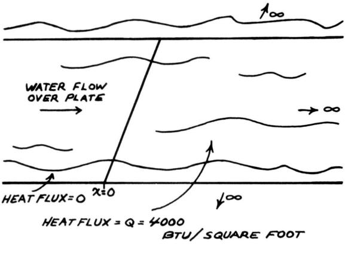

无论如何，什么会给你均匀的热通量？如果热通量均匀，为什么温度不均匀？啊啊啊，正如比尔猫会说的那样。

What would give you uniform heat flux anyway? If the heat flux is uniform, why isn't the temperature uniform? Ack-ack, as Bill the Cat would say.

步骤2.在书中寻找类似的示例问题。没有一个可以接近。

Step 2. Look for similar sample problem in book. There isn't one that's even close.

步骤 3. 浏览同事书架上的四本不同的传热书籍。罗森诺昨天表示，我们可以测试任何我们想要的书。“唯一不能带的东西，”他眨了眨眼睛说，“就是顾问。” 它们里面也什么也没有。

Step 3. Look through four different heat transfer books on office mate's shelf. Rohsenow said yesterday that we could bring to the test any book we wanted to. "The only thing you can't bring," he said with a wink, "is a consultant." There's nothing in them, either.

步骤 4. 查看课堂笔记，然后查看同事前一年讲座的课堂笔记。又是一个死胡同。

Step 4. Look through class notes, then office mate's class notes from previous year's lecture. Another dead end.

第 5 步：思考问题中发生了什么。请参阅图片。重新绘制图片。

Step 5. Think about what's going on in the problem. Refer to the picture. Redraw the picture.

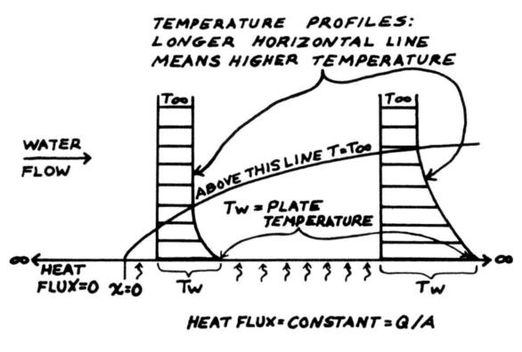

也许两个无穷大的目的是简化问题，这样您就不必担心边缘发生的情况。这将使问题能够得到解决，就好像事物仅在两个方向上（即在一个平面上）变化一样。

Maybe the point of the two infinities is to simplify the problem so you don't have to worry about what happens at edges. This will enable the problem to be solved as if things vary in two directions only, i.e., in a plane.

我仍然想知道什么会产生均匀的热通量以及为什么它很重要。然后我在《马特环球报》的头版上看到了有关西布鲁克核电站的文章。板下方的原子分裂可能看起来是均匀的热流。

I still wondered what would produce a uniform heat flux and why it mattered. Then I saw the article about the Seabrook nuclear plant on the front page of Matt's Globe. Atoms splitting underneath the plate might appear to be a uniform heat flow.

水或其他冷却剂必须流过板的顶部。否则，无论用什么材料制成的盘子都会熔化。中国综合症第二课五十五。

Water or some other coolant would have to flow over the top of the plate. Otherwise the plate, no matter what it was made of, would melt. The China syndrome in class Two fifty-five.

如果水从左边流来，而盘子真的很热，比水还热，那么盘子左端的水将是最冷的，离盘子越远，水就越热。 。水越热，对盘子的冷却作用就越小。因此，当你向下游移动时，盘子会变得更热。

If the water is coming from the left, and the plate is really really hot, hotter than the water, then the water will be coolest at the left end of the plate, and more of it will get hotter farther and farther away from the plate. The hotter the water is, the less it can cool the plate. Ergo, the plate gets hotter as you go downstream.

他们在核工厂必须采取的技巧是确保板材不会太长，以免其温度超过其材料的熔点。谁会想吃沙滩球那么大的西红柿呢？

The trick they have to get right at the nuke plant is to make sure the plate isn't so long that its temperature goes above the melting point of what it's made of. Who would want to eat a tomato as big as a beach ball?

可是等等。罗森现在就是他们。如果我能弄清楚如何解决这个问题，我就是他们。

But wait. Rohsenow is they. If I can figure out how to do this problem, I am they.

当我开始设置配方时，看门人艾迪敲了门，进来清空废纸篓。艾迪与尼凯斯先生有着惊人的相似之处，尼凯斯先生是我在比利时传热实验室完成实验部分内容的技术人员。这看起来有点像《绿野仙踪》中稻草人、胆小的狮子和铁皮人与埃姆阿姨的农场工人的相似之处。艾迪出生于西西里岛。

As I started setting up the formula, Eddy the janitor knocked on the door and came in to empty the wastebasket. Eddy had an uncanny resemblance to Monsieur Nicaise, the technician who built parts of my experiment in the heat transfer lab in Belgium. It seemed a little like the resemblance that the Scarecrow, the Cowardly Lion, and the Tin Man had to Aunty Em's farmhands in The Wizard of Oz. Eddy was born in Sicily.

“怎么样，Peppy？你来得有点晚了，不是吗？” 我的名字听起来像意大利语的 Peppy。

"How's it going, Peppy? You're here kind of late, aren't you?" My name sounds like Peppy in Italian.

“现在才十一点。夜色还早。”我说。“明天我将进行第一次测试，我想尽可能做好准备。”

"It's only eleven. The night is young," I said. "I've got my first test tomorrow and I want to be as prepared as possible."

他回答说：“不要太专注于你的工作。偶尔找点乐子。有些研究生只工作了五年——然后也许到最后他们的实验不起作用，他们就拿不到硕士学位了。”或者博士。他们一定觉得自己浪费了这些年，没有什么可以活下去的了。我的一些清洁工同事发现这些学生挂在他们应该清理的办公室的管道上。这毁了他们的轮班……别让它发生在你身上。”

He answered, "Don't get too wrapped up in your work. Have some fun sometimes. Some of these graduate students just work for five years-then maybe at the end their experiment doesn't work and they don't get their master's or Ph.D. They must feel like they wasted all those years and there's nothing left to live for. Some of my janitor colleagues have found these students hanging from the pipe in the offices they're supposed to clean up. It ruins their shift. Don't let it happen to you."

这是真的。我从认识的人那里听说过麻省理工学院的自杀问题，但我把这些知识抛到一边并忘记了。我想知道我认识谁，或者还不认识谁，谁可能无法生存。或者无论是我。

It's true. I'd heard about MIT's suicide problem from people who knew people who went here, but I'd shoved the knowledge aside and forgotten about it. I wondered who I knew, or didn't yet know, who might not survive. Or whether it was me.

“我会尽力正确看待事情，”我向他保证。“你知道周围有没有沙发的办公室吗？我不想浪费今晚骑自行车回家和明天早上回来的时间。”

"I'll try to keep things in perspective," I assured him. "Do you know of any offices around that have couches in them? I don't want to waste the time it'll take to ride my bike home tonight and back in tomorrow morning."

“当然可以。走廊那头就有一家。到 5 号楼找我就行了。”

"Sure. There's one just down the hall. Just find me in Building 5."

“好吧。现在我想换换环境。我要去学生中心图书馆呆几个小时，”我说。

"OK. For now I want a change of scenery. I'm going to the student center library for a couple of hours," I said.

学生中心图书馆全天二十四小时开放。它在学生中心五楼。桌子是棕色饰面的；椅子是Naugahyde的。这是电动工具在半夜去的地方。这也是一些麻省理工学院学生居住的地方。一些小壁龛非常黑暗，在椅子下面或某个地方的小隔间里，他们放着牙刷和剃须刀。至少那些刷牙和刮胡子的人会这样做。在这里睡觉的技巧是将两张躺椅相对放置，靠在其中一张的手臂上，双腿放在另一张的座位上。

The student center library is open twenty-four hours a day. It's on the fifth floor of the student center. The tables are brown veneer; the chairs are Naugahyde. This is where the power tools go in the middle of the night. It is also where some MIT students live. Some little alcoves are pretty dark, and underneath the chairs or in a cubbyhole somewhere they keep their toothbrushes and razors. At least the ones who brush their teeth and shave do. The trick to sleeping here is to put two of the lounge chairs across from each other and lean on the arm of one with your legs on the seat of the other.

学生中心图书馆在五楼，但看不到操场。有窗户，但面向混凝土人行道和外墙。这是为了防止你在连续第八个通宵后将其中一把诺加海德椅子从窗户扔出去并跟随它。

The student center library is on the fifth floor, but there isn't a view of the playing fields. There are windows, but they look onto a concrete sidewalk and exterior wall. This is to prevent you from lobbing one of the Naugahyde chairs through the window and following it after your eighth consecutive all-nighter.

我发现桌子旁有一张空椅子，对面是一位东方学生，他正在读一本名为《半导体物理》的教科书。他以半随机的节奏用脚敲击椅腿，每秒一两次。与此同时，他像指挥棒一样转动笔，从小指到拇指，每敲击十英尺就转回来。

I found an empty chair at a table across from an Oriental student who was reading a textbook entitled Semiconductor Physics. He tapped his foot on the chair leg in a semirandom rhythm, once or twice a second. At the same time he twirled his pen like a baton from his little finger to his thumb and back again every ten foot taps.

It made it difficult to concentrate. "Excuse me, would you mind stopping that?" I asked him.

“阻止什么？”

"Stopping what?"

“没关系。” 我到另一张桌子学习到1点30分。当我意识到我已经看了一张罗森诺的讲义十五分钟时，我知道是时候停下来了。看着它，就好像它是一张对我来说毫无意义的中文文字，只是纸上的标记。我睁着眼睛睡着了。

"Never mind." I went to another table and studied until 1:30. I knew it was time to stop when I realized I had been looking at one sheet of Rohsenow's lecture notes for fifteen minutes. Looking at it as if it were a sheet of Chinese writing that meant nothing to me, just marks on a page. I was asleep with my eyes open.

凌晨 2:00

2:00 A. M.

我问另一位看门人是否见过艾迪。

I asked another janitor whether he'd seen Eddy.

“他正在吃午饭。” 我猜如果您从 10:00 到 6:30 轮班，那么凌晨 2:00 就是午餐时间。我走向办公室，发现艾迪从大厅壁橱里拿出拖把和擦洗桶。他打开了办公室的门，里面摆着早期的美国沙发。我从门内侧的钩子上取下两件实验室夹克，用它们作为午睡的毯子。

"He's at lunch." I guess if you work the 10:00 to 6:30 shift, 2:00 A.M. would be lunchtime. I went toward my office and found Eddy pulling a mop and scrub bucket out of the hall closet. He opened the door to the office with the early American couch. I took two lab jackets off the hook on the inside of the door and used them as blankets for my nap.

6点15分，艾迪再次敲门。“在这里，Peppy，我给你做了一杯卡布奇诺。就像我妈妈做的那样。一点浓缩咖啡，大量的糖和牛奶。现在你重新开始学习，并在考试中取得好成绩。”

At 6:15 Eddy knocked on the door again. "Here, Peppy, I made you a cappucino. Just like my mama makes. A little espresso and a lot of sugar and milk. Now you get going again in your studying and do well on that test."

下午 2:00，测试在教室开始，我们 20 个人用椅子扶手上的小办公桌写蓝皮书。Rohsenow 正在参加 Dynatech 董事会议，Jamie 离开房间进行大部分测试。专业人士不作弊。问题 1 出奇地简单，只花了二十分钟。问题 2 有点像我昨晚做的，所以至少我有一些东西可以写在纸上。还没有被鱼雷击中，我的头还在水面上。

At 2:00 P.M. the test began in the classroom with the twenty of us using our little deskettes from the chair arms to write in our bluebooks. Rohsenow was at a Dynatech directors' meeting and Jamie left the room for most of the test. Professionals do not cheat. Problem 1 was surprisingly easy and took twenty minutes. Problem 2 was a little like the one I'd done last night, so at least I had something to put on the paper. Not yet torpedoed, my head was still above water.

10 月 9 日晚上 8:00

8:00 P.m. October 9

又是一个周五晚上，我却没有找到任何人。我没有钱，因为我没有得到报酬。

Another Friday night and I don't got nobody. Ain't got no money 'cause I don't get paid.

外面越来越冷了。带内置烟灰缸的装饰台灯温暖了我的脸和手。唯一的一盏灯，在桌子深绿色记事本上的写字板上发出一滩柔和的光。上面的荧光灯嗡嗡作响。

It was getting colder outside. The deco desk lamp with builtin ashtray warmed my face and my hands. The only lamp, it made a pool of soft light on the writing tablet on the desk's dark green blotter. The fluorescent light above buzzed too much.

“1981 年 10 月 9 日，星期五

"Friday, October 9, 1981

亲爱的斯蒂芬妮，

Dear Stephanie,

。。。如您所知，我的父亲现已七十多岁了，身体出现了一些问题。也许我问你的部分原因是为了取悦他，在他还和我们在一起的时候结婚。我不想伤害你。我希望有一天你能在心里原谅我......

. . . As you know, my father, now over seventy, has had some health problems. Maybe part of why I asked you was to please him, to be married while he was still with us. I didn't want to hurt you. I hope you will someday find it in your heart to forgive me.... ..

“咚”的一声，7号楼大厅的信箱里回响着。飞行，飞往布鲁塞尔。

Thunk, echoed the mailbox in the Building 7 lobby. Par avion, to Brussels.

# 章节

# C H A P T E R

# 4

# 4

# 期中考试

# Midterm

哥伦布日天气晴朗，风和日丽，阳光明媚，查尔斯号上停满了帆船。吉姆·斯图尔特 (Jim Stuart) 和我在纪念大道 (Memorial Drive) 中间观看了她们的比赛，同时等待 10,000 名女性在邦妮·贝尔 (Bonnie Belle) 比赛中通过。

Columbus Day was clear, windy, and warm with Indian summer sun, and the Charles was full of sailboats. Jim Stuart and I watched them from the middle of Memorial Drive while we waited for the 10,000 women to pass in the Bonnie Belle race.

他们以各种速度过去。他们每一个人都是脱离美国的思想家。

They passed at all speeds. They were American-free thinkers, every one of them.

10 月 15 日，星期四

Thursday, October 15

在吉夫托普洛斯的课堂上，我坐在第三排玛丽·帕特森旁边。她穿着褪色牛仔裤和前面印有骷髅头的黑色T恤。头骨上有美国国旗的星条旗，下面用大字写着“运动死亡”。牙齿的形状隐约像字母，上面写着“只有生命才能杀死你”。

I sat next to Mary Patterson in the third row in Gyftopoulos's class. She wore faded jeans and a black T-shirt with a skull on the front. The skull had the stars and stripes of the American flag on it and "Sport Death" written in big letters beneath. The teeth were shaped faintly like letters, and they spelled "Only life can kill you."

“这件 T 恤很有趣，”我说。“你从哪里得到的？”

"That's an interesting T-shirt," I said. "Where'd you get it?"

“我本科生在高级宿舍。这是宿舍标志。”

"I was in Senior House as an undergrad. This is the dorm logo."

“有一场比赛并且获胜了吗？”

"Was there a contest and that won?"

“我不知道完整的历史，”她说。“我认为有人从亨特·汤普森的某本书的封面上偷走了头骨。至于‘运动死亡’，我不知道是否有人知道它是从哪里开始的。”

"I don't know the full history," she said. "I think somebody swiped the skull off the cover of some book by Hunter Thompson. As for the 'Sport Death,' I don't know if anyone knows where that started."

“Senior House 听起来是个有趣的地方。你去了麻省理工学院吗？我问她。

"Senior House sounds like a fun place. Did you go to MIT?I asked her.

“是的，我78年毕业。过去三年我一直在Dynatech工作。但似乎如果我想成为研发领域的大人物，我至少需要硕士学位，最好是博士学位。否则我可能会因为喝咖啡而陷入困境。”

"Yeah, I graduated in '78. I've worked at Dynatech for the past three years. But it seemed that if I wanted to be a big wheel in research and development I needed at least a master's and preferably a Ph.D. Otherwise I could get stuck running coffee."

我问她如何喜欢 Dynatech。

I asked her how she liked Dynatech.

她回答说：“这真的很好。他们为所有工程师提供私人办公室——好吧，没有一个有窗户，但这比我的一些在航空航天领域找到工作的朋友在‘猪圈’里工作要好。而且工作是十分有趣。”

She answered, "It's really good. They give all the engineers private offices-well, okay, none of them has windows but it's better than the 'pigpens' that some of my friends who got jobs in aerospace work in. And the work is really interesting."

“猪圈是什么？”

"What's a pigpen?"

“那些在一排排办公桌的大型开放式办公室里工作的工程师就是这么称呼他们的。那里没有隐私，而且真的很难集中注意力。那里的诀窍是足够闪亮，这样你就可以找到一间带门的室外办公室。 ，“ 她说。

"That's what the engineers who work in those big open offices with rows and rows of desks call them. There's no privacy, and it's really hard to concentrate. The trick there is to shine enough so you get one of the outside offices with a door," she said.

我还没有从事过真正的工作，所以这是一个令人不安的消息。

I hadn't yet worked in a real job, so this was disturbing news.

我对她说：“我想知道现在转学到法学院是否太晚了。” 她笑了。“顺便说一句，”我补充道，“我喜欢你的戒指。你从哪里买的？”

I said to her, "I wonder whether it's too late to transfer to law school." She laughed. "By the way," I added, "I like your ring. Where'd you get it?"

“这是我的铜鼠，”她说。这是一枚图章戒指，图章是麻省理工学院的吉祥物海狸。“这提醒了我，现在我回到学校了，我必须把戒指转过来，这样当我握拳时，图章就靠在我的手掌上。”

"This is my brass rat," she said. It was a signet ring, with a beaver, the MIT mascot, as the signet. "That reminds me, now that I'm back in school here, I have to turn the ring around so the signet's against my palm when I make a fist."

“为什么？” 我问。

"Why's that?" I asked.

“当你在这里的时候，海狸把你当作厕所。当你拿到学位后，你就和海狸合二为一了，所以你把圆环转过来，你和海狸就把世界其他地方当作厕所， “ 她说。

"When you're here, the beaver uses you as a toilet. After you get your degree, you're one with the beaver, so you turn the ring around and you and the beaver use the rest of the world as a toilet," she said.

我至少可以看出这个比喻的第一部分的有效性。玛丽和 TPP 的人一样有信心，但她更聪明。在这里四年的本科工作可能会对一个人造成这种影响。她的自信让我有些害怕，但她的眼神里也有温柔。我希望我们能成为朋友。

I could see the validity of at least the first part of the metaphor. Mary had the same confidence that the TPP people had, but she was smarter. Four years of undergrad work here probably does that to a person. Her confidence scared me a little, but there was also a gentleness in her eyes. I hoped we would become friends.

吉夫托普洛斯开始了当天的讲座。到目前为止，演示完全是外国的。他和贝雷塔提出了他们自己的热力学语言，包括“可用能量”、“稳定平衡状态”和“第一类和第二类永动机”等新术语。今天关于麦克斯韦关系的讲座与我在霍普金斯大学听到的类似。

Gyftopoulos started the lecture of the day. Up until now the presentation was completely foreign. He and Beretta had presented their own language of thermodynamics, including new terms like "available energy," "stable equilibrium state," and "perpetual motion machines of the first and second kind." Today the lectureon Maxwell's relations-was similar to one I'd heard at Hopkins.

麦克斯韦关系式是由十九世纪英国物理学家詹姆斯·克拉克·麦克斯韦发明或发现的，他还发明或发现了电场和磁场之间关系的麦克斯韦方程。那些十九世纪的家伙做了一切。在瓦特的发动机、卡诺的理论、克劳修斯的熵之后，麦克斯韦提出了一些关系式，使您能够获取温度、压力和体积等可测量的量，并计算出能量和熵等更抽象量的大小。

Maxwell's relations were invented or discovered by James Clerk Maxwell, the nineteenth-century British physicist who also invented or discovered Maxwell's equation for the relationship between electric and magnetic fields. Those nineteenth-century guys did everything. After Watt's engine, after Carnot's theory, after Clausius's entropy, Maxwell came along with relations that enable you to take measurable quantities like temperature, pressure, and volume and figure out the magnitude of the more abstract quantities, like energy and entropy.

今天的讲座介绍了麦克斯韦关系。它们都是偏导数。例如，由于熵，无论是什么，都是温度和压力的函数，因此熵的非常小的变化可以被认为是温度对熵的影响的微小变化和压力对熵的影响的微小变化的总和。够简单的。但是，当你对能量进行相同的分析时，以及他们称之为焓的另一种东西，当他们在一个半小时内向你射击所有这些时，它很快就变成了汤。你的笔记中有太多的方程式，几乎不可能知道重要的方程式是什么、中间步骤是什么以及它们如何组合在一起。一切都发生得如此之快，仅仅把这些东西写下来就已经够困难的了，更不用说理解任何东西并遵循推理了。

And so today's lecture presented Maxwell's relations. They were all partial derivatives. Since, for example, entropy, whatever that is, is a function of temperature and pressure, a very small change in entropy can be thought of as the sum of a small change in temperature's effect on entropy and a small change in pressure's effect on entropy. Simple enough. But when you then look at the same analysis for energy, and another thing they call enthalpy, and when they shoot all this at you in an hour and a half, it quickly becomes soup. There are so many equations in your notes that it's nearly impossible to know what the important ones are, what the intermediate steps are, and how they all fit together. It all goes so fast and it's hard enough just to write the stuff down, much less comprehend anything and follow the reasoning.

玛丽的笔记非常整洁，就像马特的一样，整洁且有用。她甚至有时间在边缘画一些带叶子的小植物。

Mary's notes were perfectly neat, like Matt's, uncluttered and useful. She even had time to draw little leafed plants in the margins.

讲座结束时，吉夫托普洛斯做了最后的笔记。“我刚才介绍的正是你在物理化学课或热力学物理课上会看到的内容。这是科学知识。但你会发现，在现实世界中，科学知识是最简单的。部分。至少它在逻辑上是一致和不变的。作为工程师，你要做的就是对你正在设计的系统做出假设。做出假设来使你能够生产出既能工作又符合科学原理的东西可能是非常困难的”。

At the end of the lecture, Gyftopoulos made a final note. "What I've just presented is exactly what you will see in a physical chemistry class, or a physics class in thermodynamics. This is scientific knowledge. What you will find, though, in the real world is that the scientific knowledge is the easy part. At least it is logically consistent and invariant. What you will have to do as engineers is make assumptions about the systems you are designing. Making assumptions that enable you to produce something that works while being consistent with the scientific principles can be very difficult."

我想知道他是什么意思。

I wondered what he meant.

“顺便说一句，”他继续说道，“第一次测验将于 10 月 29 日举行，即两周后。”

"By the way," he continued, "the first quiz will be October 29, two weeks from today."

我对玛丽说：“那个日期让我想起了，但我无法确定它，就像它是某个历史事件的日期一样。”

I said to Mary, "That date rings a bell with me, but I can't place it, like it's the date of some historic event."

“试试 1929 年的黑色星期四，股市崩盘。”

"Try Black Thursday 1929, the stock market crash."

“你的记忆力真好。午饭你有做什么吗？” 我问。

"You've got a great memory. Are you doing anything for lunch?" I asked.

“我正在检查我的车。”她用不拒绝的语气回答道。“也许改天吧。”

"I'm getting my car inspected," she replied in a nonrejecting tone. "Maybe some other time."

周五下午我去参加了流体教程。这是由来自黎巴嫩的 Kamel Gemayel 在 1 号楼二楼进行的。在教程中，您会提出有关如何做题的问题。这也是你让教授看起来很愚蠢的机会，这是公平的，因为他们有很多机会让你看起来很愚蠢。不过，杰马耶勒是个好人，所以没人想让他看起来很愚蠢。

Friday afternoon I went to the fluids tutorial. This was conducted on the second floor of Building 1, by Kamel Gemayel, from Lebanon. At a tutorial, you ask questions about how to do problems. It's also your chance to make the professor look stupid, which is only fair since they have so many chances to make you look stupid. Gemayel was a nice guy, though, so nobody wanted to make him look stupid.

1 号楼毗邻纪念大道，从教室的窗户可以直接看到大道两侧树木的叶子高度。透过窗户，那是一个蓝天的下午，树叶金灿灿的，风吹在查尔斯河上，和周一一样，只是凉爽一些。秋天已经来临，几乎没有机会迎来更温暖的天气。海浪让我回想起划独木舟的日子。

Building 1 adjoins Memorial Drive and the classroom's window looked right onto leaf level of the trees along each side of the drive. It was a blue sky afternoon through the window and the leaves were brilliantly golden and the wind blew on the Charles as it had on Monday, only cooler. Fall was fully with us, with little chance for more warm weather. The waves made me think back to my canoe-tripping days.

Gemayel 提出了问题 C-32。油和水位于两个板块之间，水波沿着板块的长度向下移动。自然地，盘子是无限长的。该问题要求您将波速与油和水的密度以及波的高度联系起来。他从笔记中推导出了解决方案。这不是湖面上的波浪，但它是一个开始。

Gemayel presented problem C-32. Oil and water were between two plates, and a wave of the water moved down the length of the plates. Naturally the plates were infinitely long. The problem asked you to relate the wave speed to the density of the oil and the water and the height of the wave. He went through the derivation of the solution from his notes. It wasn't a wave on a lake, but it was a start.

我旁边的利比亚核工程学生让杰马耶勒做C-33题；它要求我们计算给定尺寸的船舶在给定尺寸的波浪中的振荡频率。这是今年新增的一个新问题，因此杰马耶勒没有书面解决方案。事实上，他以前从未考虑过这个问题。

The Libyan nuclear engineering student next to me asked Gemayel to do problem C-33; it asked us to calculate the frequency of oscillation of a ship of a given size in waves of given sizes. This was a new problem, added this year, so Gemayel didn't have a written solution. In fact, he'd never looked at the problem before.

他支支吾吾，哽咽了五分钟，转了几圈，最后说道：“这里有人做过这道题吗？” 坐在我前面的韩国人站起来写下了答案。

He hemmed and he hawwed for five minutes, going around in some circles, and then he finally said, "Did anyone here do this problem?" The Korean sitting in front of me got up and wrote the solution.

看到教授不是无所不知是令人欣慰的，但同样令人不安的是，看到那个位于我的钟形曲线上的韩国人比教授更聪明。

It was comforting to see that a professor wasn't omniscient, but it was equally discomforting to see that the Korean, who would be on my bell curve, was smarter than the professor.

罗森诺让我们等到课后才交回传热测试。他做的第一件事是画出钟形曲线，用一条从 0 到 20 的数轴。他在说话之前画了 x：一个 x 在 7 处，两个 x 在 9 处，四个 x 在 10 处，无一个在 11 处，两个在 12 处，四个 x 13岁的时候有6个，14岁的时候有6个，还有8个在15岁到20岁之间。

Rohsenow made us wait until after the class to hand back the heat transfer tests. The first thing he did was draw the bell curve, with a number line from 0 to 20. He drew the x's before he spoke: One x at 7, two at 9, four at 10, none at 11, two at 12, four at 13, six at 14, and another eight between 15 and 20.

“数据结果几乎符合杰米和我的预期，”罗森诺说。“现在，如果你在这里，或者在右边，那很好，”他指着 14 号说道。“如果你在左边，那么也许你应该再做一些题，或者考虑放弃。”

"The data came out pretty much the way Jamie and I expected," Rohsenow said. "Now if you're here, or to the right, that's good," he said, pointing to the 14. "If you're to the left of here, well maybe you should do some more problems or think about dropping."

好不容易借来的 3,400 美元用于学费，放弃课程是不可能的。

With 3,400 hard-borrowed dollars invested in tuition, dropping a course is not an option.

蓝色的书都放在前面的桌子上。讲座结束后，我们推到桌子旁，依次在一堆东西中翻找自己的。

The blue books were all sitting on the front table. After the lecture we pushed to the table, rummaging through the pile in turn to find our own.

我希望成绩不会出现在封面上，但事实确实如此。我的成绩是 14 岁——我的成绩是班级平均分。我记得小学时成绩的口头版本：“A，优秀，B，良好，C，一般，D，较差。” 当我很聪明的时候，平均水平总是被认为是一件坏事。但看到这里我才松了一口气。平均值 B.

I hoped the grades weren't put on the front cover, but they were. Mine was 14-I made class average. I remembered in elementary school the verbal version of grades: "A, excellent, B, good, C, average, D, poor." Average had always seemed a bad thing back when I was smart. But here I just breathed a big sigh of relief. Average meant B.

我在走出教室的路上遇见了玛丽。她在办公室门口，向一名正在参加《两点二十》（本科版流体课程）的本科生说鼓励的话。玛丽拥有助教职位，这意味着她会对习题进行评分，并帮助学生解决他们可能遇到的任何问题。和任何优秀的助教一样，她的教学工作比教授还要多。她并没有因为学生不理解而痛斥他们。而且她的办公室里几乎总是有人，所以她一定知道她的事情。

I bumped into Mary on the way out of the class. She was at the door of her office, offering words of encouragement to an undergrad who was taking two twenty, the undergrad version of Fluids. Mary had a teaching assistantship, which meant she graded problem sets and helped the students with any questions they might have. She, like any good TA, did more teaching than the professors. She did not bite her students' heads off for not understanding. And there was almost always someone at her office, so she must have known her stuff.

“你的车通过年检了吗？” 我问。

"Did your car pass the inspection?" I asked.

“当然有。对于一辆 77 年的雪佛兰来说，这还不错。我什至不需要投入任何钱。我正要去参加星期五晚上的啤酒狂欢。愿意一起去吗？”

"Sure did. Not bad for a '77 Chevette. I didn't even have to pour any money into it. I'm about to go down to the Friday night beer blast. Care to come along?"

“这听起来很有趣。” 我们下楼来到米基奇办公室和夏洛特·埃文斯办公室之间的休息室。这个区域挤满了人：白发教授围成一圈互相交谈，研究生围成一圈互相交谈，并与他们的导师、助理教授交谈。偶尔还有本科生。气氛很紧张，但很友好。

"That sounds like fun." We went downstairs to the lounge between Mikic's office and Charlotte Evans's office. The area was packed with people: circles of gray-haired professors talking to one another, circles of graduate students talking to one another and to their advisers, the assistant professors. And there was the occasional undergraduate. The atmosphere was wired, but in a friendly way.

“嘿，足球明星，”卡洛斯对我说。

"Hey, soccer star," Carlos said to me.

“莫伊？”

"Moi?"

“是啊，你。怎么样？”

"Yeah, you. How's it going?"

“好的，谢谢。你呢？”

"Fine, thanks. How about you?"

“很好。请问，你见过吉姆·斯图尔特吗？他参加了技术政策项目，”当吉姆向我们走来时，卡洛斯说道。

"Good. Say, you met Jim Stuart? He's in that Technology Policy program," Carlos said as Jim walked up to us.

“他当然有，”吉姆说。“每个人都认识佩珀。”

"Of course he has," Jim said. "Everyone knows Pepper."

米基奇教授走到玛丽身边，轻轻拍拍她的肩膀。“很高兴见到你回到这里，”他说。

Professor Mikic walked up to Mary and gave her a light pat on the shoulder. "It's good to see you back here," he said.

他看着我说：“我是玛丽的导师。她是我最引以为豪的学生之一。你最近怎么样？”

He looked at me and said, "I am Mary's mentor. She has been one of the students I am most proud of. And how are things going with you?"

“无论如何，到目前为止我还活着，”玛丽说。

"I'm surviving, so far anyway," Mary said.

我们又寒暄了一番，然后走向茶点桌。玛丽指着一个金发、留着小胡子的家伙。“那是彼得·胡贝尔。他和我一样，也是一年级学生。他二十三岁时获得了博士学位，现在是一名助理教授，全职就读于哈佛法学院。我听说他已经收到了最高法院奥康纳法官书记员的邀请。”

We exchanged further pleasantries and headed for the refreshment table. Mary pointed out a blond-haired guy with a mustache. "That's Peter Huber. He started here as a freshman the same time I did. He had his Ph.D. by the time he was twenty-three, and he's now an assistant professor and he goes to Harvard Law School full time. I hear he's already gotten an offer to clerk for Justice O'Connor in the Supreme Court."

“好吧，但是他的高尔夫球打得怎么样？”

"OK, but how's his golf game?"

“他不打高尔夫球。我不认为他打球，就这样。我不知道有谁比他更专注和更有指导性。”

"He doesn't play golf. I don't think he plays, period. I don't know anybody more focused and directed than he."

“那边那个正在和夏皮罗说话的白发留胡子的家伙是谁？” 我问。

"Who's the white-haired guy over there with the beard, talking to Shapiro?" I asked.

“那是‘汉克大公’佩恩特。他是居民控制天才。当他在港口处理厂进行紧急咨询时，他阻止了波士顿所有下水道的堵塞。管道破裂或阀门卡住了， “整个地方都失去了控制。他拿出一台自己开发的便携式计算机，在上面模拟了系统，告诉他们要打开哪些阀门，要关闭哪些阀门，以及要多快打开。”

"That's 'Maharajah Hank' Paynter. He's the resident controls genius. He kept all the sewers in Boston from backing up once when he did some emergency consulting at the treatment plant in the harbor. A pipe had broken or a valve had stuck and the whole place was out of control. He took out a portable computer he'd developed and simulated the system on it and told them what valves to open, what valves to close, and how fast to do it."

我们混在一起，直到人群开始稀疏，我问她是否有晚餐计划。

We mingled until the crowd started to thin out, and I asked her whether she had plans for dinner.

“不，”她说。“你想去查克河上游怎么样？”

"No," she said. "How'd you like to go up Chuck River?"

“打扰一下？”

"Excuse me?"

“你知道，沿着查尔斯河与哈维家族交往。我们可以去潘普洛纳咖啡馆，点一杯浓缩咖啡，谈论笛卡尔和萨特。”

"You know, up the Charles to rub elbows with the Harveys. We can go to Cafe Pamplona, order espresso, and talk about Descartes and Sartre."

“当然，”我说，然后我们走向她的车。我又问了她更多问题。“我可以解释过去 Dynatech 和 MIT 之间的七年。你在哪里长大？”

"Sure," I said, and we walked to her car. I asked her more questions. "I can account for the past seven years between Dynatech and MIT. Where'd you grow up?"

“我在城市北部的多布斯费里 (Dobbs Ferry) 读了高中和大部分小学。我的父母对苏联非常兴奋，所以我在那里读了一年级和二年级。”

"I went to high school and most of elementary school in Dobbs Ferry, north of the City. My parents were really excited about the Soviet Union, so I went to first and second grade there."

“太棒了，”我说。“你知道吗，这意味着当我吃我母亲藏在乒乓球桌下的好时巧克力棒时你正在俄罗斯，那张乒乓球桌将成为我家的避难所？那是什么样子的？” 我问。

"Amazing," I said. "Do you realize that means you were in Russia when I ate the Hershey bars that my mother had hidden under the ping-pong table that was going to be my family's fallout shelter? What was it like?" I asked.

“这没什么大不了的，真的；我的意思是我没有太多可以比较的东西。不过，这对我的俄语来说很棒；我会告诉你这么多。”

"It was no big deal, really; I mean I didn't have much to compare it with. It was great for my Russian, though; I'll tell you that much."

她那辆蓝色的 77 款雪维特乘客侧的车门无法从外面打开，所以她必须伸手让我进去。

The door on the passenger side of her blue '77 Chevette didn't open from the outside, so she had to reach over to let me in.

“他们不再像以前那样制作它们了，”她说。

"They don't make 'em like they used to," she said.

“是的，那是因为底特律有太多商学院的笨蛋在经营事情。那些人将成为我们的老板，这真的很烦人，而他们什么都不知道。”

"Yeah, that's 'cause there's too many B-school bozos running things in Detroit. It's really annoying that those people are going to be our bosses, and they don't know anything."

“是的，我知道你的意思，”她说。“但也许有一天我们会获得一些力量并能够改变事情。”

"Yeah, I know what you mean," she said. "But maybe we'll get some power some day and be able to change things."

我们驱车前往哈佛广场，沿着马萨诸塞大街穿过中央广场，经过杰克夜总会和奥森威尔斯剧院。我们更多地谈论了俄罗斯、华尔街、吉夫托普洛斯和他在萨德伯里的家。玛丽的声音里有时带着讽刺的语气，仿佛她的聪明才智是一种负担——一种负担，因为她不能被愚弄。

We drove to Harvard Square, up Mass. Ave through Central Square, past Jack's Nightclub and the Orson Wells theater. We talked more about Russia, Wall Street, Gyftopoulos, and his home in Sudbury. At times there was a tone of irony in Mary's voice, as if her intelligence were a burden-a burden because she couldn't be fooled.

“啊，一个停车位。”她高兴地说。“距离广场只有三个街区。”

"Ah, a parking space," she said gleefully. "And only three blocks from the square."

“你知道，我父亲在那里读了大学和法学院，”我指着街对面那栋长满常春藤的砖砌大建筑说道。“还记得《论文追逐》中的那个人，他是哈佛和哈佛法学院的第四代人吗？我本来就是第三代。”

"You know, my father went there for both college and law school," I said, pointing across the street at the big old brick building with ivy growing up the side. "Remember that guy in The Paper Chase, the one who was fourth-generation Harvard and Harvard Law? I would have been third generation."

“那你为什么不去那里呢？” 当我们向左走到弓街时，她问道。

"So why didn't you go there?" she asked as we walked left onto Bow Street.

“因为我的基因，我不想进入那里。我想去一个更注重成绩的地方。此外，你看看哈佛，它是工业的果实。麻省理工学院就是工业。你知道有趣的事情；我认为我父亲同意我的观点。”

"I didn't want to get in there because of my genes. I wanted to go somewhere that was more merit-oriented. Besides, you look at Harvard, it's the fruit of industry. MIT is industry. And you know the funny thing; I think my father agrees with me."

“好吧，你对麻省理工学院的看法是对的。这里就是咖啡馆。”

"Well, you're right about MIT. Here's the cafe."

这是楼下的一个小房间，比我的卧室大不了多少。我们坐在一张小圆桌旁。有几顶贝雷帽和粗花呢。咖啡馆的音响里正在播放维瓦尔第的《四季》。

It was a little downstairs room hardly bigger than my bedroom; we sat at one of the small round tables. There were several berets and tweed. Vivaldi's Four Seasons was playing on the cafe stereo.

“夏天，”玛丽说。

"Summer," Mary said.

“打扰一下？” 我说。

"Excuse me?" I said.

“这就是现在的季节。你可以看出来，因为这是最乐观的季节。”

"That's which season this is. You can tell because it's the most upbeat."

“哎呀，我认为我做得很好，认识到这是四个季节之一，”我回答道。

"Gee, and I thought I was doing well to recognize it was one of the Four Seasons," I answered.

我们点了晚餐，然后继续聊天。“所以给我更多关于吉夫托普洛斯的黑料吧，”我说。“他怎么做得这么好？”

We ordered our dinner and continued to talk. "So give me some more dirt on Gyftopoulos," I said. "How'd he do so well?"

“嗯，他和他的好友 Hatsopoulos 都是上世纪 50 年代这里的研究生。他们完成博士学位后，需要更新的挑战，因此他们开始申请政府资助进行合同研究。他们还为“天然气研究所。因此他们从中获得了合理的现金流，并开始将一些多余的资金投入到产品开发中。一件事导致了另一件事，现在 Thermo 跻身财富 1000 强。”

"Well, he and his buddy Hatsopoulos were both graduate students here back in the '50s. After they finished their Ph.D.s they needed newer challenges, so they started applying for government grants for contract research. They also did a lot of work for the Natural Gas Research Institute. So they developed a reasonable cash flow from that and started investing some of the excess in product development. One thing led to another, and now Thermo's in the Fortune 1000."

“你认为吉夫托普洛斯值多少钱？” 我问。

"How many millions do you think Gyftopoulos is worth?" I asked.

“我不知道。不过他可能已经注定了一生。”

"I don't know. He's probably set for life, though."

“哎呀。我想知道是什么让他坚持下去，”我说。

"Gee. I wonder what keeps him going," I said.

“这些人一旦成功，就不是为了钱，”玛丽说。“然后问题就变成了他们对世界有多大影响力。我认为吉夫托普洛斯真的很喜欢在麻省理工学院教学和工作。成为山中之王之一一定很有趣。”

"These guys aren't in it for the money, once they make it," Mary said. "Then it becomes a matter of how much of an influence they can have in the world. And I think Gyftopoulos genuinely loves teaching and being at MIT. It must be fun to be one of the kings of the mountain."

“是的。他是我们都想成为的那种人，”我说。“我不想转移话题，但你读本科时在这里的社交生活是什么样的？”

"Yeah. He's the kind of guy we all would like to be like," I said. "Not to change the subject, but what was your social life like here when you were an undergrad?"

“嗯，基本上，直到春天第一个温暖的一天，它才不存在。然后当我在图书馆学习时，人们会一个接一个地对我说，‘呃，嗨。呃，你是谁，呃…… ， 阅读？' 同样的事情也发生在我的很多朋友身上。”

"Well, basically it was nonexistent until the first warm day in the spring. Then when I would study in the library, guys would come up to me one after the other and say, 'Uhh, hi. Uhhh, what are you, uhhh, reading?' The same thing happened to a lot of my friends."

“教授们怎么样？他们怎么样？”

"How about the profs? How were they?"

“有些人还不错，有些人就是混蛋。你必须记住，这些人中有很多都是麻省理工学院的——你知道，学士、硕士、博士。他们在高中时在社交方面从未成熟。他们来到这里什么也没做但他们的后半生都在工作。当他们获得终身教职时，他们终于放松了。他们看到像我这样漂亮的年轻女子，他们不知道该怎么办——如果他们对你有任何权力，就像他们你的论文导师，某个时候肯定会出现一些愚蠢的性别歧视评论。三年前，我剪短了头发，试图让自己看起来不那么有吸引力，并避开这些评论，你知道我的一位教授怎么说吗？他说，“哦，玛丽，你看起来很朋克性感。但除此之外一切都很好。”

"Some were okay, others were jerks. You've got to remember that a lot of these guys are MIT cubed-you know, B.S., M.S., Ph.D. They never matured socially in high school. They came here and did nothing but work for the second half of their lives. They finally relax when they've got tenure. They see a nice young woman like me and they don't know what to do-if they have any power over you, like they're your thesis adviser, some stupid sexist comment is bound to come out sometime. Three years ago I cut my hair short to try to look less attractive and ward off the comments and you know what one of my professors said? He said, 'Oh, Mary, you look so punk sexy.' But other than that it was fine."

我们吃完素食，去看《烈火战车》，玛丽开车送我回家。

We finished the vegetarian meal, went to see Chariots of Fire, and Mary drove me home.

“我们去 7-11 吧，”我说。“我去拿一些茶包、牛奶、糖，还有女主人架上的一些东西。”

"Let's drop by the Seven-Eleven," I said. "I'll get some tea bags, milk, and sugar, and something from the Hostess rack."

我们坐在厨房的桌子旁又聊了一些。周五晚上不用一个人度过真是太好了。很高兴知道世界上除了斯蒂芬妮之外还有其他女人。和玛丽谈话很愉快。

We sat at my kitchen table and talked some more. It was good not to spend Friday night by myself. It was good to know that there were other women in the world besides Stephanie. It was good to talk with Mary.

“哦，多漂亮的猫啊，”玛丽说，我室友的猫跳到她的腿上，发出咕噜声。

"Oh, what a nice cat," Mary said as my roommate's cat jumped up onto her lap and purred.

“是啊，有猫在身边真好。”我撒了谎。“它是我室友的。”

"Yeah, it's nice to have the cat around," I lied. "It belongs to my roommate."

“哦，我想水已经准备好了，”玛丽说，水壶开始发出隆隆声。

"Oh, I think the water's ready," Mary said as the kettle started to rumble.

当我把杯子拿到桌子上时，我把一些热水洒在了地板上。

I spilled some hot water on the floor when I brought the cups to the table.

“没问题，”我说。“我用纸巾擦一下就可以了。” 热水在原本脏兮兮的灰色地板上留下了一个白点。“呃，我一直想做一些清洁工作，”我说。

"No problem," I said. "I'll just wipe it up with a paper towel." The hot water left a white spot on the otherwise dirt-gray floor. "Uh, I've been meaning to do some cleaning," I said.

“别担心，”她说，让我摆脱了困境。

"Don't worry about it," she said, letting me off the hook.

她的美丽与她的脸型无关。我们没有亲吻晚安，也没有碰触。她是我的朋友。

She was beautiful in a way that had nothing to do with the layout of her face. We didn't kiss goodnight, didn't touch. She was my friend.

10 月 20 日星期二

Tuesday, October 20

吉夫托普洛斯自己做辅导，贝雷塔坐在小教室的前排，帮助解决吉夫托普洛斯以前没有听过的任何问题。房间最近重新装修过，采用了间接照明，一天结束时感觉几乎像家一样。吉夫托普洛斯穿着他的羊绒毛衣，在我们开始寻求如何做本周习题的提示之前，他尝试了单口喜剧。

Gyftopoulos did his own tutorials, with Beretta sitting in the front row of the small classroom to help with any questions that Gyftopoulos hadn't heard before. The room had recently been redone with indirect lighting, and at the end of the day it felt almost homey. Gyftopoulos wore his cashmere sweater and before we started begging for hints for how to do that week's problem set, he tried his hand at stand-up comedy.

“你知道，我们已经开始谈论化学反应，我们使用符号 nu。嗯，这让我想起了 1954 年我第一次演讲的时候。我很年轻，我不得不承认，我有点紧张。讲了一个半小时，并在黑板上一遍又一遍地写着希腊字母后，其中一个学生说，‘对不起，教授……有什么新鲜事吗？’”

"You know, we've been starting to talk about chemical reaction, for which we use the symbol nu. Well, that reminds me of the time I was giving my first lecture back in 1954. 1 was young and, I have to admit, I was a little nervous. After talking about an hour and a half and writing the Greek letter over and over again on the board, one of the students said, 'Excuse me professor.... What's new?'"

我尽职尽责地笑了。几个人发出嘶嘶声。

I laughed dutifully. Several people hissed.

吉夫托普洛斯随后回答了问题。坐在第二排的穿着军装的家伙快速举起了手，一副僵硬的军人动作。他问了一个关于当天早上分发的习题集的问题，习题集将在两周内到期。

Gyftopoulos then fielded questions. The guy wearing the army uniform who sat in the second row raised his hand quickly, in a rigid military motion. He asked a question about the problem set that had been handed out that morning, due in two weeks.

“我认为我们还不需要考虑这些，”他说。“我们集中讨论下周要交的习题吧。不过，你的急切让我想起了一个小故事。好像有一个中士收到了一份电报，说他的一个士兵的母亲去世了。他不知道如何向那个名叫舒尔茨的士兵提出这个问题。所以他让所有的人都排好队，然后他说：“每个有妈妈的人都站出来。” 当这些人走上前时，他说：“别那么快，舒尔茨。” ”

"I don't think we need to look at those yet," he said. "Let's focus on the problem set that's due next week. Your eagerness, though, reminds me of a little story. It seems that there was a sergeant who received a telegram that one of his soldiers' mother had died. He didn't know how to bring it up to the soldier, whose name happened to be Schultz. So he had all his men line up, and he said, 'Everyone who has a mom step forward.' As the men stepped forward, he said, 'Not so fast, Schultz.' "

大家都嘲笑那个人。

Everyone laughed at that one.

“好了，玩够了。我们回去工作吧，”他说。“还有其他问题吗？”

"Well, enough of the fun and games. Let's get back to work," he said. "Are there any other questions?"

“费瑟亲？” 戴着金丝框眼镜、留着浓密小胡子的家伙说道。

"Pro-Fesser?" the guy with wire-rimmed glasses and a bushy mustache said.

“是的，刘易斯。”

"Yes, Lewis."

“你能复习一下最后一套习题中关于热电联产的问题吗？”

"Could you go over the problem on cogeneration on the last problem set?"

“当然可以。你有问题陈述的副本吗？”

"Certainly. Do you have a copy of the problem statement?"

刘易斯把它从活页夹上取下来。吉夫托普洛斯放下香烟，走到黑板前。坐在我旁边的化学工程师低声说道：“我不了解你，但他抽烟让我感到紧张。我宁愿核工程师更规避风险。”

Lewis unclipped it from his binder. Gyftopoulos put his cigarette down and went to the blackboard. The chemical engineer sitting next to me whispered, "I don't know about you, but it makes me nervous that he smokes. I'd rather that a nuclear engineer was a little more risk-averse."

“至少它们是过滤嘴香烟。”我低声回答道。

"At least they're filter cigarettes," I whispered back.

吉夫托普洛斯开始解释。“如您所知，热电联产是用一台发动机（通常是柴油发动机或燃气轮机）同时产生电力和有用热量。我们想要做的是最大限度地减少燃料的总体使用量以保护环境。我们意识到，必须是含有燃烧产物的烟囱，或者像有些人所说的“污染产物”，但如果我们设计的系统能够满足工业过程或家庭供暖的电力和热能需求，我们就可以最大限度地减少产品顺便说一下，我要向大家强调一点，如果你在未来的职业生涯中涉足能源行业，你会发现可以赚到大量的钱。但是你永远不要忘记这一点作为一名工程师，你不能想到钱，而应该想到如何造福社会。”

Gyftopoulos started his explanation. "As you know, cogeneration is the simultaneous generation of electricity and useful heat with one engine, typically a diesel engine or a gas turbine. What we want to do is to minimize the overall use of fuel to protect the environment. We realize that there have to be smokestacks with products of combustion, or as some would say, 'products of pollution,' but if we design systems with a match between needs for electricity and heat either for industrial processes or for heating of homes, we can minimize the products of pollution. And by the way, let me emphasize one point to you. If in your future careers you become involved in the energy industry, you will see that there is a tremendous amount of money to be made. But you must never forget that as an engineer you must not think of the money, but rather how you can benefit society."

吉夫托普洛斯继续解释问题。在剩下的时间里，其他问题仍在继续。学生们偶尔会讲一些俏皮话，每次离开时都会遭到吉夫托普洛斯的反驳。气氛是融洽的、没有威胁性的、人性化的。

Gyftopoulos continued the explanation of the problem. Other questions continued for the rest of the hour. There were occasional wisecracks from the students, never left without a rebuttal from Gyftopoulos. The atmosphere was collegial, nonthreatening, human.

那天晚上，玛丽、马特、卡洛斯和我在卡洛斯的办公室见面，讨论一些液体问题。马特提出了继续的方法。对于一个给定的问题，我们中的一个人会在黑板上画出问题陈述并开始解决。如果谁遇到了问题，我们其他人就会帮助他或她。“让我们从伯努利方程的一些问题开始，”马特说。“玛丽，你想尝试一下吗？”

That night Mary, Matt, Carlos, and I met in Carlos's office to go over some fluids problems. Matt suggested the way to proceed. For a given problem, one of us would draw the problem statement on the blackboard and start the solution. The rest of us would help whoever was doing the problem if he or she came to a dead end. "Let's start with some of these problems with the Bernoulli equation," Matt said. "Do you want to give one a shot, Mary?"

“当然，”她说。“这是我昨晚研究的一个问题 D-28。它是一个化油器。但首先每个人都理解伯努利方程，对吗？”

"Sure," she said. "Here's one that I worked on last nightproblem D-28. It's a carburetor. But first everyone understands the Bernoulli equation, right?"

马特和卡洛斯点点头，我摇了摇头。“我理解夏皮罗在课堂上所做的推导，伯努利方程如何从纳维-斯托克斯方程中分离出来，但我在物理上并不完全理解它。”

Matt and Carlos nodded and I shook my head. "I understand the derivation Shapiro did in class, how the Bernoulli equation falls out of the Navier-Stokes equations, but I don't fully understand it physically."

“是的，这有点像硬汉，”她说。“想象一下，伯努利坐在佛罗伦萨老桥上他表弟的珠宝店里。他低头看着阿尔诺河，试图弄清楚他为美第奇基金会的下一个研究计划应该放些什么。他看着河中央的两块岩石。河，他注意到水流在它们之间加速。他对资助研究有了一个开创性的想法。“如果我沿着溪流穿过岩石的路径画一条线，然后想象一小管流体沿着这条线流过，那个小管的能量必须沿着这条线保持恒定。知道了？”

"Yeah, it is kind of a toughie," she said. "Just imagine Bernoulli sitting in his cousin's jewelry shop on the Ponte Vecchio in Florence. He's looking down at the Arno trying to figure out what to put in his next research proposal for the Medici Foundation. He's looking at two rocks in the middle of the river, and he notices that the water speeds up between them. He has a seminal idea for fundable research. 'If I draw a line following the path of the stream through the rocks, and then imagine a little tube of fluid going along that line, the energy of that little tube has to be constant along that line.' Got it?"

我上下点头。“我明白了很多，但我还是不明白物理意义。我的意思是，你会认为如果流体加速，它就会有更多的能量，就像汽车开得越快，动能就越大。”我说。

I nodded up and down. "I understand that much, but I still don't have the physical meaning down. I mean, you'd think if the fluid sped up it would have more energy, just like a car has more kinetic energy the faster it goes," I said.

玛丽继续说道：“但是动能必须来自某个地方。它来自于流体静压中储存的能量。这样想：小管子是一个被压缩的小弹簧，里面有一大堆这些小压缩弹簧彼此平行移动。它们穿过岩石的唯一方法就是放松一点。对于这个小弹簧，放松意味着弹簧的前部移开从泉水的后面。所有其他泉水都做同样的事情，水穿过岩石，senza Problema。当压缩弹簧膨胀时，它存储的能量较少。压力能减少的量等于动能或速度能的增加。”

Mary continued, "But the kinetic energy has to come from somewhere. And it comes from the energy stored in the static pressure of the fluid. Think of it like this: the little tube is a little spring that's compressed, and there's a whole bunch of these little compressed springs moving along parallel to each other. The only way they're all going to make it through the rocks is to loosen up a little bit. For this little spring, loosening up means that the front of the spring moves away from the back of the spring. All the other springs do the same thing and the water goes through the rocks, senza problema. When a compressed spring expands, it has less energy stored in it. The amount of decrease in pressure energy is equal to the increase in kinetic or speed energy."

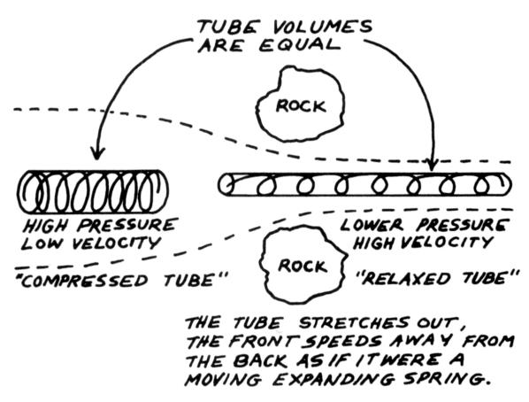

“好吧。我买那个，”我回答道。“但是夏皮罗今天说它只适用于不可压缩流。如果流是不可压缩的，压力怎么会上下呢？”

"OK. I'll buy that," I answered. "But Shapiro said today that it only applied to incompressible flows. If the flow is incompressible, how can the pressure go up and down?"

卡洛斯也加入其中。“不可压缩只是意味着当你施加压力时，体积不会改变。就像你在一些水上施加重量，体积不会改变，但压力会上升。想一想，这就像一个这里的学生。他们给我们施加了很大的压力，但我们的音量没有改变。”

Carlos jumped in on that one. "Incompressible just means that the volume doesn't change when you apply the pressure. It's like if you put a weight on some water, the volume doesn't change but the pressure goes up. Come to think of it, it's like being a student here. They put lots of pressure on us but our volume doesn't change."

如果我们能帮忙的话就不会。

Not if we can help it.

玛丽又回到了问题上。“这是一个化油器，”她重申道。

Mary went back to the problem. "It's a carburetor," she reiterated.

“他们想知道需要多少空气通过多小的管子才能从管子外部的孔中引入指定量的液体。现在，我们不再让水流过阿诺河中的几块岩石，而是“空气通过管子。当其静压降至大气压以下时，它会吸入大气压下的燃料。空气在管子中流动的速度越快，压力就越低，吸入的燃料就越多。”

"They want to know how much air has to go through how small a tube to bring in a specified amount of fluid from the holes around the outside of the tube. Now instead of water going through a couple of rocks in the Arno, we have air going through the tube. When its static pressure goes down below atmospheric, it sucks in fuel that's at atmospheric pressure. The faster the air goes in the tube, the lower the pressure will be, and the more fuel it will pull in."

她继续建立方程并推导出与问题的几何形状相关的燃料流量。我以前看过流体力学，但这里的问题不同。在概念是抽象的之前，这里它们是有形的。夏皮罗课堂上的许多几何图形和问题都是真实的设备。我记得罗森诺告诉我，一位物理学家推导出一种现象的方程，然后说“万岁”，一位工程师从物理学家推导出的方程开始，然后尝试构建一些可行的东西。

She went on to set up the equations and derive the fuel flow rate as related to the geometry of the problem. I had seen fluid mechanics before, but the problems here were different. Before the concepts were abstract-here they were tangible. Many of the geometries and the problems in Shapiro's class were real devices. I remembered Rohsenow's telling me that a physicist derives equations for a phenomenon and says "Hooray," and an engineer starts with the equations the physicist derives and then tries to build something that works.

“好了，”玛丽一边说，一边在黑板底部圈出了答案。“下一个？”

"There," Mary said as she circled the answer on the bottom of the chalkboard. "Next?"

“有人能解释一下为什么茶叶最终会出现在杯子的中央吗？” 我问。“自从我看到花生漫画中薄荷帕蒂问这个问题以来，我就想知道答案。”

"Can someone explain why the tea leaves end up in the center of the cup?" I asked. "Ever since I saw the Peanuts cartoon where Peppermint Patty asks that, I've wanted to know the answer."

“我可以帮忙解决这个问题，”马特说。“这是夏皮罗制作的一部电影中的内容；我在服用本科生液体时看到了它。这就是他们所说的二次流。当你搅拌茶时，液体会绕圈旋转，就像旋转木马上的马一样神秘的是，你可能期望茶叶会因为离心力而跑到茶杯的外面，就像你乘坐快速旋转木马一样。但事实并非如此——它们最终进入了茶杯的内部。中心。让我把它画在黑板上。”

"I can help out on that one," Matt said. "It was in one of those films Shapiro produced; I saw it when I took undergrad fluids. It's what they call a secondary flow. When you stir the tea, the liquid goes around in circles, like horses on a merry-go-round. The mystery is that you might expect the tea leaves to go to the outside of the teacup because of centrifugal force, just like when you're on a fast merry-go-round. But they don't-they end up in the center. Let me draw it on the board."

他画了一个垂直的圆柱体，上面有一个圆形箭头来指示旋转。我想知道我是否会像马特和玛丽一样聪明。让受过麻省理工学院本科教育的人与背景较差的人一起上课似乎几乎不公平。

He drew a vertical cylinder with a circular arrow above it to indicate rotation. I wondered whether I'd ever be as smart as Matt and Mary. It seemed almost unfair to let people with MIT undergrad educations loose in classes with people with lesser backgrounds.

“如果你想象圆柱体中任意高度的一小块流体，有点像旋转木马上的一匹长方形的马，它会受到从靠近中心的一侧推动的压力，并且压力也会推动它从靠近旋转木马外侧的一侧看。外侧的压力必须大于内侧的压力，以平衡大块流体的离心力。在圆柱体的底部，距中心一定距离处的压力与圆柱体顶部的压力相同。但是，由于杯子底部产生的摩擦，茶和茶叶在底部的移动速度也较慢。你知道就像你在旋转木马上一样，你走得越慢，你的离心力就越小。所以，如果你的外部压力仍然大于内部压力，并且离心力较小，你，茶块加上茶叶，会移动到杯子的中心。事实上，有些茶总是在循环，从杯子的中心向上，穿过顶部，向下到侧面，然后沿着杯子回到中心。底端。”

"If you imagine a little chunk of fluid at any height in the cylinder, sort of like a rectangular horse on the merry-go-round, it'll have pressure pushing on it from the side closer to the center and pressure pushing on it from the side closer to the outside of the merry-go-round. The pressure on the outside has to be greater than the pressure on the inside, to balance the centrifugal force of the chunk of fluid. On the bottom of the cylinder, the pressure at a given distance from the center is the same as it is at the top of the cylinder. But the tea and the tea leaves, too, go slower at the bottom because of the friction caused by the bottom of the cup. You know that, just like when you're on the merry-go-round, the slower you go, the less centrifugal force you have. So if you still have more pressure on the outside than on the inside, and less centrifugal force, you, the chunk of tea plus leaves, are going to move to the center of the cup. In fact, some of the tea is always circulating, up the center of the cup, across the top, down the side, and back to the center along the bottom."

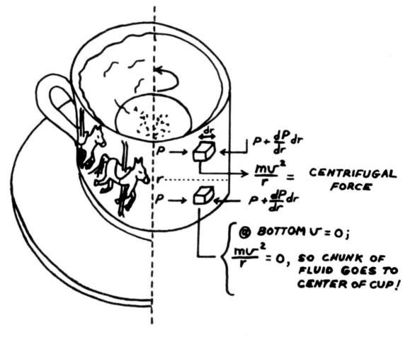

我说：“谢谢。我想我已经明白了。还有其他人想问的问题吗？”

I said, "Thanks. I think I've got it. Anybody else have any questions they want to go over?"

卡洛斯说：“B 部分存在消防水带问题。如果消防水带每分钟向火中水平输送 800 加仑，并且一名消防员可以提供 125 磅的水平力，那么需要多少名消防员才能阻止火灾发生？”消防水龙带像野蛇一样乱窜吗？”

Carlos said, "There's this fire hose problem from section B. 'If a fire hose is delivering 800 gallons per minute to a fire, horizontally, and a fireman can provide a horizontal force of 125 pounds, how many firemen will it take to prevent the fire hose from flailing around like a wild snake?"

“我认为你能解决这个问题，”我说。“这是一个动量定理问题。你只需要计算出消防水龙带中有多少动量以及多快。这等于力。”

"I think you can solve that one," I said. "It's a momentum theorem problem. You just have to figure out how much momentum is going out of the fire hose and how fast. That equals the force."

我写在黑板上。首先，我根据喷嘴的尺寸计算了水离开软管的速度。每秒 100 英尺，或每小时约 70 英里。这是最简单的部分，任何八年级学生都可以做的部分。在日本。下面我计算了每秒有多少磅的水离开软管（大约 100 磅）。

I wrote on the board. First I calculated how fast the water was leaving the hose, on the basis of the size of the nozzle. 100 feet per second, or about 70 miles an hour. That was the easy part, the part that any eighth grader can do. In Japan. Below that I calculated how many pounds of water were leaving the hose each second (about 100 pounds).

然后我将这两个数字转换为公制并将它们相乘。这给了我以牛顿为单位的力，以艾萨克爵士的名字命名。然后我将其换算回英镑，得到答案：2.8 消防员。

Then I converted both numbers to the metric system and multiplied them together. This gave me the force, in newtons, named for Sir Isaac. Then I converted it back to pounds and had the answer-2.8 firemen.

我的同事们对我的解决方案表示赞赏，玛丽补充道，“这让我想起了我的新生导师在我来这里的第一周时所说的话。‘在麻省理工学院接受教育就像从消防水龙带里喝水一样。’” ”

My colleagues applauded my solution, and Mary added, "That reminds me of what my freshman adviser said during my first week here. 'Getting an education at MIT is like getting a drink of water from a fire hose.' "

# 章节

# C H A P T E R

# 5

# 5

# 资金

# Funding

11 月 2 日

November 2

星期一下午三点我进去和汤姆·布莱谈话。汤姆·布莱 (Tom Bligh) 是机械工程系的常驻节能、太阳能和替代能源专家。他原本是英属南非人，后来在明尼苏达大学担任助理教授。在那里，他因地下建筑而闻名（由于地面的隔热性能和稳定的温度，如此设计的建筑需要更少的燃料来加热和冷却）。他还开发了一种系统，可以在冬天制冰，然后在夏天将其融化用于空调。

Monday at three o'clock I went in to talk to Tom Bligh. Tom Bligh was the Mechanical Engineering department's resident energy conservation, solar, and alternative energy guru. Originally a British South African, he'd paid his dues as assistant professor at the University of Minnesota. There he'd made a name for himself in underground buildings (buildings so designed need less fuel to heat and cool because of the insulating value and stable temperature of the ground). He'd also developed a system to make ice in the winter and then melt it in the summer for air-conditioning.

麻省理工学院聘他为副教授；他与能源部有几个正在进行的项目——卡特时代的赠款，当时政府资助了这类事情。

MIT recruited him as an associate professor; he had several ongoing projects with the Department of Energy-grants from the Carter era, when the government funded those kinds of things.

布莱的办公室位于 3 号楼的四楼，与伍迪·弗劳尔斯 (Woodie Flowers) 的办公室隔着走廊，伍迪·弗劳尔斯教授一门名为“事物如何运作”的课程。大厅稍远一点的地方是机器人奇才 Warren Seering，他每月将咨询费提高 10 美元，以减缓业务发展。

Bligh's office was on the fourth floor of Building 3, down the hall from that of Woodie Flowers, who taught a course called "How Things Work." A little farther down the hall was Warren Seering, the robotics whiz who raised his consulting fees by $10 an hour every month in an effort to slow business.

四楼是该部门的设计部门。他们是发明家，是真正有创造力的人。虽然该研究所的许多人一只脚在科学上，另一只脚在工程上，两只手都插在政府的口袋里，但四楼会以每小时数千美元的价格出租给产品开发人员，只是为了互相交流想法。

The fourth floor housed the design section of the department. These were the inventors, the truly creative. While many at the institute had one foot in science, the other in engineering, and two hands in the government's pockets, the fourth floor would rent itself out to product developers for thousands of dollars an hour just to shout ideas back and forth to one another.

布莱办公室旁边的展示柜里放着前一年的学生项目——一个带有自动翻页器的乐谱架。布莱办公室外的候诊室里贴着一张海报，上面写着：“如果你喜欢某样东西，就放手吧。如果它回到你身边，它就是你的。如果没有，它就永远不是你的。” 这是我第一次看到这张海报，所以它对我来说意义重大；这让我想起了斯蒂芬妮。

In the display case next to Bligh's office was a student project from the year before-a music stand with an automatic page turner. In the waiting room outside Bligh's office was a poster that read, "If you love something let it go. If it comes back to you it's yours. If it doesn't it never was." It was the first time I'd seen that poster, so it meant something to me; it reminded me of Stephanie.

“你好，教授，”我说。“我想申请 15,000 美元的林德伯格奖学金，我想知道你是否有兴趣成为我的教员赞助商。一般领域是替代能源，我有一个项目的想法。 ”

"Hello, Professor," I said. "I'd like to apply for a Lindbergh Fellowship for $15,000 and I'd like to know whether you'd be interested in being my faculty sponsor. The general area is alternative energy, and I've got an idea for a project."

“请叫我汤姆，”他说。他的办公室有一个天窗。论文和模型无处不在。他有一头棕色的头发，留着胡须，戴着眼镜，四十岁左右。

"Please, call me Tom," he said. His office had a skylight. Papers and models were everywhere. He had brown hair, a beard, and glasses and was about forty.

他继续说道，“好吧，如果你能接受申请一笔纪念法西斯的拨款，我很乐意帮助你。”

He continued, "Well, if you can stomach applying for a grant in memory of a fascist, I'd be happy to help you."

“为什么他是法西斯分子？” 我问。

"Why was he a fascist?" I asked.

“他在第二次世界大战中非常支持德国，非常反对美国介入。有很多关于这方面的书籍，”他说。

"He was very pro-German in World War II, very much against U.S. involvement. Plenty of books have been written about it," he said.

“我只知道他是一名技术专家和飞行员。这就是我申请这笔拨款时需要考虑的一切。我需要这笔钱。”

"All I know is he was a technologist and aviator. That's all I need to think about when I apply for this grant. I need the money."

“好吧，那你有什么想法吗？” 布莱问道。

"All right, then, what's your idea?" Bligh asked.

“嗯，这是我去年从比利时的一个朋友那里得到的想法。你知道堪萨斯州和内布拉斯加州的冬天会变得非常寒冷和多风吗？为什么不拥有一个风车来直接驱动热泵来为房子供暖呢？”还是谷仓？风越大，风车驱动热泵的电力就越多，因此风的冷却效果将被泵送的热量增加所抵消，”我说。

"Well, it's an idea I got from a friend of mine in Belgium last year. You know how it gets really cold and windy in Kansas and Nebraska in the winter? Why not have a windmill that drives a heat pump directly to heat the house or the barn? The windier it gets, the more power will be available from the windmill to drive the heat pump, so the cooling effect of the wind will be negated by the increased heat that's pumped," I said.

“等一下，我给我的专利律师打电话，”他开玩笑说，然后又恢复严肃。“你能向我解释一下热泵的工作原理吗？”

"Hold on a minute while I call my patent attorney," he joked, then went back to being serious. "Can you explain to me how a heat pump works?"

这是一次友好的质问，所以我如实回答。“不是真的。我所知道的是，这有点像反向空调。在获得资助后我可以弄清楚这一点。”

It was a friendly cross-examination, so I answered honestly. "Not really. All I know is that it's sort of like an air conditioner in reverse. I could figure that out after I get the grant."

“这就是精神，”他讽刺地说，但这也是一个成功的时间管理者的智慧。“我们现在先把一个大纲放在一起，然后你可以在一周左右的时间里带着一个充实的版本回来。你打算调查什么？” 他问。

"That's the spirit," he said with irony, but also the wisdom of a successful time manager. "Let's put an outline together now, then you can come back in a week or so with a fleshed-out version. What do you propose to investigate?" he asked.

“首先，我会将风车视为现成的物品。也许你甚至可以使用他们用来抽水的风车，并将转换套件连接到不同的齿轮机构。然后我会查看功率曲线“风车和热泵在不同温度下的性能曲线，然后我会推荐不同的尺寸匹配策略。最后，我会进行一些经济分析，计算出传统燃油供暖系统的投资回报。”

"First, I'd take the windmill as an off-the-shelf item. Maybe you could even use one they use to pump water and attach a conversion kit to a different gear mechanism. Then I'd look at the power curves for the windmill and the performance curves for the heat pump at different temperatures, and then I'd recommend different size-matching strategies. Finally, I'd put together some economic analysis, figure out the payback over a conventional oilfired heating system."

“这是你的四个部分。一周后见。”

"There are your four sections. See you in a week."

11 月 5 日

November 5

夏洛特·埃文斯的包裹将乔·史密斯列为低温学（研究极冷环境）和热电联产（吉夫托普洛斯问题集中的小型发电厂）方面的专家。我对寒冷没有太多兴趣，但热电联产似乎是防止极地冰盖融化的好方法。

Charlotte Evans's packet listed Joe Smith as a specialist in cryogenics, the study of the very cold, and cogeneration, the small power plants in Gyftopoulos's problem sets. I didn't have much interest in the very cold, but cogeneration seemed to be a great way to keep the polar ice caps from melting.

终身教授乔·史密斯（Joe Smith）的办公室位于高压磁体实验室附近的一侧。他是一名机械工程师，使电气工程师的磁铁保持足够冷以进行超导测试。他的窗户俯瞰着麻省理工学院的蒸汽热电厂。

Joe Smith, tenured professor, had his office off to one side, near the high-voltage magnet laboratory. He, a mechanical engineer, kept the electrical engineers' magnet cold enough to do tests in superconductivity. His window overlooked MIT's steam heat generating plant.

“我能为你做什么，儿子？” 他带着慈父般的口音问道。

"What can I do for you, son?" he asked in a fatherly manner, with a southern accent.

“嗯，我对节能、热电联产、热回收、隔热、太阳能——任何节省能源的东西都很感兴趣。我看到你从事热电联产工作，”我说。

"Well, I'm interested in energy conservation, cogeneration, heat recovery, insulation, solar energy-anything that saves energy. I saw that you do work in cogeneration," I said.

“是的，我愿意，但现在我里面没有钱，”他说，靠在椅子上，双脚放在桌子上，双手抱在脑后。“不过，如果你能自己在该领域筹集一些资金，我很乐意成为你的顾问。” 他让我想起了南方种植园主。

"Yes I do, but right now I don't have any money in it," he said, leaning back in his chair, his feet up on the desk and hands clasped behind his head. "If you can come up with some funding in that area on your own, though, I'd be happy to be your adviser." He reminded me of a southern plantation owner.

“只是一个小建议，儿子，”他补充道。“当你从事能源工作时，假装你正在经营采矿作业。集中精力寻找并从你正在开采的集中区域中提取最多的资源。不要担心从矿渣堆中回收任何东西。你你会花费比你从中得到的更多的时间和精力。”